# Credit_Risk_Modeling Preprocessing

## Data Preparation

### Importing Libraries

```python
import pandas as pd
import numpy as np
import matplotlib.pyplot as plt
import seaborn as sns
```

### Making a copy of the file for backup

> It's a good practice to keep a backup of the dataset you're using.

```python
# the data is a local one and is 1.5 GB in size.
loan_data_backup = pd.read_csv("loan_data_2007_2018.csv")
```

```python
loan_data = loan_data_backup.copy()
```

### Exploring Data

Pandas `df.head() | df.tail()` function will give us an overview of the **top five** and **bottom five** rows respectively.

The number of columns can be huge to get a proper idea, hence we can use the following methods to get a glance of all column elements at once.

> `loan_data.info()`

> `loan_data.columns.values`

```python
loan_data_backup.head()

loan_data_backup.tail()
```

|  | id | member_id | loan_amnt | funded_amnt | funded_amnt_inv | term | int_rate | installment | grade | sub_grade | emp_title | emp_length | home_ownership | annual_inc | verification_status | issue_d | loan_status | pymnt_plan | url | desc | purpose | title | zip_code | addr_state | dti | delinq_2yrs | earliest_cr_line | fico_range_low | fico_range_high | … |
| --- | --- | --- | --- | --- | --- | --- | --- | --- | --- | --- | --- | --- | --- | --- | --- | --- | --- | --- | --- | --- | --- | --- | --- | --- | --- | --- | --- | --- | --- | --- |
| 1048570 | 72663394 | NaN | 14400.0 | 14400.0 | 14400.0 | 36 months | 16.29 | 508.33 | D | D1 | Purchasing manager | 10+ years | RENT | 45000.0 | Not Verified | Feb-16 | Charged Off | n | https://lendingclub.com/browse/loanDetail.acti... | NaN | credit_card | Credit card refinancing | 168xx | PA | 33.76 | 0.0 | Nov-03 | 675.0 | 679.0 | … |
| 1048571 | 72673678 | NaN | 10000.0 | 10000.0 | 10000.0 | 36 months | 11.47 | 329.62 | B | B5 | E6 | 10+ years | MORTGAGE | 135000.0 | Not Verified | Feb-16 | Fully Paid | n | https://lendingclub.com/browse/loanDetail.acti... | NaN | debt_consolidation | Debt consolidation | 985xx | WA | 26.41 | 1.0 | Oct-03 | 665.0 | 669.0 | … |
| 1048572 | 72663353 | NaN | 16000.0 | 16000.0 | 16000.0 | 36 months | 10.75 | 521.93 | B | B4 | Consultant | < 1 year | MORTGAGE | 70000.0 | Source Verified | Feb-16 | Fully Paid | n | https://lendingclub.com/browse/loanDetail.acti... | NaN | debt_consolidation | Debt consolidation | 284xx | NC | 21.67 | 0.0 | May-90 | 710.0 | 714.0 | … |
| 1048573 | 72785737 | NaN | 6000.0 | 6000.0 | 6000.0 | 36 months | 7.89 | 187.72 | A | A5 | Administrative Assistant | 6 years | MORTGAGE | 31500.0 | Source Verified | Feb-16 | Fully Paid | n | https://lendingclub.com/browse/loanDetail.acti... | NaN | debt_consolidation | NaN | 394xx | MS | 25.98 | 0.0 | Mar-89 | 715.0 | 719.0 | … |
| 1048574 | 72573375 | NaN | 1000.0 | 1000.0 | 1000.0 | 36 months | 6.49 | 30.65 | A | A2 | TEACHER | 10+ years | MORTGAGE | 65000.0 | Not Verified | Feb-16 | Fully Paid | n | https://lendingclub.com/browse/loanDetail.acti... | NaN | home_improvement | Home improvement | 147xx | NY | 8.33 | 0.0 | Oct-98 | 755.0 | 759.0 | … |

```python
# doesn't filter the columns and displays them all.

pd.options.display.max_columns = None
```

```python
loan_data.info()

loan_data.columns.values
```

```
<class 'pandas.core.frame.DataFrame'>
RangeIndex: 1048575 entries, 0 to 1048574
Columns: 151 entries, id to settlement_term
dtypes: float64(113), object(38)
memory usage: 1.2+ GB
```

```
array(['id', 'member_id', 'loan_amnt', 'funded_amnt', 'funded_amnt_inv',
       'term', 'int_rate', 'installment', 'grade', 'sub_grade',
       'emp_title', 'emp_length', 'home_ownership', 'annual_inc',
       'verification_status', 'issue_d', 'loan_status', 'pymnt_plan',
       'url', 'desc', 'purpose', 'title', 'zip_code', 'addr_state', 'dti',
       'delinq_2yrs', 'earliest_cr_line', 'fico_range_low',
       'fico_range_high', 'inq_last_6mths', 'mths_since_last_delinq',
       'mths_since_last_record', 'open_acc', 'pub_rec', 'revol_bal',
       'revol_util', 'total_acc', 'initial_list_status', 'out_prncp',
       'out_prncp_inv', 'total_pymnt', 'total_pymnt_inv',
       'total_rec_prncp', 'total_rec_int', 'total_rec_late_fee',
       'recoveries', 'collection_recovery_fee', 'last_pymnt_d',
       'last_pymnt_amnt', 'next_pymnt_d', 'last_credit_pull_d',
       'last_fico_range_high', 'last_fico_range_low',
       'collections_12_mths_ex_med', 'mths_since_last_major_derog',
       'policy_code', 'application_type', 'annual_inc_joint', 'dti_joint',
       'verification_status_joint', 'acc_now_delinq', 'tot_coll_amt',
       'tot_cur_bal', 'open_acc_6m', 'open_act_il', 'open_il_12m',
       'open_il_24m', 'mths_since_rcnt_il', 'total_bal_il', 'il_util',
       'open_rv_12m', 'open_rv_24m', 'max_bal_bc', 'all_util',
       'total_rev_hi_lim', 'inq_fi', 'total_cu_tl', 'inq_last_12m',
       'acc_open_past_24mths', 'avg_cur_bal', 'bc_open_to_buy', 'bc_util',
       'chargeoff_within_12_mths', 'delinq_amnt', 'mo_sin_old_il_acct',
       'mo_sin_old_rev_tl_op', 'mo_sin_rcnt_rev_tl_op', 'mo_sin_rcnt_tl',
       'mort_acc', 'mths_since_recent_bc', 'mths_since_recent_bc_dlq',
       'mths_since_recent_inq', 'mths_since_recent_revol_delinq',
       'num_accts_ever_120_pd', 'num_actv_bc_tl', 'num_actv_rev_tl',
       'num_bc_sats', 'num_bc_tl', 'num_il_tl', 'num_op_rev_tl',
       'num_rev_accts', 'num_rev_tl_bal_gt_0', 'num_sats',
       'num_tl_120dpd_2m', 'num_tl_30dpd', 'num_tl_90g_dpd_24m',
       'num_tl_op_past_12m', 'pct_tl_nvr_dlq', 'percent_bc_gt_75',
       'pub_rec_bankruptcies', 'tax_liens', 'tot_hi_cred_lim',
       'total_bal_ex_mort', 'total_bc_limit',
       'total_il_high_credit_limit', 'revol_bal_joint',
       'sec_app_fico_range_low', 'sec_app_fico_range_high',
       'sec_app_earliest_cr_line', 'sec_app_inq_last_6mths',
       'sec_app_mort_acc', 'sec_app_open_acc', 'sec_app_revol_util',
       'sec_app_open_act_il', 'sec_app_num_rev_accts',
       'sec_app_chargeoff_within_12_mths',
       'sec_app_collections_12_mths_ex_med',
       'sec_app_mths_since_last_major_derog', 'hardship_flag',
       'hardship_type', 'hardship_reason', 'hardship_status',
       'deferral_term', 'hardship_amount', 'hardship_start_date',
       'hardship_end_date', 'payment_plan_start_date', 'hardship_length',
       'hardship_dpd', 'hardship_loan_status',
       'orig_projected_additional_accrued_interest',
       'hardship_payoff_balance_amount', 'hardship_last_payment_amount',
       'disbursement_method', 'debt_settlement_flag',
       'debt_settlement_flag_date', 'settlement_status',
       'settlement_date', 'settlement_amount', 'settlement_percentage',
       'settlement_term'], dtype=object)
```

### Column Selection

| Discrete / Categorical Columns | Continuous Columns |
| --- | --- |
|  | Employee Length |

### Data Preprocessing / Continuous / Employee Experience

> - Transforming the employee experience column and storing it in a separate column.
> - Other columns might also need column treatment and hence knowing the independent columns is a must as it saves a looooooooooot of time.

```python
loan_data['emp_length'].unique()
```

```
array(['10+ years', '3 years', '4 years', '6 years', '1 year', '7 years',
       '8 years', '5 years', '2 years', '9 years', '< 1 year', nan],
      dtype=object)
```

```python
# employees experience in string values has to be converted to a numerical one, as it plays a vital role

loan_data['emp_length_int'] = loan_data['emp_length'].str.replace("\+ years", "")
loan_data['emp_length_int'] = loan_data['emp_length_int'].str.replace("< 1 year", str(0))
loan_data['emp_length_int'] = loan_data['emp_length_int'].str.replace("n/a", str(0))
loan_data['emp_length_int'] = loan_data['emp_length_int'].str.replace(" years", "")
loan_data['emp_length_int'] = loan_data['emp_length_int'].str.replace(" year", "")
```

```python
loan_data['emp_length_int'].unique()
```

```
array(['10', '3', '4', '6', '1', '7', '8', '5', '2', '9', '0', nan],
      dtype=object)
```

```python
# testing the data type of the column employee experience.

type(loan_data['emp_length_int'][0])
```

```
str
```

```python
loan_data['emp_length_int'] = pd.to_numeric(loan_data['emp_length_int'])
```

```python
type(loan_data['emp_length_int'][0])
```

```
numpy.float64
```

### Data Preprocessing / Continuous / Loan Term

> The term defines for how long the loan was taken for, hence we have to transform that string into a numeric one.

```python
loan_data['term'].unique()
```

```
array([' 36 months', ' 60 months', nan], dtype=object)
```

```python
loan_data['term_int'] = loan_data['term'].str.replace(" months", "")
```

```python
loan_data['term_int'] = pd.to_numeric(loan_data['term_int'])
```

```python
loan_data['term_int'].head()
```

```
0    36.0
1    36.0
2    60.0
3    60.0
4    60.0
Name: term_int, dtype: float64
```

### Data Preprocessing / Continuous / Earliest Credit Line

> This column gives us the time since the earliest credit was issued. The transformation is necessary because it's in the form or string and for evaluation we need to transform it into a timestamp.

> The very reason for converting it into timestamp is because we can then get the total time elapsed since the credit line was issued. In my view that will help us to get idea about how many of people paid in time, how many defaulted, how many prolonged, what profession of people were successful in paying the loan and which of them failed.

```python
loan_data['earliest_cr_line']
```

```
0          Aug-03
1          Dec-99
2          Aug-00
3          Sep-08
4          Jun-98
            ...
1048570    Nov-03
1048571    Oct-03
1048572    May-90
1048573    Mar-89
1048574    Oct-98
Name: earliest_cr_line, Length: 1048575, dtype: object
```

```python
loan_data['earliest_cr_line'].unique()
```

```
array(['Aug-03', 'Dec-99', 'Aug-00', 'Sep-08', 'Jun-98', 'Oct-87',
       'Jun-90', 'Feb-99', 'Apr-02', 'Nov-94', 'Apr-95', 'Feb-88',
       'Jun-96', 'Jun-05', 'May-84', 'Dec-01', 'Nov-93', 'Sep-01',
       'Mar-05', 'May-04', 'Jun-91', 'May-00', 'Oct-11', 'May-94',
       'Jul-11', 'May-91', 'May-01', 'Jun-02', 'Dec-85', 'Apr-07',
       'Feb-02', 'Jun-01', 'Jun-97', 'Oct-96', 'Jan-05', 'Jul-01',
       'Aug-04', 'Jun-07', 'Jul-04', 'Apr-01', 'Oct-04', 'May-92',
       'Oct-99', 'Nov-01', 'Oct-05', 'Jan-01', 'Sep-04', 'Sep-93',
       'Nov-05', 'Feb-89', 'Sep-06', 'Oct-82', 'Oct-02', 'Feb-90',
       'Aug-87', 'Oct-98', 'Aug-01', 'Feb-04', 'Aug-09', 'Mar-02',
       'Nov-99', 'Jun-06', 'Jan-99', 'Jun-00', 'Jan-07', 'Dec-98',
       'Aug-97', 'Dec-87', 'Feb-96', 'Apr-90', 'Jun-04', 'Jun-95',
       'Dec-02', 'Aug-86', 'Nov-02', 'Oct-06', 'Sep-00', 'Feb-12',
       'Apr-05', 'Sep-94', 'Apr-93', 'Sep-07', 'Jan-98', 'May-08',
       'Mar-01', 'Apr-94', 'Apr-03', 'Jan-02', 'Jan-11', 'Nov-00',
       'Sep-02', 'May-02', 'Nov-03', 'Sep-03', 'Aug-08', 'Dec-97',
       'May-06', 'Jan-96', 'Nov-09', 'Oct-94', 'May-85', 'Jun-99',
       'Aug-99', 'Nov-06', 'Nov-96', 'Feb-00', 'Jan-57', 'Aug-74',
       'Feb-10', 'Dec-83', 'Jan-93', 'Mar-04', 'Aug-98', 'Dec-06',
       'Nov-91', 'Apr-06', 'Oct-08', 'Nov-04', 'Feb-95', 'Oct-91',
       'Sep-83', 'Jan-08', 'Jul-95', 'Aug-89', 'Oct-00', 'Dec-00',
       'Sep-89', 'May-98', 'Aug-11', 'Sep-84', 'Apr-04', 'Oct-03',
       'May-12', 'Jan-04', 'Jun-81', 'Jul-93', 'Sep-77', 'Dec-09',
       'Oct-89', 'Jul-98', 'Jul-94', 'Sep-10', 'Mar-00', 'Nov-85',
       'Sep-90', 'Mar-97', 'Mar-93', 'May-93', 'Jun-86', 'Oct-93',
       'Nov-98', 'May-99', 'Apr-92', 'Aug-02', 'Mar-09', 'Mar-99',
       'Sep-09', 'Dec-77', 'Oct-09', 'Jul-03', 'Aug-96', 'Jan-86',
       'Feb-05', 'Apr-83', 'May-89', 'Jul-96', 'Mar-96', 'Feb-01',
       'May-03', 'Sep-87', 'Apr-91', 'Nov-83', 'Mar-12', 'Jul-00',
       'Apr-89', 'Dec-04', 'Nov-87', 'Dec-05', 'Feb-08', 'Oct-79',
       'May-09', 'Aug-07', 'Dec-07', 'Apr-88', 'Jul-07', 'Jan-97',
       'Mar-94', 'Feb-87', 'Jun-83', 'Aug-84', 'May-96', 'Sep-95',
       'Oct-95', 'Dec-03', 'Apr-80', 'Jul-84', 'Sep-97', 'Apr-11',
       'Nov-84', 'Feb-98', 'Jul-87', 'Mar-03', 'Jun-92', 'Jan-88',
       'Oct-07', 'Jul-05', 'Aug-95', 'Feb-97', 'Dec-96', 'Sep-98',
       'Mar-80', 'Oct-01', 'Jan-03', 'Apr-85', 'Sep-91', 'Nov-88',
       'May-82', 'Nov-11', 'May-88', 'Mar-91', 'Jun-87', 'Jan-91',
       'Aug-05', 'Aug-10', 'Mar-98', 'Aug-85', 'Nov-07', 'Jul-89',
       'Sep-88', 'Jun-03', 'Mar-07', 'Oct-85', 'Dec-11', 'Apr-99',
       'Feb-79', 'Jul-09', 'Jul-92', 'Jul-99', 'Jan-94', 'Apr-12',
```

[output cut: 66 more lines]

```
       'Nov-59', 'Apr-64', 'Mar-64', 'Jun-57', 'Jan-53', 'Mar-65',
       'Nov-58', 'Sep-56', 'May-57', 'Mar-61', 'May-62', 'Aug-61',
       'Dec-56', 'Jul-64', 'Dec-60', 'Aug-63', 'Jan-52', 'Mar-55',
       'Jul-58', 'May-59', 'Sep-60', 'Oct-61', 'Oct-60', 'Jul-51',
       'Aug-50', 'Aug-55', 'Jun-59', 'Apr-58', 'Nov-61', 'Jan-54',
       'Jan-51', 'Jan-44', nan, 'Nov-13', 'Aug-14', 'Jan-15', 'Jun-13',
       'Feb-14', 'Apr-13', 'Mar-14', 'Jul-13', 'Sep-14', 'Feb-15',
       'Dec-14', 'Dec-12', 'Dec-13', 'Jul-14', 'Aug-13', 'May-13',
       'Apr-14', 'Sep-13', 'Feb-13', 'Jan-13', 'Oct-14', 'May-14',
       'Nov-14', 'Oct-13', 'Mar-13', 'Jan-14', 'Jun-14', 'Jul-61',
       'Jun-56', 'Jun-61', 'Feb-58', 'Jun-60', 'Apr-61', 'Nov-52',
       'Aug-58', 'Aug-53', 'Feb-63', 'Apr-34', 'Jul-60', 'Feb-62',
       'Mar-33', 'Mar-54', 'Jun-52', 'Mar-59', 'Apr-15', 'Jul-15',
       'May-15', 'Aug-15', 'Mar-15', 'Jun-15', 'Dec-47', 'Apr-57',
       'Apr-59', 'Sep-51', 'Feb-34', 'Aug-57', 'May-58'], dtype=object)
```

**Filling the missing dates using pandas function dataframe.fillna(replacement_for_nan)**

> `loan_data.fillna(Jan-1970)`

This one checks if there are any null values in the column, returns true for every column value that is null and false for those that are !null.

> `pd.isna(loan_data[column_name])`

**Note:** *While I was running it before then it was showing me some issues saying that there are three values that could not be converted. I found a solution to that by filling all the nan values with Jan-70. But seems like the problem is gone now. Also yesterday there were 2M+ rows, today there are 1M+ rows. It might be because of re-loading the dataset.*

```python
# since the credit line had some null values in the columns, hence replacing the values with Jan-1970.
# This seems not that necessary at all.

# loan_data['earliest_cr_line'] = loan_data['earliest_cr_line'].replace('Jan-1970', 'nan')
```

```python
loan_data['earliest_cr_line'].unique()
```

```
array(['Aug-03', 'Dec-99', 'Aug-00', 'Sep-08', 'Jun-98', 'Oct-87',
       'Jun-90', 'Feb-99', 'Apr-02', 'Nov-94', 'Apr-95', 'Feb-88',
       'Jun-96', 'Jun-05', 'May-84', 'Dec-01', 'Nov-93', 'Sep-01',
       'Mar-05', 'May-04', 'Jun-91', 'May-00', 'Oct-11', 'May-94',
       'Jul-11', 'May-91', 'May-01', 'Jun-02', 'Dec-85', 'Apr-07',
       'Feb-02', 'Jun-01', 'Jun-97', 'Oct-96', 'Jan-05', 'Jul-01',
       'Aug-04', 'Jun-07', 'Jul-04', 'Apr-01', 'Oct-04', 'May-92',
       'Oct-99', 'Nov-01', 'Oct-05', 'Jan-01', 'Sep-04', 'Sep-93',
       'Nov-05', 'Feb-89', 'Sep-06', 'Oct-82', 'Oct-02', 'Feb-90',
       'Aug-87', 'Oct-98', 'Aug-01', 'Feb-04', 'Aug-09', 'Mar-02',
       'Nov-99', 'Jun-06', 'Jan-99', 'Jun-00', 'Jan-07', 'Dec-98',
       'Aug-97', 'Dec-87', 'Feb-96', 'Apr-90', 'Jun-04', 'Jun-95',
       'Dec-02', 'Aug-86', 'Nov-02', 'Oct-06', 'Sep-00', 'Feb-12',
       'Apr-05', 'Sep-94', 'Apr-93', 'Sep-07', 'Jan-98', 'May-08',
       'Mar-01', 'Apr-94', 'Apr-03', 'Jan-02', 'Jan-11', 'Nov-00',
       'Sep-02', 'May-02', 'Nov-03', 'Sep-03', 'Aug-08', 'Dec-97',
       'May-06', 'Jan-96', 'Nov-09', 'Oct-94', 'May-85', 'Jun-99',
       'Aug-99', 'Nov-06', 'Nov-96', 'Feb-00', 'Jan-57', 'Aug-74',
       'Feb-10', 'Dec-83', 'Jan-93', 'Mar-04', 'Aug-98', 'Dec-06',
       'Nov-91', 'Apr-06', 'Oct-08', 'Nov-04', 'Feb-95', 'Oct-91',
       'Sep-83', 'Jan-08', 'Jul-95', 'Aug-89', 'Oct-00', 'Dec-00',
       'Sep-89', 'May-98', 'Aug-11', 'Sep-84', 'Apr-04', 'Oct-03',
       'May-12', 'Jan-04', 'Jun-81', 'Jul-93', 'Sep-77', 'Dec-09',
       'Oct-89', 'Jul-98', 'Jul-94', 'Sep-10', 'Mar-00', 'Nov-85',
       'Sep-90', 'Mar-97', 'Mar-93', 'May-93', 'Jun-86', 'Oct-93',
       'Nov-98', 'May-99', 'Apr-92', 'Aug-02', 'Mar-09', 'Mar-99',
       'Sep-09', 'Dec-77', 'Oct-09', 'Jul-03', 'Aug-96', 'Jan-86',
       'Feb-05', 'Apr-83', 'May-89', 'Jul-96', 'Mar-96', 'Feb-01',
       'May-03', 'Sep-87', 'Apr-91', 'Nov-83', 'Mar-12', 'Jul-00',
       'Apr-89', 'Dec-04', 'Nov-87', 'Dec-05', 'Feb-08', 'Oct-79',
       'May-09', 'Aug-07', 'Dec-07', 'Apr-88', 'Jul-07', 'Jan-97',
       'Mar-94', 'Feb-87', 'Jun-83', 'Aug-84', 'May-96', 'Sep-95',
       'Oct-95', 'Dec-03', 'Apr-80', 'Jul-84', 'Sep-97', 'Apr-11',
       'Nov-84', 'Feb-98', 'Jul-87', 'Mar-03', 'Jun-92', 'Jan-88',
       'Oct-07', 'Jul-05', 'Aug-95', 'Feb-97', 'Dec-96', 'Sep-98',
       'Mar-80', 'Oct-01', 'Jan-03', 'Apr-85', 'Sep-91', 'Nov-88',
       'May-82', 'Nov-11', 'May-88', 'Mar-91', 'Jun-87', 'Jan-91',
       'Aug-05', 'Aug-10', 'Mar-98', 'Aug-85', 'Nov-07', 'Jul-89',
       'Sep-88', 'Jun-03', 'Mar-07', 'Oct-85', 'Dec-11', 'Apr-99',
       'Feb-79', 'Jul-09', 'Jul-92', 'Jul-99', 'Jan-94', 'Apr-12',
```

[output cut: 66 more lines]

```
       'Nov-59', 'Apr-64', 'Mar-64', 'Jun-57', 'Jan-53', 'Mar-65',
       'Nov-58', 'Sep-56', 'May-57', 'Mar-61', 'May-62', 'Aug-61',
       'Dec-56', 'Jul-64', 'Dec-60', 'Aug-63', 'Jan-52', 'Mar-55',
       'Jul-58', 'May-59', 'Sep-60', 'Oct-61', 'Oct-60', 'Jul-51',
       'Aug-50', 'Aug-55', 'Jun-59', 'Apr-58', 'Nov-61', 'Jan-54',
       'Jan-51', 'Jan-44', nan, 'Nov-13', 'Aug-14', 'Jan-15', 'Jun-13',
       'Feb-14', 'Apr-13', 'Mar-14', 'Jul-13', 'Sep-14', 'Feb-15',
       'Dec-14', 'Dec-12', 'Dec-13', 'Jul-14', 'Aug-13', 'May-13',
       'Apr-14', 'Sep-13', 'Feb-13', 'Jan-13', 'Oct-14', 'May-14',
       'Nov-14', 'Oct-13', 'Mar-13', 'Jan-14', 'Jun-14', 'Jul-61',
       'Jun-56', 'Jun-61', 'Feb-58', 'Jun-60', 'Apr-61', 'Nov-52',
       'Aug-58', 'Aug-53', 'Feb-63', 'Apr-34', 'Jul-60', 'Feb-62',
       'Mar-33', 'Mar-54', 'Jun-52', 'Mar-59', 'Apr-15', 'Jul-15',
       'May-15', 'Aug-15', 'Mar-15', 'Jun-15', 'Dec-47', 'Apr-57',
       'Apr-59', 'Sep-51', 'Feb-34', 'Aug-57', 'May-58'], dtype=object)
```

**Pandas is smart and can convert dates like Jan-20 to the timestamp like 01-01-2020**

> To do that we make use of the following function of pandas `pd.to_datetime(pd_dataframe, format`

> Know more about [format codes](https://docs.python.org/3/library/datetime.html#strftime-and-strptime-behavior) and [pandas to_datetime](https://pandas.pydata.org/pandas-docs/stable/reference/api/pandas.to_datetime.html).

```python
loan_data['earliest_cr_line_date'] = pd.to_datetime(loan_data['earliest_cr_line'], format = '%b-%y')
```

```python
# checking the type to confirm that it's a timestamp

type(loan_data['earliest_cr_line_date'][0])
```

```
pandas._libs.tslibs.timestamps.Timestamp
```

```python
# this will simply calculate the days elapsed from the date of issue of the credit line.

pd.to_datetime('2020-03-23') - loan_data['earliest_cr_line_date']
```

```
0          6079 days
1          7418 days
2          7174 days
3          4221 days
4          7966 days
             ...
1048570    5987 days
1048571    6018 days
1048572   10919 days
1048573   11345 days
1048574    7844 days
Name: earliest_cr_line_date, Length: 1048575, dtype: timedelta64[ns]
```

> `np.timedelta64` is a smart way of converting the number of days into months.

> Learn more about **[np.timedelta64](https://pandas.pydata.org/pandas-docs/stable/user_guide/timedeltas.html#conversions)**

```python
# checking how many months have passed since the issue date.

loan_data['months_since_earliest_cr_line'] = round((pd.to_datetime('2020-03-23') - loan_data['earliest_cr_line_date']) / np.timedelta64(1, 'M'))
```

This will give us an overview of how the time is distributed. *Using `round()` because the values that the function throws is scientific by default.*

> `pd_dataframe.describe()`

```python
loan_data['months_since_earliest_cr_line'].describe().round()
```

```
count    1048563.0
mean         239.0
std           99.0
min         -584.0
25%          177.0
50%          224.0
75%          290.0
max          615.0
Name: months_since_earliest_cr_line, dtype: float64
```

By looking at the description, we can see that the minimum is negative. **But how can the time difference be negative???**

> The answer lies in the conversion of `string to timestamp` which we performed a bit earlier. While converting the time, the data that was dated before 1970 was evaluated as a century later. i.e. **2062 for 1962**.

> The reason for it is that in any typical programming language, the time ranges from **1970-9999**. Hence what we can do is to convert the negative difference to the maximum possible difference, as they date older than the max.

> `pd.loc[no_of_rows : columns_you_want_to_display]` is an awesome method to select specific columns for the selection **dependent** or **independent** attributes.

```python
# displaying the negative timestamp to get an overview of the error.

loan_data.loc[:, ['earliest_cr_line', 'earliest_cr_line_date', 'months_since_earliest_cr_line']][loan_data['months_since_earliest_cr_line']<0]
```

|  | earliest_cr_line | earliest_cr_line_date | months_since_earliest_cr_line |
| --- | --- | --- | --- |
| 135 | Jan-57 | 2057-01-01 | -441.0 |
| 480 | Jul-68 | 2068-07-01 | -579.0 |
| 551 | Aug-64 | 2064-08-01 | -532.0 |
| 1654 | Jan-65 | 2065-01-01 | -537.0 |
| 2757 | Sep-64 | 2064-09-01 | -533.0 |
| ... | ... | ... | ... |
| 1047542 | Jan-62 | 2062-01-01 | -501.0 |
| 1047998 | Dec-66 | 2066-12-01 | -560.0 |
| 1048113 | Apr-68 | 2068-04-01 | -576.0 |
| 1048137 | Jan-62 | 2062-01-01 | -501.0 |
| 1048556 | Nov-68 | 2068-11-01 | -583.0 |

2364 rows × 3 columns

Filtering the data in the columns to replace only the once which has a negative value.

> `loan_data[column][negative indexes]`

```python
loan_data['months_since_earliest_cr_line'][loan_data['months_since_earliest_cr_line']<0] = loan_data['months_since_earliest_cr_line'].max()
```

```python
loan_data['months_since_earliest_cr_line'].describe().round()

# this shows that the negative values have been successfully managed.
```

```
count    1048563.0
mean         242.0
std           94.0
min           56.0
25%          177.0
50%          224.0
75%          291.0
max          615.0
Name: months_since_earliest_cr_line, dtype: float64
```

### Data Preprocessing / Continuous / Loan Issue Date

> The **minimalsitic code** inorder to get things done.

```python
loan_data['issue_d']
```

```
0          Dec-15
1          Dec-15
2          Dec-15
3          Dec-15
4          Dec-15
            ...
1048570    Feb-16
1048571    Feb-16
1048572    Feb-16
1048573    Feb-16
1048574    Feb-16
Name: issue_d, Length: 1048575, dtype: object
```

```python
loan_data['issue_date'] = pd.to_datetime(loan_data['issue_d'], format = "%b-%y")
```

```python
loan_data['issue_date']
```

```
0         2015-12-01
1         2015-12-01
2         2015-12-01
3         2015-12-01
4         2015-12-01
             ...
1048570   2016-02-01
1048571   2016-02-01
1048572   2016-02-01
1048573   2016-02-01
1048574   2016-02-01
Name: issue_date, Length: 1048575, dtype: datetime64[ns]
```

```python
loan_data['months_since_loan_issue_date'] = round((pd.to_datetime('2020-03-23') - loan_data['issue_date']) / np.timedelta64(1, 'M'))
```

```python
loan_data['months_since_loan_issue_date'].describe().round()
```

```
count    1048563.0
mean          43.0
std           14.0
min           19.0
25%           31.0
50%           47.0
75%           55.0
max           63.0
Name: months_since_loan_issue_date, dtype: float64
```

### Data Preprocessing / Discrete | Categorical Data

> Processing the discrete data isn't that complex like that of continuous one. Discrete data is also called categorical data and for every category, we'll be creating dummy variables.

> Pandas `pd.get_dummies()` function makes it a piece of cake.

> `pd.get_dummies(data, prefix=None, prefix_sep='_', dummy_na=False, columns=None, sparse=False, drop_first=False, dtype=None)` -> 'DataFrame'

```python
loan_data_dummies = [pd.get_dummies(loan_data['grade'], prefix="grade", prefix_sep=":"),
                     pd.get_dummies(loan_data['sub_grade'], prefix="sub-grade", prefix_sep=":"),
                     pd.get_dummies(loan_data['home_ownership'], prefix="ownership", prefix_sep=":"),
                     pd.get_dummies(loan_data['verification_status'], prefix="ver-stats", prefix_sep=":"),
                     pd.get_dummies(loan_data['loan_status'], prefix="loan-stats", prefix_sep=":"),
                     pd.get_dummies(loan_data['purpose'], prefix="purpose", prefix_sep=":"),
                     pd.get_dummies(loan_data['addr_state'], prefix="addr-state", prefix_sep=":"),
                     pd.get_dummies(loan_data['initial_list_status'], prefix="initial-list-stats", prefix_sep=":")]
```

```python
loan_data_dummies = pd.concat(loan_data_dummies, axis = 1)
```

```python
type(loan_data_dummies)
```

```
pandas.core.frame.DataFrame
```

```python
loan_data = pd.concat([loan_data, loan_data_dummies], axis = 1)
```

```python
loan_data.info(verbose=True)
```

```
<class 'pandas.core.frame.DataFrame'>
RangeIndex: 1048575 entries, 0 to 1048574
Data columns (total 280 columns):
 #   Column                                      Dtype
---  ------                                      -----
 0   id                                          object
 1   member_id                                   float64
 2   loan_amnt                                   float64
 3   funded_amnt                                 float64
 4   funded_amnt_inv                             float64
 5   term                                        object
 6   int_rate                                    float64
 7   installment                                 float64
 8   grade                                       object
 9   sub_grade                                   object
```

[output cut: 272 more lines]

### Data Preprocessing / Missing Values

> Pandas `pd.isnull(df) | pd.isna(df)` function can be used to find if there are any missing values.

> `df.fillna(value=None, method=None, axis=None, inplace=False, limit=None, downcast=None, kwargs)` function can consequently be used to fill the missing values.

```python
pd.isna(loan_data['months_since_earliest_cr_line']).sum()
```

```
12
```

As we can see that there are 12 null values in the credit line column, we can fill them with 0's.

```python
loan_data['months_since_earliest_cr_line'].fillna(0, inplace=True)

pd.isna(loan_data['months_since_earliest_cr_line']).sum()
```

```
0
```

**The missing values in the following variable has been replaced**

- 'mths_since_earliest_cr_line’
- ‘acc_now_delinq’
- ‘total_acc’
- ‘pub_rec’
- ‘open_acc’
- ‘inq_last_6mths’
- ‘delinq_2yrs’
- ‘emp_length_int’

```python
loan_data['acc_now_delinq'].fillna(0, inplace=True)
loan_data['total_acc'].fillna(0, inplace=True)
loan_data['pub_rec'].fillna(0, inplace=True)
loan_data['open_acc'].fillna(0, inplace=True)
loan_data['inq_last_6mths'].fillna(0, inplace=True)
loan_data['delinq_2yrs'].fillna(0, inplace=True)
loan_data['emp_length_int'].fillna(0, inplace=True)
```

> For annual income (‘annual_inc’), replacing the missing values with the mean of the non-missing values of the variable

```python
loan_data['annual_inc'].fillna(loan_data['annual_inc'].mean(), inplace=True)
```

### Data Preparation / Dependent Variable

> Assigning good/bad definitions to the default and non default accounts.

```python
loan_data['loan_status'].unique()
```

```
array(['Fully Paid', 'Current', 'Charged Off', 'In Grace Period',
       'Late (31-120 days)', 'Late (16-30 days)', 'Default', nan],
      dtype=object)
```

```python
loan_data['loan_status'].value_counts()
```

```
Fully Paid            482595
Current               419550
Charged Off           129187
Late (31-120 days)     10879
In Grace Period         4227
Late (16-30 days)       2104
Default                   21
Name: loan_status, dtype: int64
```

We're separating **good (non-defaulters)** and **bad (defaulters)** from the dataset. **How??**

> By analyzing who have defaulted, charged off, or have a pending status for more than 90 days.

> The basic logic behind the code below is that say I have to categorize the credit and debit from my outlays as 1's and 0's. Then the numpy function `np.where()` comes to rescue.

> The whole thing can be read as **WHEREVER IN THE COLUMN YOU FIND CREDIT THEN ASSIGN 1 OTHERWISE 0.**

```python
loan_data['good_bad'] = np.where(loan_data['loan_status'].isin(['Charged Off', 'Default', 'Late (31-120 days)']), 0, 1)
```

```python
loan_data['good_bad'].value_counts()
```

```
1    908488
0    140087
Name: good_bad, dtype: int64
```

### Data Preprocessing / Splitting the data

> It's always a good practice to split the data into training set and test set. A ratio of `90:10` or `80:20` is generally preferred.

> Learn more about **[train-test_split](https://scikit-learn.org/stable/modules/generated/sklearn.model_selection.train_test_split.html)**

> **Syntax:** `train_test_split(independent_var, dependent_var, test_size=0.2, random_state=42, shuffle=True)`

> When there are many columns and only a few has to be taken out then pandas `df.drop(columns, axis)` helps us to escape that many columns. `axis=0` means **rows** and `axis=1` means **columns**

```python
from sklearn.model_selection import train_test_split

loan_data_inputs_train, loan_data_inputs_test, loan_data_target_train, loan_data_target_test = train_test_split(loan_data.drop('good_bad', axis = 1), loan_data['good_bad'], test_size=0.2, random_state=42)
```

### Data Preprocessing / Finding the IV of grade

> To start we'll calculate whether **grade** qualifies for the list of predictors of the **default.**

```python
# creating a copy of the training data
# loan_data_inputs_prep = loan_data_inputs_train
# loan_data_target_prep = loan_data_target_train

# creating a copy of the testing data
loan_data_inputs_prep = loan_data_inputs_test
loan_data_target_prep = loan_data_target_test


grade_df = pd.concat([loan_data_inputs_prep['grade'], loan_data_target_prep], axis=1)
```

> `pd.groupby(series)[another_column]` helps us group one column with it's subcategories and then the aggregate of another column.

```python
grade_df.groupby(grade_df.columns.values[0], as_index = False)[grade_df.columns.values[1]].count()

# the next thing we'll do is to find the proportion of good and bad

grade_df.groupby(grade_df.columns.values[0], as_index = False)[grade_df.columns.values[1]].mean()
```

|  | grade | good_bad |
| --- | --- | --- |
| 0 | A | 0.965156 |
| 1 | B | 0.909400 |
| 2 | C | 0.849711 |
| 3 | D | 0.781491 |
| 4 | E | 0.700503 |
| 5 | F | 0.619158 |
| 6 | G | 0.613466 |

```python
grade_df = pd.concat([grade_df.groupby(grade_df.columns.values[0], as_index = False)[grade_df.columns.values[1]].count(),
                     grade_df.groupby(grade_df.columns.values[0], as_index = False)[grade_df.columns.values[1]].mean()], axis = 1)
```

```python
# merging the two columns into one

grade_df = grade_df.iloc[:, [0, 1, 3]]

grade_df
```

|  | grade | good_bad | good_bad |
| --- | --- | --- | --- |
| 0 | A | 42188 | 0.965156 |
| 1 | B | 59912 | 0.909400 |
| 2 | C | 61089 | 0.849711 |
| 3 | D | 28699 | 0.781491 |
| 4 | E | 12728 | 0.700503 |
| 5 | F | 3894 | 0.619158 |
| 6 | G | 1203 | 0.613466 |

```python
# renaming the columns

grade_df.columns = [grade_df.columns.values[0], 'n_obs', '%good']
```

```python
grade_df['%bad'] = 1 - grade_df['%good']
```

```python
grade_df
```

|  | grade | n_obs | %good | %bad |
| --- | --- | --- | --- | --- |
| 0 | A | 42188 | 0.965156 | 0.034844 |
| 1 | B | 59912 | 0.909400 | 0.090600 |
| 2 | C | 61089 | 0.849711 | 0.150289 |
| 3 | D | 28699 | 0.781491 | 0.218509 |
| 4 | E | 12728 | 0.700503 | 0.299497 |
| 5 | F | 3894 | 0.619158 | 0.380842 |
| 6 | G | 1203 | 0.613466 | 0.386534 |

```python
grade_df.columns = [grade_df.columns.values[0], 'n_obs', 'prop_good', 'prop_bad']
```

```python
grade_df["prop_obs"] = grade_df['n_obs'] / grade_df['n_obs'].sum()
```

```python
grade_df['n_good'] = abs(grade_df['prop_good'] * grade_df['n_obs'])
grade_df['n_bad'] = abs(grade_df['prop_bad'] * grade_df['n_obs'])
```

```python
grade_df['%good'] = grade_df['n_good'] / grade_df['n_good'].sum()
grade_df['%bad'] = grade_df['n_bad'] / grade_df['n_bad'].sum()
```

```python
grade_df['woe'] = np.log(grade_df['%good'] / grade_df['%bad'])
```

```python
grade_df = grade_df.sort_values('woe')
grade_df = grade_df.reset_index(drop = True)
grade_df
```

|  | grade | n_obs | prop_good | prop_bad | prop_obs | n_good | n_bad | %good | %bad | woe |
| --- | --- | --- | --- | --- | --- | --- | --- | --- | --- | --- |
| 0 | G | 1203 | 0.613466 | 0.386534 | 0.005736 | 738.0 | 465.0 | 0.004064 | 0.016542 | -1.403791 |
| 1 | F | 3894 | 0.619158 | 0.380842 | 0.018568 | 2411.0 | 1483.0 | 0.013276 | 0.052757 | -1.379723 |
| 2 | E | 12728 | 0.700503 | 0.299497 | 0.060692 | 8916.0 | 3812.0 | 0.049096 | 0.135610 | -1.016004 |
| 3 | D | 28699 | 0.781491 | 0.218509 | 0.136849 | 22428.0 | 6271.0 | 0.123500 | 0.223088 | -0.591323 |
| 4 | C | 61089 | 0.849711 | 0.150289 | 0.291298 | 51908.0 | 9181.0 | 0.285832 | 0.326610 | -0.133361 |
| 5 | B | 59912 | 0.909400 | 0.090600 | 0.285686 | 54484.0 | 5428.0 | 0.300017 | 0.193099 | 0.440639 |
| 6 | A | 42188 | 0.965156 | 0.034844 | 0.201170 | 40718.0 | 1470.0 | 0.224214 | 0.052295 | 1.455710 |

```python
grade_df['diff_prop_good'] = grade_df['prop_good'].diff().abs()
grade_df['diff_woe'] = grade_df['woe'].diff().abs()
```

```python
grade_df['IV'] = ((grade_df['prop_good'] - grade_df['prop_bad']) * grade_df['woe']).sum()
```

```python
grade_df
```

|  | grade | n_obs | prop_good | prop_bad | prop_obs | n_good | n_bad | %good | %bad | woe | diff_prop_good | diff_woe | IV |
| --- | --- | --- | --- | --- | --- | --- | --- | --- | --- | --- | --- | --- | --- |
| 0 | G | 1203 | 0.613466 | 0.386534 | 0.005736 | 738.0 | 465.0 | 0.004064 | 0.016542 | -1.403791 | NaN | NaN | 0.234082 |
| 1 | F | 3894 | 0.619158 | 0.380842 | 0.018568 | 2411.0 | 1483.0 | 0.013276 | 0.052757 | -1.379723 | 0.005691 | 0.024068 | 0.234082 |
| 2 | E | 12728 | 0.700503 | 0.299497 | 0.060692 | 8916.0 | 3812.0 | 0.049096 | 0.135610 | -1.016004 | 0.081345 | 0.363719 | 0.234082 |
| 3 | D | 28699 | 0.781491 | 0.218509 | 0.136849 | 22428.0 | 6271.0 | 0.123500 | 0.223088 | -0.591323 | 0.080988 | 0.424681 | 0.234082 |
| 4 | C | 61089 | 0.849711 | 0.150289 | 0.291298 | 51908.0 | 9181.0 | 0.285832 | 0.326610 | -0.133361 | 0.068220 | 0.457962 | 0.234082 |
| 5 | B | 59912 | 0.909400 | 0.090600 | 0.285686 | 54484.0 | 5428.0 | 0.300017 | 0.193099 | 0.440639 | 0.059689 | 0.574000 | 0.234082 |
| 6 | A | 42188 | 0.965156 | 0.034844 | 0.201170 | 40718.0 | 1470.0 | 0.224214 | 0.052295 | 1.455710 | 0.055756 | 1.015072 | 0.234082 |

So finally we can see that the value lies between **0.1-0.3** and hence grade as a whole has a **medium predictive power.**

> But let's automate the task. **Shall we?**

```python
def calculate_woe(df, variable_for_iv, dependent_var):

    # concatenating the two columns
    df = pd.concat([df[variable_for_iv], dependent_var], axis=1)

    # since the first column(eg: grade) is categorical, it's a good thing to keep a count of default for each category.
    ''' I know that the target/output/y/default is in binary (1 for good(no_defualt) and 0 for default(bad), hence carrying out)
    the mean will give us a proportion of non default cases.'''

    df = pd.concat([df.groupby(df.columns.values[0], as_index = False)[df.columns.values[1]].count(),
                    df.groupby(df.columns.values[0], as_index = False)[df.columns.values[1]].mean()], axis=1)

    # since the groupby and concat causes repetation of grade, hence selecting only one of it.
    df = df.iloc[:, [0, 1, 3]]

    # renaming the column
    df.columns = [df.columns.values[0], 'n_obs', '%good_per_category']

    # finding the percentage of defaulters for each category
    df['%bad_per_category'] = 1 - df['%good_per_category']

    # finding the proportion of observation for each category
    df["prop_obs"] = df['n_obs'] / df['n_obs'].sum()

    '''when I multiply **no_of_observation with the **proportion_of_good/bad, then we get the number of observation
    of non-defaulters and defaulters.'''
    # say 100 obs for cat A, and 75% prop_good, then total good borrowers => 75% of 100 = 75
    df['n_good'] = df['n_obs'] * df['%good_per_category']
    df['n_bad'] = df['n_obs'] * df['%bad_per_category']

    # finding the percentage of non_defaulters and defaulters w.r.t all non_def and def.
    df['%good'] = df['n_good'] / df['n_good'].sum()
    df['%bad'] = df['n_bad'] / df['n_bad'].sum()

    # finding weight of evidence and sorting according to it.
    df['woe'] = np.log(df['%good'] / df['%bad'])
    df = df.sort_values(['woe'])
    df = df.reset_index(drop = True)

    # just knowing the difference of consequtive woe and prop_good
    df['diff_prop_good'] = df['%good'].diff().abs()
    df['diff_woe'] = df['woe'].diff().abs()

    # finally calculating information value.
    df['IV'] = ((df['%good'] - df['%bad']) * df['woe']).sum()

    return df
```

```python
df_grade = calculate_woe(loan_data_inputs_train, 'grade', loan_data_target_prep)
df_grade
```

|  | grade | n_obs | %good_per_category | %bad_per_category | prop_obs | n_good | n_bad | %good | %bad | woe | diff_prop_good | diff_woe | IV |
| --- | --- | --- | --- | --- | --- | --- | --- | --- | --- | --- | --- | --- | --- |
| 0 | A | 0 | NaN | NaN | NaN | NaN | NaN | NaN | NaN | NaN | NaN | NaN | 0.0 |
| 1 | B | 0 | NaN | NaN | NaN | NaN | NaN | NaN | NaN | NaN | NaN | NaN | 0.0 |
| 2 | C | 0 | NaN | NaN | NaN | NaN | NaN | NaN | NaN | NaN | NaN | NaN | 0.0 |
| 3 | D | 0 | NaN | NaN | NaN | NaN | NaN | NaN | NaN | NaN | NaN | NaN | 0.0 |
| 4 | E | 0 | NaN | NaN | NaN | NaN | NaN | NaN | NaN | NaN | NaN | NaN | 0.0 |
| 5 | F | 0 | NaN | NaN | NaN | NaN | NaN | NaN | NaN | NaN | NaN | NaN | 0.0 |
| 6 | G | 0 | NaN | NaN | NaN | NaN | NaN | NaN | NaN | NaN | NaN | NaN | 0.0 |

### Data preprocessing / Visualizing Results | Fine tuning | Coarse Classing

> We'll now write a function to plot *grades* `categories` on **x-axis** and *weight of evidence* `woe` on **y-axis.**

```python
import matplotlib.pyplot as plt
import seaborn as sns
sns.set()
```

```python
# since we have labels on x axis, it might overlap in case we have many categories
def lets_plot(df, rotation_of_x_axis_labels = 0):
    x = np.array(df.iloc[:, 0].apply(str)) #np.array because matplotlib work better with numpy array.
    y = df['woe']
    plt.figure(figsize = (18,6))
    plt.plot(x, y, marker = "o", linestyle = "--", color = "k")
    plt.xlabel(df.columns[0])
    plt.ylabel('Weight of Evidence')
    plt.title(str("Weight of Evidence by " + df.columns[0]))
    plt.xticks(rotation = rotation_of_x_axis_labels)
```

[figure not shown]

```python
lets_plot(df_grade)
```

It's time that we create dummy variables for our discrete data. **But didn't we do it before???**

> Yes we have. But the main difference here is that, in our previous quest where we created **dummy variables**, we created dummies for each and every category whatsover. It was achieved using `pd.get_dummies(df)` function.

> What we are trying to do here is to calculate the `woe` and `IV` for individual variables and then grouping related categories that have relatively low **woe**.

> The main advantage that we get from it is that, **number of categories will reduce and thus the dummy variable too**. It greatly helps in *minimizing the margin of error* and *increase the efficiency*.

### Data Preparation / Discrete / home_ownership

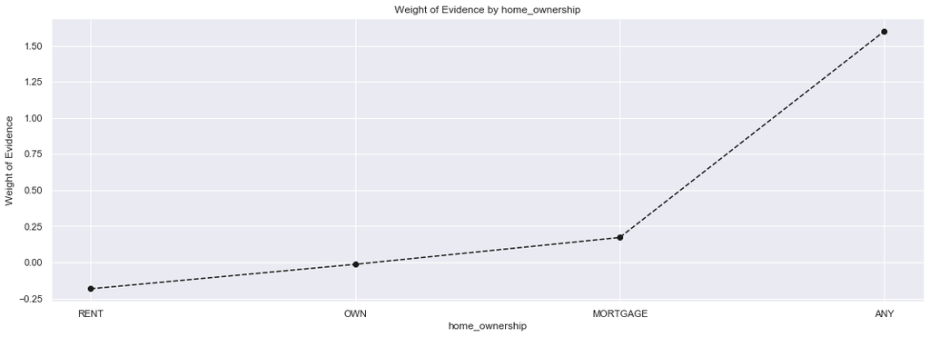

```python
df_ownership = calculate_woe(loan_data_inputs_prep, 'home_ownership', loan_data_target_prep)
lets_plot(df_ownership)
```

```python
df_ownership
```

|  | home_ownership | n_obs | %good_per_category | %bad_per_category | prop_obs | n_good | n_bad | %good | %bad | woe | diff_prop_good | diff_woe | IV |
| --- | --- | --- | --- | --- | --- | --- | --- | --- | --- | --- | --- | --- | --- |
| 0 | RENT | 82923 | 0.843228 | 0.156772 | 0.395412 | 69923.0 | 13000.0 | 0.385032 | 0.462469 | -0.183252 | NaN | NaN | 0.027992 |
| 1 | OWN | 24181 | 0.864356 | 0.135644 | 0.115305 | 20901.0 | 3280.0 | 0.115092 | 0.116684 | -0.013744 | 0.269940 | 0.169508 | 0.027992 |
| 2 | MORTGAGE | 102576 | 0.884681 | 0.115319 | 0.489126 | 90747.0 | 11829.0 | 0.499700 | 0.420811 | 0.171824 | 0.384608 | 0.185568 | 0.027992 |
| 3 | ANY | 33 | 0.969697 | 0.030303 | 0.000157 | 32.0 | 1.0 | 0.000176 | 0.000036 | 1.600038 | 0.499524 | 1.428215 | 0.027992 |

**Note: *The idea here is to merge them together and create a single dummy for* ANY, RENT & NONE.** We can therefore use the previously created dummies for the merging purpose.

```python
# merging the rent, home and any dummies.

# loan_data_inputs_prep.info(verbose=True)
loan_data_inputs_prep['home_ownership:RENT_ANY_NONE'] = sum([loan_data_inputs_prep['ownership:RENT'], loan_data_inputs_prep['ownership:ANY'], loan_data_inputs_prep['ownership:NONE']])
```

### Data Preprocessing / Discrete / addr_state

> `df_columnname` is the variable name for calculating the woe of grades.

```python
loan_data_inputs_prep.info(verbose=True)
```

```
<class 'pandas.core.frame.DataFrame'>
Int64Index: 209715 entries, 781974 to 487559
Data columns (total 281 columns):
 #   Column                                      Dtype
---  ------                                      -----
 0   id                                          object
 1   member_id                                   float64
 2   loan_amnt                                   float64
 3   funded_amnt                                 float64
 4   funded_amnt_inv                             float64
 5   term                                        object
 6   int_rate                                    float64
 7   installment                                 float64
 8   grade                                       object
 9   sub_grade                                   object
```

[output cut: 273 more lines]

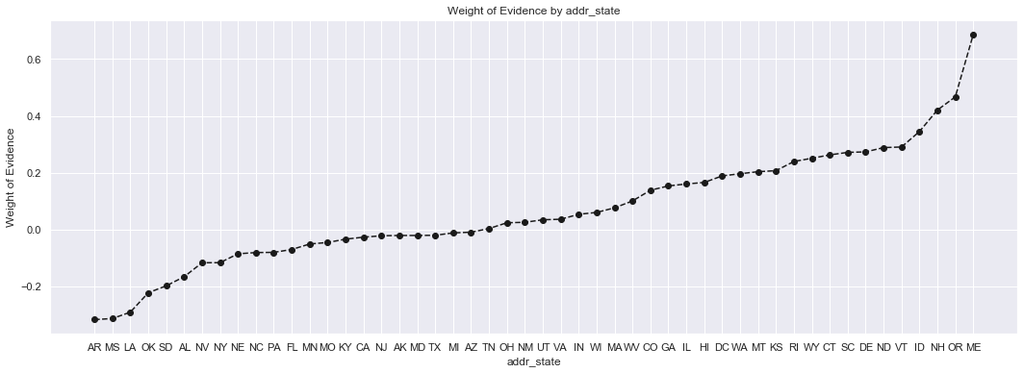

```python
df_addr_state = calculate_woe(loan_data_inputs_prep, 'addr_state', loan_data_target_prep)
lets_plot(df_addr_state)
```

```python
loan_data_inputs_prep['addr_state:AL_MS_AR_OK'] = sum([loan_data_inputs_prep['addr-state:AL'],
                                             loan_data_inputs_prep['addr-state:MS'],
                                             loan_data_inputs_prep['addr-state:AR'],
                                             loan_data_inputs_prep['addr-state:OK']])

loan_data_inputs_prep['addr_state:LA_NM_SD_HI_NV'] = sum([loan_data_inputs_prep['addr-state:LA'],
                                                loan_data_inputs_prep['addr-state:NM'],
                                                loan_data_inputs_prep['addr-state:SD'],
                                                loan_data_inputs_prep['addr-state:HI'],
                                                loan_data_inputs_prep['addr-state:NV']])
# NY is left alone
# FL is left alone

loan_data_inputs_prep['addr_state:NE_IN_NC_MD_MO_KY'] = sum([loan_data_inputs_prep['addr-state:NE'],
                                                loan_data_inputs_prep['addr-state:IN'],
                                                loan_data_inputs_prep['addr-state:NC'],
                                                loan_data_inputs_prep['addr-state:MD'],
                                                loan_data_inputs_prep['addr-state:MO'],
                                                loan_data_inputs_prep['addr-state:KY']])
# CA is left alone

loan_data_inputs_prep['addr_state:PA_NJ_OH_AK_MI_AZ_TN'] = sum([loan_data_inputs_prep['addr-state:PA'],
                                                      loan_data_inputs_prep['addr-state:NJ'],
                                                      loan_data_inputs_prep['addr-state:OH'],
                                                      loan_data_inputs_prep['addr-state:AK'],
                                                      loan_data_inputs_prep['addr-state:MI'],
                                                      loan_data_inputs_prep['addr-state:AZ'],
                                                      loan_data_inputs_prep['addr-state:TN']])
# TX is left alone

loan_data_inputs_prep['addr_state:MN_VA'] = sum([loan_data_inputs_prep['addr-state:MN'],
                                       loan_data_inputs_prep['addr-state:VA']])

loan_data_inputs_prep['addr_state:DE_WI_MA'] = sum([loan_data_inputs_prep['addr-state:DE'],
                                          loan_data_inputs_prep['addr-state:WI'],
                                          loan_data_inputs_prep['addr-state:MA']])

loan_data_inputs_prep['addr_state:UT_RI'] = sum([loan_data_inputs_prep['addr-state:UT'],
                                       loan_data_inputs_prep['addr-state:RI']])
# GA is left alone.

loan_data_inputs_prep['addr_state:WY_ND'] = sum([loan_data_inputs_prep['addr-state:WY'],
                                       loan_data_inputs_prep['addr-state:ND']])
# IL is left alone

loan_data_inputs_prep['addr_state:KS_MT_CT'] = sum([loan_data_inputs_prep['addr-state:KS'],
                                          loan_data_inputs_prep['addr-state:MT'],
                                          loan_data_inputs_prep['addr-state:CT']])

loan_data_inputs_prep['addr_state:WA_CO_SC'] = sum([loan_data_inputs_prep['addr-state:WA'],
                                          loan_data_inputs_prep['addr-state:CO'],
                                          loan_data_inputs_prep['addr-state:SC']])

loan_data_inputs_prep['addr_state:WV_DC_NH_OR'] = sum([loan_data_inputs_prep['addr-state:WV'],
                                             loan_data_inputs_prep['addr-state:DC'],
                                             loan_data_inputs_prep['addr-state:NH'],
                                             loan_data_inputs_prep['addr-state:OR']])

loan_data_inputs_prep['addr_state:ID_VT_ME'] = sum([loan_data_inputs_prep['addr-state:ID'],
                                          loan_data_inputs_prep['addr-state:VT'],
                                          loan_data_inputs_prep['addr-state:ME']])
```

### Data Preprocessing / Discrete / verification_status

```python
df_verstats = calculate_woe(loan_data_inputs_prep, 'verification_status', loan_data_target_prep)
df_verstats
```

|  | verification_status | n_obs | %good_per_category | %bad_per_category | prop_obs | n_good | n_bad | %good | %bad | woe | diff_prop_good | diff_woe | IV |
| --- | --- | --- | --- | --- | --- | --- | --- | --- | --- | --- | --- | --- | --- |
| 0 | Verified | 55282 | 0.823161 | 0.176839 | 0.263608 | 45506.0 | 9776.0 | 0.250580 | 0.347777 | -0.327784 | NaN | NaN | 0.087584 |
| 1 | Source Verified | 87630 | 0.859318 | 0.140682 | 0.417857 | 75302.0 | 12328.0 | 0.414652 | 0.438563 | -0.056064 | 0.164072 | 0.271720 | 0.087584 |
| 2 | Not Verified | 66801 | 0.910091 | 0.089909 | 0.318535 | 60795.0 | 6006.0 | 0.334769 | 0.213661 | 0.449051 | 0.079883 | 0.505115 | 0.087584 |

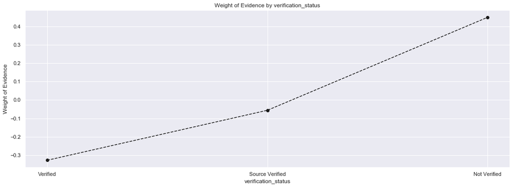

```python
lets_plot(df_verstats)
```

```python
# looking at the chart and the details, we can merge two sources which are verified.

loan_data_inputs_prep['verification_stats:verified'] = sum([loan_data_inputs_prep['ver-stats:Verified'],
                                                  loan_data_inputs_prep['ver-stats:Source Verified']])
```

### Data Preprocessing / Discrete / purpose

```python
df_purpose = calculate_woe(loan_data_inputs_prep, 'purpose', loan_data_target_prep)
df_purpose
```

|  | purpose | n_obs | %good_per_category | %bad_per_category | prop_obs | n_good | n_bad | %good | %bad | woe | diff_prop_good | diff_woe | IV |
| --- | --- | --- | --- | --- | --- | --- | --- | --- | --- | --- | --- | --- | --- |
| 0 | small_business | 1967 | 0.804779 | 0.195221 | 0.009379 | 1583.0 | 384.0 | 0.008717 | 0.013661 | -0.449263 | NaN | NaN | inf |
| 1 | moving | 1424 | 0.835674 | 0.164326 | 0.006790 | 1190.0 | 234.0 | 0.006553 | 0.008324 | -0.239310 | 0.002164 | 0.209953 | inf |
| 2 | house | 1155 | 0.853680 | 0.146320 | 0.005508 | 986.0 | 169.0 | 0.005429 | 0.006012 | -0.101940 | 0.001123 | 0.137370 | inf |
| 3 | debt_consolidation | 118928 | 0.854013 | 0.145987 | 0.567099 | 101566.0 | 17362.0 | 0.559275 | 0.617645 | -0.099273 | 0.553845 | 0.002667 | inf |
| 4 | renewable_energy | 110 | 0.854545 | 0.145455 | 0.000525 | 94.0 | 16.0 | 0.000518 | 0.000569 | -0.094992 | 0.558757 | 0.004281 | inf |
| 5 | medical | 2457 | 0.859178 | 0.140822 | 0.011716 | 2111.0 | 346.0 | 0.011624 | 0.012309 | -0.057219 | 0.011107 | 0.037772 | inf |
| 6 | other | 12554 | 0.864983 | 0.135017 | 0.059863 | 10859.0 | 1695.0 | 0.059795 | 0.060299 | -0.008386 | 0.048171 | 0.048833 | inf |
| 7 | major_purchase | 4545 | 0.872387 | 0.127613 | 0.021672 | 3965.0 | 580.0 | 0.021833 | 0.020633 | 0.056535 | 0.037962 | 0.064922 | inf |
| 8 | home_improvement | 14468 | 0.882154 | 0.117846 | 0.068990 | 12763.0 | 1705.0 | 0.070280 | 0.060655 | 0.147288 | 0.048446 | 0.090752 | inf |
| 9 | vacation | 1458 | 0.883402 | 0.116598 | 0.006952 | 1288.0 | 170.0 | 0.007092 | 0.006048 | 0.159350 | 0.063187 | 0.012062 | inf |
| 10 | car | 2049 | 0.887262 | 0.112738 | 0.009770 | 1818.0 | 231.0 | 0.010011 | 0.008218 | 0.197377 | 0.002918 | 0.038027 | inf |
| 11 | credit_card | 48595 | 0.892623 | 0.107377 | 0.231721 | 43377.0 | 5218.0 | 0.238856 | 0.185628 | 0.252118 | 0.228845 | 0.054741 | inf |
| 12 | wedding | 3 | 1.000000 | 0.000000 | 0.000014 | 3.0 | 0.0 | 0.000017 | 0.000000 | inf | 0.238840 | inf | inf |

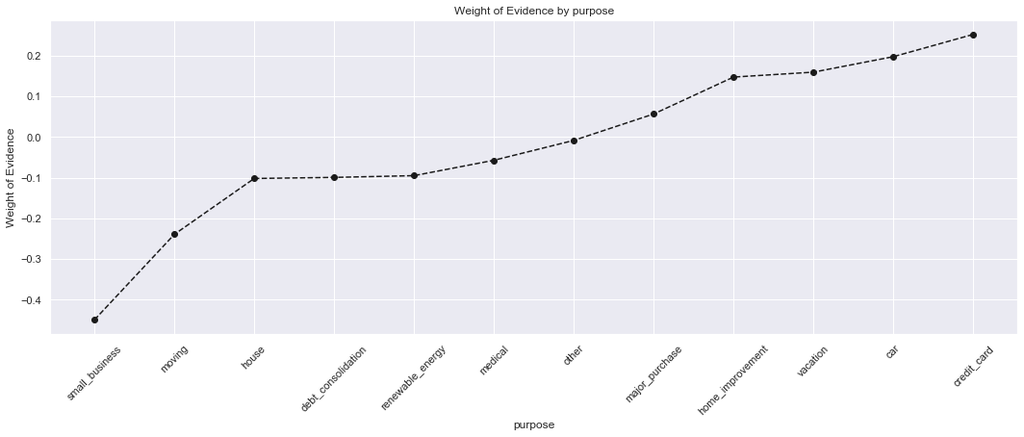

```python
lets_plot(df_purpose, 45)
```

```python
# analysis of the above chart.

loan_data_inputs_prep['purpose:small_bus_ren_energy'] = sum([loan_data_inputs_prep['purpose:small_business'],
                                           loan_data_inputs_prep['purpose:renewable_energy'],
                                           loan_data_inputs_prep['purpose:moving']])
# debt_consolidation is self-sufficient

loan_data_inputs_prep['purpose:wedding_medical_house'] = sum([loan_data_inputs_prep['purpose:wedding'],
                                           loan_data_inputs_prep['purpose:medical'],
                                           loan_data_inputs_prep['purpose:house']])
# other is left alone

loan_data_inputs_prep['purpose:vacation_majorpurchase'] = sum([loan_data_inputs_prep['purpose:vacation'],
                                           loan_data_inputs_prep['purpose:major_purchase']])

# home_improvement & credit_card are left alone

loan_data_inputs_prep['purpose:car_education'] = sum([loan_data_inputs_prep['purpose:car'],
                                           loan_data_inputs_prep['purpose:educational']])
```

### Data Preprocessing / Discrete / initial_list_status

> After getting an **IV of 0.03**, this variable seems not suitable as a good predictor. Hence we won't include this.

```python
df_liststatus = calculate_woe(loan_data_inputs_prep, 'initial_list_status', loan_data_target_prep)
df_liststatus
```

|  | initial_list_status | n_obs | %good_per_category | %bad_per_category | prop_obs | n_good | n_bad | %good | %bad | woe | diff_prop_good | diff_woe | IV |
| --- | --- | --- | --- | --- | --- | --- | --- | --- | --- | --- | --- | --- | --- |
| 0 | f | 54663 | 0.830031 | 0.169969 | 0.260656 | 45372.0 | 9291.0 | 0.249842 | 0.330523 | -0.279849 | NaN | NaN | 0.031759 |
| 1 | w | 155050 | 0.878626 | 0.121374 | 0.739344 | 136231.0 | 18819.0 | 0.750158 | 0.669477 | 0.113787 | 0.500317 | 0.393636 | 0.031759 |

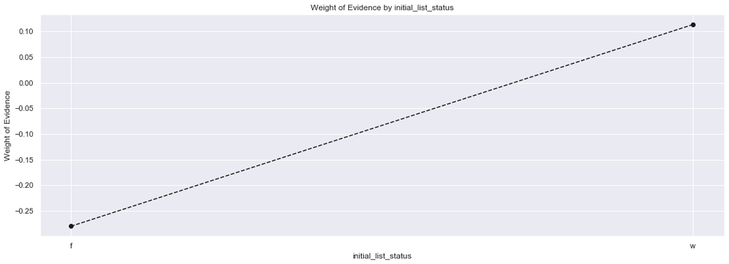

```python
lets_plot(df_liststatus)
```

### Data Preprocessing / Continuous / Finetuning and Coarse Classing

> The difference between discrete and continuous w.r.t calculating woe is that, in discrete the **order of the category doesnot matter.** But in continuous, the order does matters and hence we **won't sort the table of calculation w.r.t woe.**

```python
def calculate_woe_continuous(df, variable_for_iv, dependent_var):

    # concatenating the two columns
    df = pd.concat([df[variable_for_iv], dependent_var], axis=1)

    # since the first column(eg: grade) is categorical, it's a good thing to keep a count of default for each category.
    ''' I know that the target/output/y/default is in binary (1 for good(no_defualt) and 0 for default(bad), hence carrying out)
    the mean will give us a proportion of non default cases.'''

    df = pd.concat([df.groupby(df.columns.values[0], as_index = False)[df.columns.values[1]].count(),
                    df.groupby(df.columns.values[0], as_index = False)[df.columns.values[1]].mean()], axis=1)

    # since the groupby and concat causes repetation of grade, hence selecting only one of it.
    df = df.iloc[:, [0, 1, 3]]

    # renaming the column
    df.columns = [df.columns.values[0], 'n_obs', '%good_per_category']

    # finding the percentage of defaulters for each category
    df['%bad_per_category'] = 1 - df['%good_per_category']

    # finding the proportion of observation for each category
    df["prop_obs"] = df['n_obs'] / df['n_obs'].sum()

    '''when I multiply **no_of_observation with the **proportion_of_good/bad, then we get the number of observation
    of non-defaulters and defaulters.'''
    # say 100 obs for cat A, and 75% prop_good, then total good borrowers => 75% of 100 = 75
    df['n_good'] = df['n_obs'] * df['%good_per_category']
    df['n_bad'] = df['n_obs'] * df['%bad_per_category']

    # finding the percentage of non_defaulters and defaulters w.r.t all non_def and def.
    df['%good'] = df['n_good'] / df['n_good'].sum()
    df['%bad'] = df['n_bad'] / df['n_bad'].sum()

    # finding weight of evidence and sorting according to it.
    df['woe'] = np.log(df['%good'] / df['%bad'])
#     df = df.sort_values(['woe'])
#     df = df.reset_index(drop = True)

    # just knowing the difference of consequtive woe and prop_good
    df['diff_prop_good'] = df['%good'].diff().abs()
    df['diff_woe'] = df['woe'].diff().abs()

    # finally calculating information value.
    df['IV'] = ((df['%good'] - df['%bad']) * df['woe']).sum()

    return df
```

### Data Preprocessing / Continuous / term_int

> We have loan for two terms:
> - 36 months
> - 60 months

Hence we'll create dummy variable for two different terms.

```python
df_termint = calculate_woe_continuous(loan_data_inputs_prep, 'term_int', loan_data_target_prep)
df_termint
```

|  | term_int | n_obs | %good_per_category | %bad_per_category | prop_obs | n_good | n_bad | %good | %bad | woe | diff_prop_good | diff_woe | IV |
| --- | --- | --- | --- | --- | --- | --- | --- | --- | --- | --- | --- | --- | --- |
| 0 | 36.0 | 146800 | 0.885661 | 0.114339 | 0.700004 | 130015.0 | 16785.0 | 0.71593 | 0.597118 | 0.181467 | NaN | NaN | 0.063075 |
| 1 | 60.0 | 62913 | 0.819990 | 0.180010 | 0.299996 | 51588.0 | 11325.0 | 0.28407 | 0.402882 | -0.349421 | 0.43186 | 0.530888 | 0.063075 |

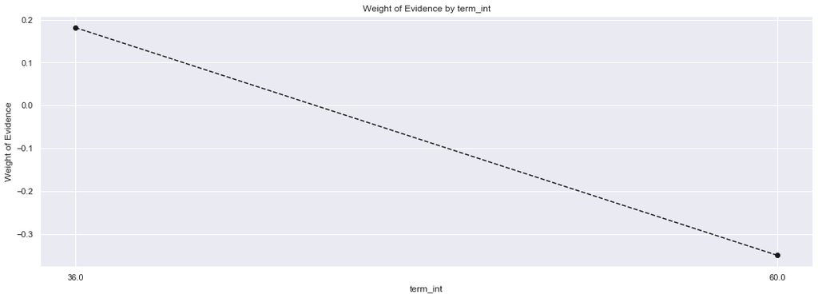

```python
lets_plot(df_termint)
```

```python
loan_data_inputs_prep['term_int:36'] = np.where((loan_data_inputs_prep['term_int'] == 36), 1, 0)
loan_data_inputs_prep['term_int:60'] = np.where((loan_data_inputs_prep['term_int'] == 60), 1, 0)
```

### Data Preprocessing / Continuous / employee_experience

> We have various time of experience, let's calculate woe and then we'll see how many categories we shall form.

```python
df_employeeexp = calculate_woe_continuous(loan_data_inputs_prep, 'emp_length_int', loan_data_target_prep)
df_employeeexp
```

|  | emp_length_int | n_obs | %good_per_category | %bad_per_category | prop_obs | n_good | n_bad | %good | %bad | woe | diff_prop_good | diff_woe | IV |
| --- | --- | --- | --- | --- | --- | --- | --- | --- | --- | --- | --- | --- | --- |
| 0 | 0.0 | 31926 | 0.850780 | 0.149220 | 0.152235 | 27162.0 | 4764.0 | 0.149566 | 0.169477 | -0.124977 | NaN | NaN | 0.006362 |
| 1 | 1.0 | 13757 | 0.860435 | 0.139565 | 0.065599 | 11837.0 | 1920.0 | 0.065180 | 0.068303 | -0.046804 | 0.084386 | 0.078174 | 0.006362 |
| 2 | 2.0 | 19087 | 0.865039 | 0.134961 | 0.091014 | 16511.0 | 2576.0 | 0.090917 | 0.091640 | -0.007920 | 0.025737 | 0.038884 | 0.006362 |
| 3 | 3.0 | 16790 | 0.861584 | 0.138416 | 0.080061 | 14466.0 | 2324.0 | 0.079656 | 0.082675 | -0.037197 | 0.011261 | 0.029278 | 0.006362 |
| 4 | 4.0 | 12648 | 0.868438 | 0.131562 | 0.060310 | 10984.0 | 1664.0 | 0.060483 | 0.059196 | 0.021507 | 0.019173 | 0.058704 | 0.006362 |
| 5 | 5.0 | 12865 | 0.867392 | 0.132608 | 0.061345 | 11159.0 | 1706.0 | 0.061447 | 0.060690 | 0.012386 | 0.000964 | 0.009120 | 0.006362 |
| 6 | 6.0 | 8652 | 0.877716 | 0.122284 | 0.041256 | 7594.0 | 1058.0 | 0.041816 | 0.037638 | 0.105270 | 0.019631 | 0.092883 | 0.006362 |
| 7 | 7.0 | 8089 | 0.867598 | 0.132402 | 0.038571 | 7018.0 | 1071.0 | 0.038644 | 0.038100 | 0.014177 | 0.003172 | 0.091093 | 0.006362 |
| 8 | 8.0 | 8712 | 0.850895 | 0.149105 | 0.041542 | 7413.0 | 1299.0 | 0.040819 | 0.046211 | -0.124068 | 0.002175 | 0.138245 | 0.006362 |
| 9 | 9.0 | 7513 | 0.859311 | 0.140689 | 0.035825 | 6456.0 | 1057.0 | 0.035550 | 0.037602 | -0.056133 | 0.005270 | 0.067935 | 0.006362 |
| 10 | 10.0 | 69676 | 0.875553 | 0.124447 | 0.332241 | 61005.0 | 8671.0 | 0.335921 | 0.308467 | 0.085263 | 0.300372 | 0.141396 | 0.006362 |

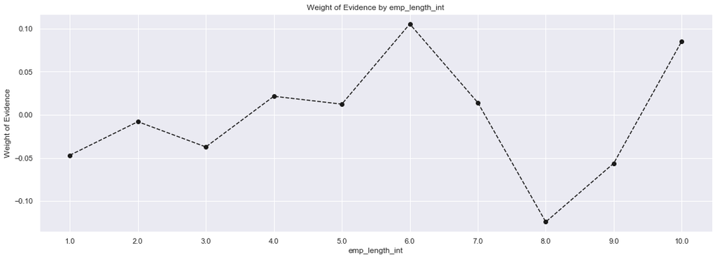

```python
lets_plot(df_employeeexp.iloc[1:,:])
```

```python
loan_data_inputs_prep['empexp:0_00'] = sum([np.where((loan_data_inputs_prep['emp_length_int'] == 0.0), 1, 0),
                               np.where((loan_data_inputs_prep['emp_length_int'] == '0'), 1, 0)])

loan_data_inputs_prep['empexp:1'] = np.where((loan_data_inputs_prep['emp_length_int'] == 1.0), 1, 0)

loan_data_inputs_prep['empexp:2_3_4'] = sum([np.where((loan_data_inputs_prep['emp_length_int'] == 2.0), 1, 0),
                                   np.where((loan_data_inputs_prep['emp_length_int'] == 3.0), 1, 0),
                                   np.where((loan_data_inputs_prep['emp_length_int'] == 4.0), 1, 0)])

loan_data_inputs_prep['empexp:5_6'] = sum([np.where((loan_data_inputs_prep['emp_length_int'] == 5.0), 1, 0),
                                 np.where((loan_data_inputs_prep['emp_length_int'] == 6.0), 1, 0)])

loan_data_inputs_prep['empexp:7_8_9'] = sum([np.where((loan_data_inputs_prep['emp_length_int'] == 7.0), 1, 0),
                                   np.where((loan_data_inputs_prep['emp_length_int'] == 8.0), 1, 0),
                                   np.where((loan_data_inputs_prep['emp_length_int'] == 9.0), 1, 0)])

loan_data_inputs_prep['empexp:10'] = np.where((loan_data_inputs_prep['emp_length_int'] == 10.0), 1, 0)
```

### Data Preprocessing / Continuous / Too_many_categories / months_since_loan_issued

> When you have **too many categories that crosses over 100**, then a good thing to do is to break the whole categories into some interval. **50 cats is a good one.**

> Do follow the observations for better categorizing.

```python
df_months = calculate_woe_continuous(loan_data_inputs_prep, 'months_since_loan_issue_date', loan_data_target_prep)
df_months
```

|  | months_since_loan_issue_date | n_obs | %good_per_category | %bad_per_category | prop_obs | n_good | n_bad | %good | %bad | woe | diff_prop_good | diff_woe | IV |
| --- | --- | --- | --- | --- | --- | --- | --- | --- | --- | --- | --- | --- | --- |
| 0 | 19.0 | 7876 | 0.983621 | 0.016379 | 0.037556 | 7747.0 | 129.0 | 0.042659 | 0.004589 | 2.229551 | NaN | NaN | 0.39067 |
| 1 | 20.0 | 8990 | 0.980089 | 0.019911 | 0.042868 | 8811.0 | 179.0 | 0.048518 | 0.006368 | 2.030673 | 0.005859 | 0.198878 | 0.39067 |
| 2 | 21.0 | 8647 | 0.971782 | 0.028218 | 0.041233 | 8403.0 | 244.0 | 0.046271 | 0.008680 | 1.673478 | 0.002247 | 0.357195 | 0.39067 |
| 3 | 25.0 | 7645 | 0.945455 | 0.054545 | 0.036455 | 7228.0 | 417.0 | 0.039801 | 0.014835 | 0.986934 | 0.006470 | 0.686544 | 0.39067 |
| 4 | 26.0 | 6407 | 0.939285 | 0.060715 | 0.030551 | 6018.0 | 389.0 | 0.033138 | 0.013838 | 0.873233 | 0.006663 | 0.113701 | 0.39067 |
| 5 | 27.0 | 7185 | 0.937230 | 0.062770 | 0.034261 | 6734.0 | 451.0 | 0.037081 | 0.016044 | 0.837760 | 0.003943 | 0.035474 | 0.39067 |
| 6 | 31.0 | 7927 | 0.900845 | 0.099155 | 0.037799 | 7141.0 | 786.0 | 0.039322 | 0.027962 | 0.340954 | 0.002241 | 0.496806 | 0.39067 |
| 7 | 32.0 | 8745 | 0.899371 | 0.100629 | 0.041700 | 7865.0 | 880.0 | 0.043309 | 0.031306 | 0.324558 | 0.003987 | 0.016395 | 0.39067 |
| 8 | 33.0 | 7902 | 0.889648 | 0.110352 | 0.037680 | 7030.0 | 872.0 | 0.038711 | 0.031021 | 0.221455 | 0.004598 | 0.103103 | 0.39067 |
| 9 | 34.0 | 7753 | 0.892429 | 0.107571 | 0.036970 | 6919.0 | 834.0 | 0.038100 | 0.029669 | 0.250096 | 0.000611 | 0.028641 | 0.39067 |
| 10 | 35.0 | 7481 | 0.882770 | 0.117230 | 0.035673 | 6604.0 | 877.0 | 0.036365 | 0.031199 | 0.153226 | 0.001735 | 0.096869 | 0.39067 |
| 11 | 36.0 | 5918 | 0.877323 | 0.122677 | 0.028220 | 5192.0 | 726.0 | 0.028590 | 0.025827 | 0.101627 | 0.007775 | 0.051600 | 0.39067 |
| 12 | 46.0 | 6675 | 0.831760 | 0.168240 | 0.031829 | 5552.0 | 1123.0 | 0.030572 | 0.039950 | -0.267543 | 0.001982 | 0.369170 | 0.39067 |
| 13 | 47.0 | 5687 | 0.818885 | 0.181115 | 0.027118 | 4657.0 | 1030.0 | 0.025644 | 0.036642 | -0.356885 | 0.004928 | 0.089342 | 0.39067 |
| 14 | 48.0 | 7261 | 0.825782 | 0.174218 | 0.034624 | 5996.0 | 1265.0 | 0.033017 | 0.045002 | -0.309677 | 0.007373 | 0.047208 | 0.39067 |
| 15 | 49.0 | 12086 | 0.823267 | 0.176733 | 0.057631 | 9950.0 | 2136.0 | 0.054790 | 0.075987 | -0.327060 | 0.021773 | 0.017383 | 0.39067 |
| 16 | 50.0 | 1041 | 0.846302 | 0.153698 | 0.004964 | 881.0 | 160.0 | 0.004851 | 0.005692 | -0.159814 | 0.049939 | 0.167246 | 0.39067 |
| 17 | 52.0 | 8955 | 0.805137 | 0.194863 | 0.042701 | 7210.0 | 1745.0 | 0.039702 | 0.062078 | -0.446983 | 0.034851 | 0.287169 | 0.39067 |
| 18 | 53.0 | 7383 | 0.822836 | 0.177164 | 0.035205 | 6075.0 | 1308.0 | 0.033452 | 0.046531 | -0.330015 | 0.006250 | 0.116968 | 0.39067 |
| 19 | 54.0 | 9729 | 0.829171 | 0.170829 | 0.046392 | 8067.0 | 1662.0 | 0.044421 | 0.059125 | -0.285938 | 0.010969 | 0.044077 | 0.39067 |
| 20 | 55.0 | 5882 | 0.805168 | 0.194832 | 0.028048 | 4736.0 | 1146.0 | 0.026079 | 0.040768 | -0.446782 | 0.018342 | 0.160845 | 0.39067 |
| 21 | 56.0 | 7117 | 0.818322 | 0.181678 | 0.033937 | 5824.0 | 1293.0 | 0.032070 | 0.045998 | -0.360675 | 0.005991 | 0.086107 | 0.39067 |
| 22 | 57.0 | 9242 | 0.812270 | 0.187730 | 0.044070 | 7507.0 | 1735.0 | 0.041337 | 0.061722 | -0.400869 | 0.009267 | 0.040194 | 0.39067 |
| 23 | 58.0 | 5775 | 0.810909 | 0.189091 | 0.027538 | 4683.0 | 1092.0 | 0.025787 | 0.038847 | -0.409770 | 0.015550 | 0.008900 | 0.39067 |
| 24 | 59.0 | 6351 | 0.815305 | 0.184695 | 0.030284 | 5178.0 | 1173.0 | 0.028513 | 0.041729 | -0.380843 | 0.002726 | 0.028926 | 0.39067 |
| 25 | 60.0 | 7025 | 0.814662 | 0.185338 | 0.033498 | 5723.0 | 1302.0 | 0.031514 | 0.046318 | -0.385106 | 0.003001 | 0.004263 | 0.39067 |
| 26 | 61.0 | 5098 | 0.806395 | 0.193605 | 0.024309 | 4111.0 | 987.0 | 0.022637 | 0.035112 | -0.438946 | 0.008877 | 0.053840 | 0.39067 |
| 27 | 62.0 | 4801 | 0.817955 | 0.182045 | 0.022893 | 3927.0 | 874.0 | 0.021624 | 0.031092 | -0.363147 | 0.001013 | 0.075799 | 0.39067 |
| 28 | 63.0 | 7129 | 0.818348 | 0.181652 | 0.033994 | 5834.0 | 1295.0 | 0.032125 | 0.046069 | -0.360505 | 0.010501 | 0.002641 | 0.39067 |

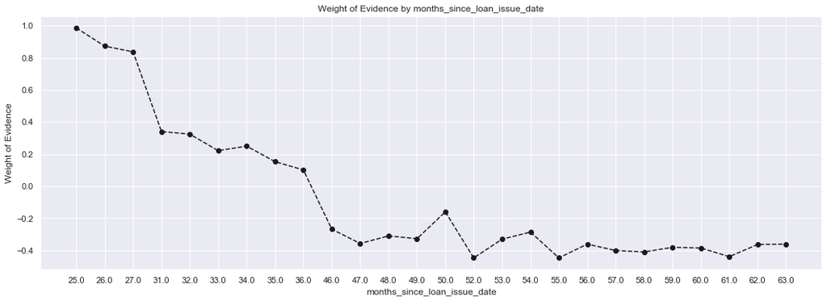

```python
lets_plot(df_months.iloc[3:, :])
```

```python
loan_data_inputs_prep['months:19']                =      np.where(loan_data_inputs_prep['months_since_loan_issue_date'].isin([19.0]), 1, 0)
loan_data_inputs_prep['months:20']                =      np.where(loan_data_inputs_prep['months_since_loan_issue_date'].isin([20.0]), 1, 0)
loan_data_inputs_prep['months:21']                =      np.where(loan_data_inputs_prep['months_since_loan_issue_date'].isin([21.0]), 1, 0)
loan_data_inputs_prep['months:25_26_27']          = sum([np.where(loan_data_inputs_prep['months_since_loan_issue_date'].isin([25.0]), 1, 0),
                                               np.where(loan_data_inputs_prep['months_since_loan_issue_date'].isin([26.0]), 1, 0),
                                               np.where(loan_data_inputs_prep['months_since_loan_issue_date'].isin([27.0]), 1, 0)])
loan_data_inputs_prep['months:31_32_33_34_35_36'] = sum([np.where(loan_data_inputs_prep['months_since_loan_issue_date'].isin([31.0]), 1, 0),
                                               np.where(loan_data_inputs_prep['months_since_loan_issue_date'].isin([32.0]), 1, 0),
                                               np.where(loan_data_inputs_prep['months_since_loan_issue_date'].isin([33.0]), 1, 0),
                                               np.where(loan_data_inputs_prep['months_since_loan_issue_date'].isin([34.0]), 1, 0),
                                               np.where(loan_data_inputs_prep['months_since_loan_issue_date'].isin([35.0]), 1, 0),
                                               np.where(loan_data_inputs_prep['months_since_loan_issue_date'].isin([36.0]), 1, 0)])
loan_data_inputs_prep['months:46_47_48_49']       = sum([np.where(loan_data_inputs_prep['months_since_loan_issue_date'].isin([46.0]), 1, 0),
                                               np.where(loan_data_inputs_prep['months_since_loan_issue_date'].isin([47.0]), 1, 0),
                                               np.where(loan_data_inputs_prep['months_since_loan_issue_date'].isin([48.0]), 1, 0),
                                               np.where(loan_data_inputs_prep['months_since_loan_issue_date'].isin([49.0]), 1, 0)])
loan_data_inputs_prep['months:50']                =      np.where(loan_data_inputs_prep['months_since_loan_issue_date'].isin([50.0]), 1, 0)
loan_data_inputs_prep['months:>52']               = sum([np.where(loan_data_inputs_prep['months_since_loan_issue_date'].isin([52.0]), 1, 0),
                                               np.where(loan_data_inputs_prep['months_since_loan_issue_date'].isin([53.0]), 1, 0),
                                               np.where(loan_data_inputs_prep['months_since_loan_issue_date'].isin([54.0]), 1, 0),
                                               np.where(loan_data_inputs_prep['months_since_loan_issue_date'].isin([55.0]), 1, 0),
                                               np.where(loan_data_inputs_prep['months_since_loan_issue_date'].isin([56.0]), 1, 0),
                                               np.where(loan_data_inputs_prep['months_since_loan_issue_date'].isin([57.0]), 1, 0),
                                               np.where(loan_data_inputs_prep['months_since_loan_issue_date'].isin([58.0]), 1, 0),
                                               np.where(loan_data_inputs_prep['months_since_loan_issue_date'].isin([59.0]), 1, 0),
                                               np.where(loan_data_inputs_prep['months_since_loan_issue_date'].isin([60.0]), 1, 0),
                                               np.where(loan_data_inputs_prep['months_since_loan_issue_date'].isin([61.0]), 1, 0),
                                               np.where(loan_data_inputs_prep['months_since_loan_issue_date'].isin([62.0]), 1, 0),
                                               np.where(loan_data_inputs_prep['months_since_loan_issue_date'].isin([63.0]), 1, 0)])
```

### Data Preprocessing / Continuous / Too_many_categories / int_rate(interest)

> Pandas `pd.cut(dataframe, intervals)` function helps us to divide any number of category within defined intervals.

```python
loan_data_inputs_prep['int_rate_interval'] = pd.cut(loan_data_inputs_prep['int_rate'], 50)
df_interest = calculate_woe_continuous(loan_data_inputs_prep,'int_rate_interval', loan_data_target_prep)
df_interest
```

|  | int_rate_interval | n_obs | %good_per_category | %bad_per_category | prop_obs | n_good | n_bad | %good | %bad | woe | diff_prop_good | diff_woe | IV |
| --- | --- | --- | --- | --- | --- | --- | --- | --- | --- | --- | --- | --- | --- |
| 0 | (5.284, 5.824] | 6784 | 0.978331 | 0.021669 | 0.032349 | 6637.0 | 147.0 | 0.036547 | 0.005229 | 1.944285 | NaN | NaN | 0.518018 |
| 1 | (5.824, 6.337] | 4979 | 0.980719 | 0.019281 | 0.023742 | 4883.0 | 96.0 | 0.026888 | 0.003415 | 2.063469 | 0.009658 | 0.119184 | 0.518018 |
| 2 | (6.337, 6.851] | 4595 | 0.974755 | 0.025245 | 0.021911 | 4479.0 | 116.0 | 0.024664 | 0.004127 | 1.787867 | 0.002225 | 0.275602 | 0.518018 |
| 3 | (6.851, 7.364] | 11397 | 0.966307 | 0.033693 | 0.054346 | 11013.0 | 384.0 | 0.060643 | 0.013661 | 1.490492 | 0.035980 | 0.297376 | 0.518018 |
| 4 | (7.364, 7.878] | 3885 | 0.952124 | 0.047876 | 0.018525 | 3699.0 | 186.0 | 0.020369 | 0.006617 | 1.124374 | 0.040275 | 0.366118 | 0.518018 |
| 5 | (7.878, 8.392] | 15109 | 0.929777 | 0.070223 | 0.072046 | 14048.0 | 1061.0 | 0.077356 | 0.037745 | 0.717571 | 0.056987 | 0.406803 | 0.518018 |
| 6 | (8.392, 8.905] | 1956 | 0.970348 | 0.029652 | 0.009327 | 1898.0 | 58.0 | 0.010451 | 0.002063 | 1.622415 | 0.066904 | 0.904845 | 0.518018 |
| 7 | (8.905, 9.419] | 5741 | 0.895489 | 0.104511 | 0.027376 | 5141.0 | 600.0 | 0.028309 | 0.021345 | 0.282376 | 0.017858 | 1.340040 | 0.518018 |
| 8 | (9.419, 9.932] | 9970 | 0.929288 | 0.070712 | 0.047541 | 9265.0 | 705.0 | 0.051018 | 0.025080 | 0.710104 | 0.022709 | 0.427728 | 0.518018 |
| 9 | (9.932, 10.446] | 8867 | 0.922409 | 0.077591 | 0.042282 | 8179.0 | 688.0 | 0.045038 | 0.024475 | 0.609839 | 0.005980 | 0.100265 | 0.518018 |
| 10 | (10.446, 10.96] | 7982 | 0.912052 | 0.087948 | 0.038062 | 7280.0 | 702.0 | 0.040087 | 0.024973 | 0.473255 | 0.004950 | 0.136584 | 0.518018 |
| 11 | (10.96, 11.473] | 9032 | 0.880647 | 0.119353 | 0.043068 | 7954.0 | 1078.0 | 0.043799 | 0.038349 | 0.132870 | 0.003711 | 0.340385 | 0.518018 |
| 12 | (11.473, 11.987] | 6820 | 0.892815 | 0.107185 | 0.032521 | 6089.0 | 731.0 | 0.033529 | 0.026005 | 0.254128 | 0.010270 | 0.121258 | 0.518018 |
| 13 | (11.987, 12.5] | 11177 | 0.856938 | 0.143062 | 0.053297 | 9578.0 | 1599.0 | 0.052741 | 0.056884 | -0.075607 | 0.019212 | 0.329735 | 0.518018 |
| 14 | (12.5, 13.014] | 12950 | 0.866873 | 0.133127 | 0.061751 | 11226.0 | 1724.0 | 0.061816 | 0.061330 | 0.007888 | 0.009075 | 0.083495 | 0.518018 |
| 15 | (13.014, 13.528] | 5285 | 0.812299 | 0.187701 | 0.025201 | 4293.0 | 992.0 | 0.023639 | 0.035290 | -0.400680 | 0.038177 | 0.408567 | 0.518018 |
| 16 | (13.528, 14.041] | 12079 | 0.844275 | 0.155725 | 0.057598 | 10198.0 | 1881.0 | 0.056155 | 0.066916 | -0.175310 | 0.032516 | 0.225370 | 0.518018 |
| 17 | (14.041, 14.555] | 7705 | 0.863984 | 0.136016 | 0.036741 | 6657.0 | 1048.0 | 0.036657 | 0.037282 | -0.016912 | 0.019499 | 0.158397 | 0.518018 |
| 18 | (14.555, 15.068] | 8630 | 0.852491 | 0.147509 | 0.041151 | 7357.0 | 1273.0 | 0.040511 | 0.045286 | -0.111422 | 0.003855 | 0.094509 | 0.518018 |
| 19 | (15.068, 15.582] | 1928 | 0.759336 | 0.240664 | 0.009194 | 1464.0 | 464.0 | 0.008062 | 0.016507 | -0.716654 | 0.032450 | 0.605233 | 0.518018 |
| 20 | (15.582, 16.096] | 7906 | 0.813559 | 0.186441 | 0.037699 | 6432.0 | 1474.0 | 0.035418 | 0.052437 | -0.392392 | 0.027356 | 0.324263 | 0.518018 |
| 21 | (16.096, 16.609] | 4738 | 0.785564 | 0.214436 | 0.022593 | 3722.0 | 1016.0 | 0.020495 | 0.036144 | -0.567310 | 0.014923 | 0.174918 | 0.518018 |
| 22 | (16.609, 17.123] | 4622 | 0.821073 | 0.178927 | 0.022040 | 3795.0 | 827.0 | 0.020897 | 0.029420 | -0.342063 | 0.000402 | 0.225247 | 0.518018 |
| 23 | (17.123, 17.636] | 3487 | 0.722397 | 0.277603 | 0.016627 | 2519.0 | 968.0 | 0.013871 | 0.034436 | -0.909312 | 0.007026 | 0.567250 | 0.518018 |
| 24 | (17.636, 18.15] | 4525 | 0.798011 | 0.201989 | 0.021577 | 3611.0 | 914.0 | 0.019884 | 0.032515 | -0.491788 | 0.006013 | 0.417524 | 0.518018 |
| 25 | (18.15, 18.664] | 3830 | 0.685901 | 0.314099 | 0.018263 | 2627.0 | 1203.0 | 0.014466 | 0.042796 | -1.084674 | 0.005418 | 0.592885 | 0.518018 |
| 26 | (18.664, 19.177] | 3852 | 0.799585 | 0.200415 | 0.018368 | 3080.0 | 772.0 | 0.016960 | 0.027464 | -0.481997 | 0.002494 | 0.602676 | 0.518018 |
| 27 | (19.177, 19.691] | 1959 | 0.669729 | 0.330271 | 0.009341 | 1312.0 | 647.0 | 0.007225 | 0.023017 | -1.158736 | 0.009736 | 0.676739 | 0.518018 |
| 28 | (19.691, 20.204] | 3349 | 0.766199 | 0.233801 | 0.015969 | 2566.0 | 783.0 | 0.014130 | 0.027855 | -0.678727 | 0.006905 | 0.480009 | 0.518018 |
| 29 | (20.204, 20.718] | 520 | 0.761538 | 0.238462 | 0.002480 | 396.0 | 124.0 | 0.002181 | 0.004411 | -0.704565 | 0.011949 | 0.025838 | 0.518018 |
| 30 | (20.718, 21.232] | 2074 | 0.738187 | 0.261813 | 0.009890 | 1531.0 | 543.0 | 0.008430 | 0.019317 | -0.829131 | 0.006250 | 0.124566 | 0.518018 |
| 31 | (21.232, 21.745] | 1342 | 0.780179 | 0.219821 | 0.006399 | 1047.0 | 295.0 | 0.005765 | 0.010494 | -0.598989 | 0.002665 | 0.230142 | 0.518018 |
| 32 | (21.745, 22.259] | 973 | 0.685509 | 0.314491 | 0.004640 | 667.0 | 306.0 | 0.003673 | 0.010886 | -1.086493 | 0.002092 | 0.487504 | 0.518018 |
| 33 | (22.259, 22.772] | 1043 | 0.819751 | 0.180249 | 0.004973 | 855.0 | 188.0 | 0.004708 | 0.006688 | -0.351038 | 0.001035 | 0.735455 | 0.518018 |
| 34 | (22.772, 23.286] | 952 | 0.642857 | 0.357143 | 0.004540 | 612.0 | 340.0 | 0.003370 | 0.012095 | -1.277911 | 0.001338 | 0.926873 | 0.518018 |
| 35 | (23.286, 23.8] | 252 | 0.873016 | 0.126984 | 0.001202 | 220.0 | 32.0 | 0.001211 | 0.001138 | 0.062194 | 0.002159 | 1.340105 | 0.518018 |
| 36 | (23.8, 24.313] | 1250 | 0.695200 | 0.304800 | 0.005961 | 869.0 | 381.0 | 0.004785 | 0.013554 | -1.041154 | 0.003574 | 1.103348 | 0.518018 |
| 37 | (24.313, 24.827] | 372 | 0.771505 | 0.228495 | 0.001774 | 287.0 | 85.0 | 0.001580 | 0.003024 | -0.648867 | 0.003205 | 0.392287 | 0.518018 |
| 38 | (24.827, 25.34] | 1250 | 0.716800 | 0.283200 | 0.005961 | 896.0 | 354.0 | 0.004934 | 0.012593 | -0.937054 | 0.003353 | 0.288187 | 0.518018 |
| 39 | (25.34, 25.854] | 848 | 0.705189 | 0.294811 | 0.004044 | 598.0 | 250.0 | 0.003293 | 0.008894 | -0.993568 | 0.001641 | 0.056514 | 0.518018 |
| 40 | (25.854, 26.368] | 1096 | 0.731752 | 0.268248 | 0.005226 | 802.0 | 294.0 | 0.004416 | 0.010459 | -0.862169 | 0.001123 | 0.131399 | 0.518018 |
| 41 | (26.368, 26.881] | 268 | 0.660448 | 0.339552 | 0.001278 | 177.0 | 91.0 | 0.000975 | 0.003237 | -1.200407 | 0.003442 | 0.338239 | 0.518018 |
| 42 | (26.881, 27.395] | 385 | 0.807792 | 0.192208 | 0.001836 | 311.0 | 74.0 | 0.001713 | 0.002633 | -0.429970 | 0.000738 | 0.770438 | 0.518018 |
| 43 | (27.395, 27.908] | 61 | 0.508197 | 0.491803 | 0.000291 | 31.0 | 30.0 | 0.000171 | 0.001067 | -1.832908 | 0.001542 | 1.402938 | 0.518018 |
| 44 | (27.908, 28.422] | 86 | 0.511628 | 0.488372 | 0.000410 | 44.0 | 42.0 | 0.000242 | 0.001494 | -1.819178 | 0.000072 | 0.013730 | 0.518018 |
| 45 | (28.422, 28.936] | 381 | 0.721785 | 0.278215 | 0.001817 | 275.0 | 106.0 | 0.001514 | 0.003771 | -0.912366 | 0.001272 | 0.906812 | 0.518018 |
| 46 | (28.936, 29.449] | 46 | 0.434783 | 0.565217 | 0.000219 | 20.0 | 26.0 | 0.000110 | 0.000925 | -2.128062 | 0.001404 | 1.215696 | 0.518018 |
| 47 | (29.449, 29.963] | 226 | 0.716814 | 0.283186 | 0.001078 | 162.0 | 64.0 | 0.000892 | 0.002277 | -0.936984 | 0.000782 | 1.191078 | 0.518018 |
| 48 | (29.963, 30.476] | 221 | 0.696833 | 0.303167 | 0.001054 | 154.0 | 67.0 | 0.000848 | 0.002383 | -1.033438 | 0.000044 | 0.096453 | 0.518018 |
| 49 | (30.476, 30.99] | 928 | 0.697198 | 0.302802 | 0.004425 | 647.0 | 281.0 | 0.003563 | 0.009996 | -1.031706 | 0.002715 | 0.001732 | 0.518018 |

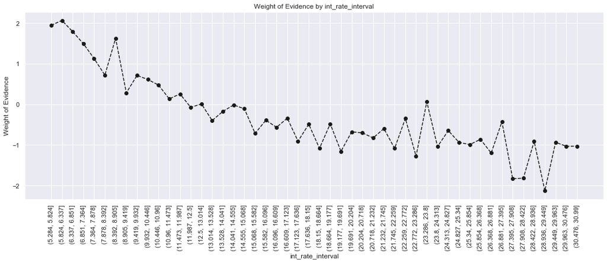

```python
lets_plot(df_interest, 90)
```

```python
loan_data_inputs_prep['interest:<8.905']        = np.where((loan_data_inputs_prep['int_rate'] <= 8.905), 1, 0)
loan_data_inputs_prep['interest:8.905-15.068']  = np.where((loan_data_inputs_prep['int_rate'] > 8.905) & (loan_data_inputs_prep['int_rate'] <= 15.068), 1, 0)
loan_data_inputs_prep['interest:15.068-21.745'] = np.where((loan_data_inputs_prep['int_rate'] > 15.068) & (loan_data_inputs_prep['int_rate'] <= 21.745), 1, 0)
loan_data_inputs_prep['interest:21.745-26.368'] = np.where((loan_data_inputs_prep['int_rate'] > 21.745) & (loan_data_inputs_prep['int_rate'] <= 26.368), 1, 0)
loan_data_inputs_prep['interest:>26.368']       = np.where((loan_data_inputs_prep['int_rate'] > 26.368), 1, 0)
```

### Data Preprocessing / Continuous / Too_many_categories / funded_amount

> Looking at this variable, it has a pretty **low IV** and a **random trend.** So we'll not include this in our thing.

```python
loan_data_inputs_prep['funded_amount_interval'] = pd.cut(loan_data_inputs_prep['funded_amnt'], 50)
```

```python
df_funded = calculate_woe_continuous(loan_data_inputs_prep, 'funded_amount_interval', loan_data_target_prep)
df_funded
```

|  | funded_amount_interval | n_obs | %good_per_category | %bad_per_category | prop_obs | n_good | n_bad | %good | %bad | woe | diff_prop_good | diff_woe | IV |
| --- | --- | --- | --- | --- | --- | --- | --- | --- | --- | --- | --- | --- | --- |
| 0 | (961.0, 1780.0] | 2202 | 0.909628 | 0.090372 | 0.010500 | 2003.0 | 199.0 | 0.011030 | 0.007079 | 0.443399 | NaN | NaN | 0.042719 |
| 1 | (1780.0, 2560.0] | 3615 | 0.900415 | 0.099585 | 0.017238 | 3255.0 | 360.0 | 0.017924 | 0.012807 | 0.336146 | 0.006894 | 0.107253 | 0.042719 |
| 2 | (2560.0, 3340.0] | 4210 | 0.891211 | 0.108789 | 0.020075 | 3752.0 | 458.0 | 0.020660 | 0.016293 | 0.237478 | 0.002737 | 0.098668 | 0.042719 |
| 3 | (3340.0, 4120.0] | 5552 | 0.886347 | 0.113653 | 0.026474 | 4921.0 | 631.0 | 0.027098 | 0.022448 | 0.188264 | 0.006437 | 0.049214 | 0.042719 |
| 4 | (4120.0, 4900.0] | 3396 | 0.879859 | 0.120141 | 0.016194 | 2988.0 | 408.0 | 0.016453 | 0.014514 | 0.125395 | 0.010644 | 0.062869 | 0.042719 |
| 5 | (4900.0, 5680.0] | 10425 | 0.889209 | 0.110791 | 0.049711 | 9270.0 | 1155.0 | 0.051045 | 0.041089 | 0.216985 | 0.034592 | 0.091591 | 0.042719 |
| 6 | (5680.0, 6460.0] | 8898 | 0.883569 | 0.116431 | 0.042429 | 7862.0 | 1036.0 | 0.043292 | 0.036855 | 0.160976 | 0.007753 | 0.056009 | 0.042719 |
| 7 | (6460.0, 7240.0] | 7042 | 0.887248 | 0.112752 | 0.033579 | 6248.0 | 794.0 | 0.034405 | 0.028246 | 0.197236 | 0.008888 | 0.036259 | 0.042719 |
| 8 | (7240.0, 8020.0] | 9579 | 0.874308 | 0.125692 | 0.045677 | 8375.0 | 1204.0 | 0.046117 | 0.042832 | 0.073904 | 0.011712 | 0.123331 | 0.042719 |
| 9 | (8020.0, 8800.0] | 2951 | 0.854964 | 0.145036 | 0.014072 | 2523.0 | 428.0 | 0.013893 | 0.015226 | -0.091617 | 0.032224 | 0.165521 | 0.042719 |
| 10 | (8800.0, 9580.0] | 3903 | 0.859339 | 0.140661 | 0.018611 | 3354.0 | 549.0 | 0.018469 | 0.019530 | -0.055887 | 0.004576 | 0.035730 | 0.042719 |
| 11 | (9580.0, 10360.0] | 20026 | 0.879906 | 0.120094 | 0.095492 | 17621.0 | 2405.0 | 0.097030 | 0.085557 | 0.125844 | 0.078561 | 0.181731 | 0.042719 |
| 12 | (10360.0, 11140.0] | 4242 | 0.860679 | 0.139321 | 0.020228 | 3651.0 | 591.0 | 0.020104 | 0.021025 | -0.044757 | 0.076926 | 0.170601 | 0.042719 |
| 13 | (11140.0, 11920.0] | 2609 | 0.810272 | 0.189728 | 0.012441 | 2114.0 | 495.0 | 0.011641 | 0.017609 | -0.413918 | 0.008464 | 0.369161 | 0.042719 |
| 14 | (11920.0, 12700.0] | 13321 | 0.862097 | 0.137903 | 0.063520 | 11484.0 | 1837.0 | 0.063237 | 0.065350 | -0.032877 | 0.051596 | 0.381042 | 0.042719 |
| 15 | (12700.0, 13480.0] | 3514 | 0.848321 | 0.151679 | 0.016756 | 2981.0 | 533.0 | 0.016415 | 0.018961 | -0.144205 | 0.046822 | 0.111328 | 0.042719 |
| 16 | (13480.0, 14260.0] | 4566 | 0.853044 | 0.146956 | 0.021773 | 3895.0 | 671.0 | 0.021448 | 0.023871 | -0.107018 | 0.005033 | 0.037187 | 0.042719 |
| 17 | (14260.0, 15040.0] | 14181 | 0.866723 | 0.133277 | 0.067621 | 12291.0 | 1890.0 | 0.067681 | 0.067236 | 0.006593 | 0.046233 | 0.113611 | 0.042719 |
| 18 | (15040.0, 15820.0] | 1572 | 0.797074 | 0.202926 | 0.007496 | 1253.0 | 319.0 | 0.006900 | 0.011348 | -0.497593 | 0.060781 | 0.504186 | 0.042719 |
| 19 | (15820.0, 16600.0] | 7431 | 0.855874 | 0.144126 | 0.035434 | 6360.0 | 1071.0 | 0.035021 | 0.038100 | -0.084262 | 0.028122 | 0.413331 | 0.042719 |
| 20 | (16600.0, 17380.0] | 2664 | 0.831832 | 0.168168 | 0.012703 | 2216.0 | 448.0 | 0.012202 | 0.015937 | -0.267032 | 0.022819 | 0.182770 | 0.042719 |
| 21 | (17380.0, 18160.0] | 5958 | 0.850117 | 0.149883 | 0.028410 | 5065.0 | 893.0 | 0.027891 | 0.031768 | -0.130175 | 0.015688 | 0.136857 | 0.042719 |
| 22 | (18160.0, 18940.0] | 1213 | 0.773289 | 0.226711 | 0.005784 | 938.0 | 275.0 | 0.005165 | 0.009783 | -0.638719 | 0.022725 | 0.508544 | 0.042719 |
| 23 | (18940.0, 19720.0] | 2262 | 0.831565 | 0.168435 | 0.010786 | 1881.0 | 381.0 | 0.010358 | 0.013554 | -0.268938 | 0.005193 | 0.369781 | 0.042719 |
| 24 | (19720.0, 20500.0] | 13380 | 0.860314 | 0.139686 | 0.063801 | 11511.0 | 1869.0 | 0.063386 | 0.066489 | -0.047798 | 0.053028 | 0.221140 | 0.042719 |
| 25 | (20500.0, 21280.0] | 3314 | 0.831925 | 0.168075 | 0.015803 | 2757.0 | 557.0 | 0.015181 | 0.019815 | -0.266364 | 0.048204 | 0.218566 | 0.042719 |
| 26 | (21280.0, 22060.0] | 2166 | 0.861034 | 0.138966 | 0.010328 | 1865.0 | 301.0 | 0.010270 | 0.010708 | -0.041792 | 0.004912 | 0.224573 | 0.042719 |
| 27 | (22060.0, 22840.0] | 1014 | 0.804734 | 0.195266 | 0.004835 | 816.0 | 198.0 | 0.004493 | 0.007044 | -0.449550 | 0.005776 | 0.407759 | 0.042719 |
| 28 | (22840.0, 23620.0] | 1337 | 0.840688 | 0.159312 | 0.006375 | 1124.0 | 213.0 | 0.006189 | 0.007577 | -0.202341 | 0.001696 | 0.247210 | 0.042719 |
| 29 | (23620.0, 24400.0] | 6424 | 0.847291 | 0.152709 | 0.030632 | 5443.0 | 981.0 | 0.029972 | 0.034899 | -0.152184 | 0.023783 | 0.050156 | 0.042719 |
| 30 | (24400.0, 25180.0] | 6947 | 0.874766 | 0.125234 | 0.033126 | 6077.0 | 870.0 | 0.033463 | 0.030950 | 0.078076 | 0.003491 | 0.230260 | 0.042719 |
| 31 | (25180.0, 25960.0] | 719 | 0.838665 | 0.161335 | 0.003428 | 603.0 | 116.0 | 0.003320 | 0.004127 | -0.217371 | 0.030143 | 0.295446 | 0.042719 |
| 32 | (25960.0, 26740.0] | 1054 | 0.836812 | 0.163188 | 0.005026 | 882.0 | 172.0 | 0.004857 | 0.006119 | -0.231000 | 0.001536 | 0.013629 | 0.042719 |
| 33 | (26740.0, 27520.0] | 1004 | 0.840637 | 0.159363 | 0.004787 | 844.0 | 160.0 | 0.004648 | 0.005692 | -0.202719 | 0.000209 | 0.028281 | 0.042719 |
| 34 | (27520.0, 28300.0] | 3500 | 0.868857 | 0.131143 | 0.016689 | 3041.0 | 459.0 | 0.016745 | 0.016329 | 0.025194 | 0.012098 | 0.227913 | 0.042719 |
| 35 | (28300.0, 29080.0] | 745 | 0.845638 | 0.154362 | 0.003552 | 630.0 | 115.0 | 0.003469 | 0.004091 | -0.164910 | 0.013276 | 0.190104 | 0.042719 |
| 36 | (29080.0, 29860.0] | 411 | 0.817518 | 0.182482 | 0.001960 | 336.0 | 75.0 | 0.001850 | 0.002668 | -0.366075 | 0.001619 | 0.201165 | 0.042719 |
| 37 | (29860.0, 30640.0] | 6251 | 0.866261 | 0.133739 | 0.029807 | 5415.0 | 836.0 | 0.029818 | 0.029740 | 0.002602 | 0.027968 | 0.368676 | 0.042719 |
| 38 | (30640.0, 31420.0] | 476 | 0.834034 | 0.165966 | 0.002270 | 397.0 | 79.0 | 0.002186 | 0.002810 | -0.251209 | 0.027632 | 0.253811 | 0.042719 |
| 39 | (31420.0, 32200.0] | 1632 | 0.857843 | 0.142157 | 0.007782 | 1400.0 | 232.0 | 0.007709 | 0.008253 | -0.068207 | 0.005523 | 0.183002 | 0.042719 |
| 40 | (32200.0, 32980.0] | 304 | 0.809211 | 0.190789 | 0.001450 | 246.0 | 58.0 | 0.001355 | 0.002063 | -0.420809 | 0.006355 | 0.352602 | 0.042719 |
| 41 | (32980.0, 33760.0] | 542 | 0.822878 | 0.177122 | 0.002584 | 446.0 | 96.0 | 0.002456 | 0.003415 | -0.329727 | 0.001101 | 0.091082 | 0.042719 |
| 42 | (33760.0, 34540.0] | 362 | 0.834254 | 0.165746 | 0.001726 | 302.0 | 60.0 | 0.001663 | 0.002134 | -0.249615 | 0.000793 | 0.080112 | 0.042719 |
| 43 | (34540.0, 35320.0] | 8661 | 0.839510 | 0.160490 | 0.041299 | 7271.0 | 1390.0 | 0.040038 | 0.049449 | -0.211108 | 0.038375 | 0.038508 | 0.042719 |
| 44 | (35320.0, 36100.0] | 637 | 0.943485 | 0.056515 | 0.003037 | 601.0 | 36.0 | 0.003309 | 0.001281 | 0.949378 | 0.036728 | 1.160486 | 0.042719 |
| 45 | (36100.0, 36880.0] | 75 | 0.946667 | 0.053333 | 0.000358 | 71.0 | 4.0 | 0.000391 | 0.000142 | 1.010688 | 0.002918 | 0.061310 | 0.042719 |
| 46 | (36880.0, 37660.0] | 98 | 0.969388 | 0.030612 | 0.000467 | 95.0 | 3.0 | 0.000523 | 0.000107 | 1.589567 | 0.000132 | 0.578879 | 0.042719 |
| 47 | (37660.0, 38440.0] | 149 | 0.939597 | 0.060403 | 0.000710 | 140.0 | 9.0 | 0.000771 | 0.000320 | 0.878720 | 0.000248 | 0.710847 | 0.042719 |
| 48 | (38440.0, 39220.0] | 79 | 0.974684 | 0.025316 | 0.000377 | 77.0 | 2.0 | 0.000424 | 0.000071 | 1.784961 | 0.000347 | 0.906240 | 0.042719 |
| 49 | (39220.0, 40000.0] | 3100 | 0.939355 | 0.060645 | 0.014782 | 2912.0 | 188.0 | 0.016035 | 0.006688 | 0.874456 | 0.015611 | 0.910505 | 0.042719 |

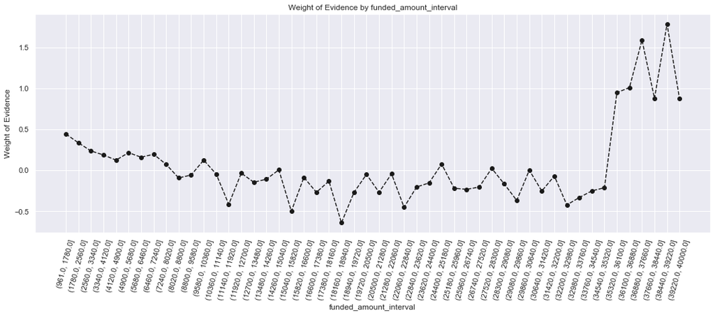

```python
lets_plot(df_funded, 75)
```

### Data Preprocessing / Continuous / Too_many_categories / months_since_earliest_credit_line_issued

```python
loan_data_inputs_prep['months_credit_interval'] = pd.cut(loan_data_inputs_prep['months_since_earliest_cr_line'], 100)
# loan_data_inputs_prep['months_since_earliest_cr_line'].unique()
```

> Let's now replace the string with a float. I'm not undoing the first error as it'll be a good marker.

> The problem is hence solved by removing the strings from the **fillna** function.

```python
# loan_data_inputs_prep['months_credit_interval'] = loan_data_inputs_prep['months_since_earliest_cr_line']
# loan_data_inputs_prep['months_credit_interval'] = pd.cut(loan_data_inputs_prep['months_since_earliest_cr_line'], 100)
# loan_data_inputs_prep['months_since_earliest_cr_line'].astype(float, copy=False)
loan_data_inputs_prep['months_credit_interval'] = pd.cut(loan_data_inputs_prep['months_since_earliest_cr_line'], 50)
loan_data_inputs_prep['months_credit_interval']
```

```
781974    (159.9, 172.2]
937737    (172.2, 184.5]
907828    (172.2, 184.5]
784628      (86.1, 98.4]
662460    (196.8, 209.1]
               ...
673443    (356.7, 369.0]
656736    (221.4, 233.7]
858501    (221.4, 233.7]
617079    (196.8, 209.1]
487559    (295.2, 307.5]
Name: months_credit_interval, Length: 209715, dtype: category
Categories (50, interval[float64]): [(-0.615, 12.3] < (12.3, 24.6] < (24.6, 36.9] < (36.9, 49.2] ... (565.8, 578.1] < (578.1, 590.4] < (590.4, 602.7] < (602.7, 615.0]]
```

```python
df_creditline = calculate_woe_continuous(loan_data_inputs_prep, 'months_credit_interval', loan_data_target_prep)
df_creditline
```

|  | months_credit_interval | n_obs | %good_per_category | %bad_per_category | prop_obs | n_good | n_bad | %good | %bad | woe | diff_prop_good | diff_woe | IV |
| --- | --- | --- | --- | --- | --- | --- | --- | --- | --- | --- | --- | --- | --- |
| 0 | (-0.615, 12.3] | 2 | 1.000000 | 0.000000 | 0.000010 | 2.0 | 0.0 | 0.000011 | 0.000000 | inf | NaN | NaN | inf |
| 1 | (12.3, 24.6] | 0 | NaN | NaN | 0.000000 | NaN | NaN | NaN | NaN | NaN | NaN | NaN | inf |
| 2 | (24.6, 36.9] | 0 | NaN | NaN | 0.000000 | NaN | NaN | NaN | NaN | NaN | NaN | NaN | inf |
| 3 | (36.9, 49.2] | 0 | NaN | NaN | 0.000000 | NaN | NaN | NaN | NaN | NaN | NaN | NaN | inf |
| 4 | (49.2, 61.5] | 205 | 0.956098 | 0.043902 | 0.000978 | 196.0 | 9.0 | 0.001079 | 0.000320 | 1.215181 | NaN | NaN | inf |
| 5 | (61.5, 73.8] | 1193 | 0.918692 | 0.081308 | 0.005689 | 1096.0 | 97.0 | 0.006035 | 0.003451 | 0.559003 | 0.004956 | 0.656179 | inf |
| 6 | (73.8, 86.1] | 2130 | 0.917371 | 0.082629 | 0.010157 | 1954.0 | 176.0 | 0.010760 | 0.006261 | 0.541441 | 0.004725 | 0.017562 | inf |
| 7 | (86.1, 98.4] | 2876 | 0.877955 | 0.122045 | 0.013714 | 2525.0 | 351.0 | 0.013904 | 0.012487 | 0.107502 | 0.003144 | 0.433940 | inf |
| 8 | (98.4, 110.7] | 3926 | 0.858889 | 0.141111 | 0.018721 | 3372.0 | 554.0 | 0.018568 | 0.019708 | -0.059612 | 0.004664 | 0.167113 | inf |
| 9 | (110.7, 123.0] | 4125 | 0.863515 | 0.136485 | 0.019670 | 3562.0 | 563.0 | 0.019614 | 0.020028 | -0.020911 | 0.001046 | 0.038701 | inf |
| 10 | (123.0, 135.3] | 3938 | 0.871254 | 0.128746 | 0.018778 | 3431.0 | 507.0 | 0.018893 | 0.018036 | 0.046387 | 0.000721 | 0.067298 | inf |
| 11 | (135.3, 147.6] | 5973 | 0.867403 | 0.132597 | 0.028482 | 5181.0 | 792.0 | 0.028529 | 0.028175 | 0.012483 | 0.009636 | 0.033904 | inf |
| 12 | (147.6, 159.9] | 9202 | 0.868181 | 0.131819 | 0.043879 | 7989.0 | 1213.0 | 0.043991 | 0.043152 | 0.019260 | 0.015462 | 0.006777 | inf |
| 13 | (159.9, 172.2] | 12786 | 0.865009 | 0.134991 | 0.060968 | 11060.0 | 1726.0 | 0.060901 | 0.061402 | -0.008180 | 0.016910 | 0.027441 | inf |
| 14 | (172.2, 184.5] | 13516 | 0.854913 | 0.145087 | 0.064449 | 11555.0 | 1961.0 | 0.063627 | 0.069762 | -0.092045 | 0.002726 | 0.083865 | inf |
| 15 | (184.5, 196.8] | 13954 | 0.847714 | 0.152286 | 0.066538 | 11829.0 | 2125.0 | 0.065136 | 0.075596 | -0.148926 | 0.001509 | 0.056881 | inf |
| 16 | (196.8, 209.1] | 14565 | 0.859801 | 0.140199 | 0.069451 | 12523.0 | 2042.0 | 0.068957 | 0.072643 | -0.052071 | 0.003821 | 0.096855 | inf |
| 17 | (209.1, 221.4] | 13121 | 0.855956 | 0.144044 | 0.062566 | 11231.0 | 1890.0 | 0.061843 | 0.067236 | -0.083608 | 0.007114 | 0.031536 | inf |
| 18 | (221.4, 233.7] | 12362 | 0.861188 | 0.138812 | 0.058947 | 10646.0 | 1716.0 | 0.058622 | 0.061046 | -0.040520 | 0.003221 | 0.043087 | inf |
| 19 | (233.7, 246.0] | 12498 | 0.863098 | 0.136902 | 0.059595 | 10787.0 | 1711.0 | 0.059398 | 0.060868 | -0.024445 | 0.000776 | 0.016075 | inf |
| 20 | (246.0, 258.3] | 9881 | 0.869042 | 0.130958 | 0.047116 | 8587.0 | 1294.0 | 0.047284 | 0.046033 | 0.026803 | 0.012114 | 0.051248 | inf |
| 21 | (258.3, 270.6] | 8493 | 0.869304 | 0.130696 | 0.040498 | 7383.0 | 1110.0 | 0.040654 | 0.039488 | 0.029111 | 0.006630 | 0.002309 | inf |
| 22 | (270.6, 282.9] | 7504 | 0.862074 | 0.137926 | 0.035782 | 6469.0 | 1035.0 | 0.035621 | 0.036820 | -0.033089 | 0.005033 | 0.062200 | inf |
| 23 | (282.9, 295.2] | 8225 | 0.873556 | 0.126444 | 0.039220 | 7185.0 | 1040.0 | 0.039564 | 0.036998 | 0.067066 | 0.003943 | 0.100155 | inf |
| 24 | (295.2, 307.5] | 6737 | 0.867003 | 0.132997 | 0.032125 | 5841.0 | 896.0 | 0.032163 | 0.031875 | 0.009008 | 0.007401 | 0.058058 | inf |
| 25 | (307.5, 319.8] | 5902 | 0.873263 | 0.126737 | 0.028143 | 5154.0 | 748.0 | 0.028380 | 0.026610 | 0.064417 | 0.003783 | 0.055409 | inf |
| 26 | (319.8, 332.1] | 4690 | 0.875053 | 0.124947 | 0.022364 | 4104.0 | 586.0 | 0.022598 | 0.020847 | 0.080689 | 0.005782 | 0.016272 | inf |
| 27 | (332.1, 344.4] | 3434 | 0.870414 | 0.129586 | 0.016375 | 2989.0 | 445.0 | 0.016459 | 0.015831 | 0.038911 | 0.006140 | 0.041778 | inf |
| 28 | (344.4, 356.7] | 3434 | 0.877402 | 0.122598 | 0.016375 | 3013.0 | 421.0 | 0.016591 | 0.014977 | 0.102350 | 0.000132 | 0.063439 | inf |
| 29 | (356.7, 369.0] | 3801 | 0.884504 | 0.115496 | 0.018125 | 3362.0 | 439.0 | 0.018513 | 0.015617 | 0.170083 | 0.001922 | 0.067733 | inf |
| 30 | (369.0, 381.3] | 3001 | 0.873042 | 0.126958 | 0.014310 | 2620.0 | 381.0 | 0.014427 | 0.013554 | 0.062422 | 0.004086 | 0.107662 | inf |
| 31 | (381.3, 393.6] | 2644 | 0.880862 | 0.119138 | 0.012608 | 2329.0 | 315.0 | 0.012825 | 0.011206 | 0.134913 | 0.001602 | 0.072491 | inf |
| 32 | (393.6, 405.9] | 2381 | 0.875682 | 0.124318 | 0.011354 | 2085.0 | 296.0 | 0.011481 | 0.010530 | 0.086456 | 0.001344 | 0.048457 | inf |
| 33 | (405.9, 418.2] | 2171 | 0.885767 | 0.114233 | 0.010352 | 1923.0 | 248.0 | 0.010589 | 0.008822 | 0.182504 | 0.000892 | 0.096048 | inf |
| 34 | (418.2, 430.5] | 1854 | 0.874865 | 0.125135 | 0.008841 | 1622.0 | 232.0 | 0.008931 | 0.008253 | 0.078969 | 0.001657 | 0.103535 | inf |
| 35 | (430.5, 442.8] | 1572 | 0.890585 | 0.109415 | 0.007496 | 1400.0 | 172.0 | 0.007709 | 0.006119 | 0.231024 | 0.001222 | 0.152055 | inf |
| 36 | (442.8, 455.1] | 1276 | 0.887147 | 0.112853 | 0.006084 | 1132.0 | 144.0 | 0.006233 | 0.005123 | 0.196219 | 0.001476 | 0.034805 | inf |
| 37 | (455.1, 467.4] | 970 | 0.878351 | 0.121649 | 0.004625 | 852.0 | 118.0 | 0.004692 | 0.004198 | 0.111193 | 0.001542 | 0.085026 | inf |
| 38 | (467.4, 479.7] | 684 | 0.875731 | 0.124269 | 0.003262 | 599.0 | 85.0 | 0.003298 | 0.003024 | 0.086902 | 0.001393 | 0.024292 | inf |
| 39 | (479.7, 492.0] | 728 | 0.869505 | 0.130495 | 0.003471 | 633.0 | 95.0 | 0.003486 | 0.003380 | 0.030885 | 0.000187 | 0.056017 | inf |
| 40 | (492.0, 504.3] | 694 | 0.861671 | 0.138329 | 0.003309 | 598.0 | 96.0 | 0.003293 | 0.003415 | -0.036466 | 0.000193 | 0.067351 | inf |
| 41 | (504.3, 516.6] | 625 | 0.881600 | 0.118400 | 0.002980 | 551.0 | 74.0 | 0.003034 | 0.002633 | 0.141961 | 0.000259 | 0.178427 | inf |
| 42 | (516.6, 528.9] | 447 | 0.843400 | 0.156600 | 0.002131 | 377.0 | 70.0 | 0.002076 | 0.002490 | -0.181959 | 0.000958 | 0.323920 | inf |
| 43 | (528.9, 541.2] | 413 | 0.869249 | 0.130751 | 0.001969 | 359.0 | 54.0 | 0.001977 | 0.001921 | 0.028630 | 0.000099 | 0.210588 | inf |
| 44 | (541.2, 553.5] | 330 | 0.872727 | 0.127273 | 0.001574 | 288.0 | 42.0 | 0.001586 | 0.001494 | 0.059582 | 0.000391 | 0.030953 | inf |
| 45 | (553.5, 565.8] | 274 | 0.879562 | 0.120438 | 0.001307 | 241.0 | 33.0 | 0.001327 | 0.001174 | 0.122581 | 0.000259 | 0.062999 | inf |
| 46 | (565.8, 578.1] | 271 | 0.845018 | 0.154982 | 0.001292 | 229.0 | 42.0 | 0.001261 | 0.001494 | -0.169656 | 0.000066 | 0.292237 | inf |
| 47 | (578.1, 590.4] | 147 | 0.877551 | 0.122449 | 0.000701 | 129.0 | 18.0 | 0.000710 | 0.000640 | 0.103732 | 0.000551 | 0.273388 | inf |
| 48 | (590.4, 602.7] | 145 | 0.875862 | 0.124138 | 0.000691 | 127.0 | 18.0 | 0.000699 | 0.000640 | 0.088107 | 0.000011 | 0.015625 | inf |
| 49 | (602.7, 615.0] | 615 | 0.788618 | 0.211382 | 0.002933 | 485.0 | 130.0 | 0.002671 | 0.004625 | -0.549094 | 0.001971 | 0.637201 | inf |

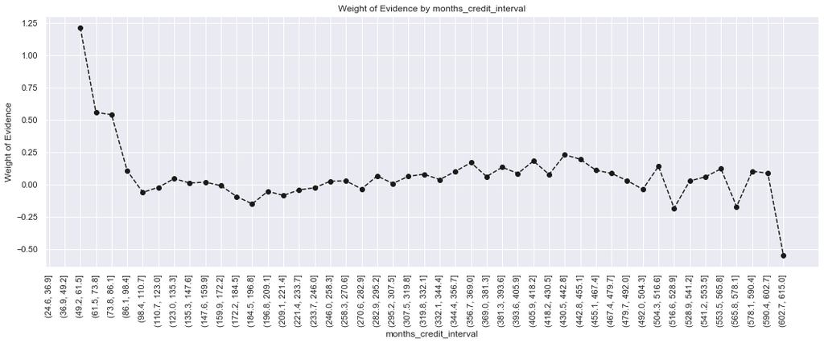

```python
lets_plot(df_creditline, 90)
```

```python
loan_data_inputs_prep['months_since_credit:<100']    = np.where((loan_data_inputs_prep['months_since_earliest_cr_line'] <= 100), 1, 0)
loan_data_inputs_prep['months_since_credit:100-300'] = np.where((loan_data_inputs_prep['months_since_earliest_cr_line'] > 100) & (loan_data_inputs_prep['months_since_earliest_cr_line'] <= 300), 1, 0)
loan_data_inputs_prep['months_since_credit:300-400'] = np.where((loan_data_inputs_prep['months_since_earliest_cr_line'] > 300) & (loan_data_inputs_prep['months_since_earliest_cr_line'] <= 400), 1, 0)
loan_data_inputs_prep['months_since_credit:400-500'] = np.where((loan_data_inputs_prep['months_since_earliest_cr_line'] > 400) & (loan_data_inputs_prep['months_since_earliest_cr_line'] <= 500), 1, 0)
loan_data_inputs_prep['months_since_credit:>500']    = np.where((loan_data_inputs_prep['months_since_earliest_cr_line'] > 100), 1, 0)
```

### Data Preprocessing / Continuous / Too_many_categories / installment

> Use pandas `df.nunique()` to count the unique values in the dataframe.

> This variable had many unique values, almost equaling to 6500+, hence interval was necessary.

```python
loan_data_inputs_prep['installment_interval'] = pd.cut(loan_data_inputs_prep['installment'], 50)
loan_data_inputs_prep['installment_interval']
```

```
781974    (660.211, 694.222]
937737    (116.042, 150.052]
907828    (422.137, 456.148]
784628    (626.201, 660.211]
662460    (456.148, 490.158]
                 ...
673443    (728.233, 762.243]
656736    (184.063, 218.074]
858501     (524.169, 558.18]
617079    (150.052, 184.063]
487559    (286.095, 320.105]
Name: installment_interval, Length: 209715, dtype: category
Categories (50, interval[float64]): [(12.309, 48.021] < (48.021, 82.031] < (82.031, 116.042] < (116.042, 150.052] ... (1578.498, 1612.508] < (1612.508, 1646.519] < (1646.519, 1680.529] < (1680.529, 1714.54]]
```

```python
df_installment = calculate_woe_continuous(loan_data_inputs_prep, 'installment_interval', loan_data_target_prep)
df_installment
```

|  | installment_interval | n_obs | %good_per_category | %bad_per_category | prop_obs | n_good | n_bad | %good | %bad | woe | diff_prop_good | diff_woe | IV |
| --- | --- | --- | --- | --- | --- | --- | --- | --- | --- | --- | --- | --- | --- |
| 0 | (12.309, 48.021] | 1384 | 0.914740 | 0.085260 | 0.006599 | 1266.0 | 118.0 | 0.006971 | 0.004198 | 0.507235 | NaN | NaN | inf |
| 1 | (48.021, 82.031] | 3656 | 0.903720 | 0.096280 | 0.017433 | 3304.0 | 352.0 | 0.018194 | 0.012522 | 0.373560 | 0.011222 | 0.133675 | inf |
| 2 | (82.031, 116.042] | 5631 | 0.901616 | 0.098384 | 0.026851 | 5077.0 | 554.0 | 0.027957 | 0.019708 | 0.349614 | 0.009763 | 0.023947 | inf |
| 3 | (116.042, 150.052] | 6062 | 0.884692 | 0.115308 | 0.028906 | 5363.0 | 699.0 | 0.029531 | 0.024867 | 0.171930 | 0.001575 | 0.177683 | inf |
| 4 | (150.052, 184.063] | 11884 | 0.892881 | 0.107119 | 0.056668 | 10611.0 | 1273.0 | 0.058430 | 0.045286 | 0.254817 | 0.028898 | 0.082887 | inf |
| 5 | (184.063, 218.074] | 11153 | 0.893213 | 0.106787 | 0.053182 | 9962.0 | 1191.0 | 0.054856 | 0.042369 | 0.258287 | 0.003574 | 0.003470 | inf |
| 6 | (218.074, 252.084] | 11887 | 0.886346 | 0.113654 | 0.056682 | 10536.0 | 1351.0 | 0.058017 | 0.048061 | 0.188255 | 0.003161 | 0.070032 | inf |
| 7 | (252.084, 286.095] | 14038 | 0.854110 | 0.145890 | 0.066939 | 11990.0 | 2048.0 | 0.066023 | 0.072857 | -0.098488 | 0.008006 | 0.286744 | inf |
| 8 | (286.095, 320.105] | 14589 | 0.875523 | 0.124477 | 0.069567 | 12773.0 | 1816.0 | 0.070335 | 0.064603 | 0.085000 | 0.004312 | 0.183488 | inf |
| 9 | (320.105, 354.116] | 15258 | 0.853454 | 0.146546 | 0.072757 | 13022.0 | 2236.0 | 0.071706 | 0.079545 | -0.103746 | 0.001371 | 0.188746 | inf |
| 10 | (354.116, 388.127] | 12341 | 0.862005 | 0.137995 | 0.058847 | 10638.0 | 1703.0 | 0.058578 | 0.060583 | -0.033657 | 0.013128 | 0.070089 | inf |
| 11 | (388.127, 422.137] | 9126 | 0.840894 | 0.159106 | 0.043517 | 7674.0 | 1452.0 | 0.042257 | 0.051654 | -0.200802 | 0.016321 | 0.167145 | inf |
| 12 | (422.137, 456.148] | 7196 | 0.850750 | 0.149250 | 0.034314 | 6122.0 | 1074.0 | 0.033711 | 0.038207 | -0.125199 | 0.008546 | 0.075603 | inf |
| 13 | (456.148, 490.158] | 10715 | 0.867476 | 0.132524 | 0.051094 | 9295.0 | 1420.0 | 0.051183 | 0.050516 | 0.013122 | 0.017472 | 0.138321 | inf |
| 14 | (490.158, 524.169] | 8918 | 0.849181 | 0.150819 | 0.042525 | 7573.0 | 1345.0 | 0.041701 | 0.047848 | -0.137502 | 0.009482 | 0.150624 | inf |
| 15 | (524.169, 558.18] | 7026 | 0.836180 | 0.163820 | 0.033503 | 5875.0 | 1151.0 | 0.032351 | 0.040946 | -0.235623 | 0.009350 | 0.098120 | inf |
| 16 | (558.18, 592.19] | 5903 | 0.840590 | 0.159410 | 0.028148 | 4962.0 | 941.0 | 0.027323 | 0.033476 | -0.203077 | 0.005027 | 0.032546 | inf |
| 17 | (592.19, 626.201] | 6091 | 0.875390 | 0.124610 | 0.029044 | 5332.0 | 759.0 | 0.029361 | 0.027001 | 0.083782 | 0.002037 | 0.286859 | inf |
| 18 | (626.201, 660.211] | 6115 | 0.865904 | 0.134096 | 0.029159 | 5295.0 | 820.0 | 0.029157 | 0.029171 | -0.000484 | 0.000204 | 0.084266 | inf |
| 19 | (660.211, 694.222] | 5244 | 0.843822 | 0.156178 | 0.025006 | 4425.0 | 819.0 | 0.024366 | 0.029136 | -0.178756 | 0.004791 | 0.178272 | inf |
| 20 | (694.222, 728.233] | 3217 | 0.850171 | 0.149829 | 0.015340 | 2735.0 | 482.0 | 0.015060 | 0.017147 | -0.129755 | 0.009306 | 0.049001 | inf |
| 21 | (728.233, 762.243] | 3900 | 0.871282 | 0.128718 | 0.018597 | 3398.0 | 502.0 | 0.018711 | 0.017858 | 0.046645 | 0.003651 | 0.176400 | inf |
| 22 | (762.243, 796.254] | 4503 | 0.874084 | 0.125916 | 0.021472 | 3936.0 | 567.0 | 0.021674 | 0.020171 | 0.071863 | 0.002963 | 0.025219 | inf |
| 23 | (796.254, 830.264] | 3021 | 0.858325 | 0.141675 | 0.014405 | 2593.0 | 428.0 | 0.014278 | 0.015226 | -0.064250 | 0.007395 | 0.136113 | inf |
| 24 | (830.264, 864.275] | 3020 | 0.861921 | 0.138079 | 0.014401 | 2603.0 | 417.0 | 0.014333 | 0.014835 | -0.034364 | 0.000055 | 0.029886 | inf |
| 25 | (864.275, 898.286] | 2494 | 0.845630 | 0.154370 | 0.011892 | 2109.0 | 385.0 | 0.011613 | 0.013696 | -0.164972 | 0.002720 | 0.130608 | inf |
| 26 | (898.286, 932.296] | 2119 | 0.861727 | 0.138273 | 0.010104 | 1826.0 | 293.0 | 0.010055 | 0.010423 | -0.035987 | 0.001558 | 0.128985 | inf |
| 27 | (932.296, 966.307] | 1648 | 0.847694 | 0.152306 | 0.007858 | 1397.0 | 251.0 | 0.007693 | 0.008929 | -0.149068 | 0.002362 | 0.113081 | inf |
| 28 | (966.307, 1000.317] | 1645 | 0.844377 | 0.155623 | 0.007844 | 1389.0 | 256.0 | 0.007649 | 0.009107 | -0.174536 | 0.000044 | 0.025468 | inf |
| 29 | (1000.317, 1034.328] | 1113 | 0.831087 | 0.168913 | 0.005307 | 925.0 | 188.0 | 0.005094 | 0.006688 | -0.272346 | 0.002555 | 0.097810 | inf |
| 30 | (1034.328, 1068.339] | 1035 | 0.854106 | 0.145894 | 0.004935 | 884.0 | 151.0 | 0.004868 | 0.005372 | -0.098520 | 0.000226 | 0.173825 | inf |
| 31 | (1068.339, 1102.349] | 1502 | 0.890146 | 0.109854 | 0.007162 | 1337.0 | 165.0 | 0.007362 | 0.005870 | 0.226541 | 0.002494 | 0.325061 | inf |
| 32 | (1102.349, 1136.36] | 1011 | 0.880317 | 0.119683 | 0.004821 | 890.0 | 121.0 | 0.004901 | 0.004305 | 0.129733 | 0.002461 | 0.096807 | inf |
| 33 | (1136.36, 1170.37] | 1031 | 0.845781 | 0.154219 | 0.004916 | 872.0 | 159.0 | 0.004802 | 0.005656 | -0.163812 | 0.000099 | 0.293546 | inf |
| 34 | (1170.37, 1204.381] | 1087 | 0.836247 | 0.163753 | 0.005183 | 909.0 | 178.0 | 0.005005 | 0.006332 | -0.235136 | 0.000204 | 0.071324 | inf |
| 35 | (1204.381, 1238.392] | 1065 | 0.891080 | 0.108920 | 0.005078 | 949.0 | 116.0 | 0.005226 | 0.004127 | 0.236121 | 0.000220 | 0.471257 | inf |
| 36 | (1238.392, 1272.402] | 911 | 0.854007 | 0.145993 | 0.004344 | 778.0 | 133.0 | 0.004284 | 0.004731 | -0.099320 | 0.000942 | 0.335441 | inf |
| 37 | (1272.402, 1306.413] | 528 | 0.837121 | 0.162879 | 0.002518 | 442.0 | 86.0 | 0.002434 | 0.003059 | -0.228735 | 0.001850 | 0.129415 | inf |
| 38 | (1306.413, 1340.423] | 266 | 0.853383 | 0.146617 | 0.001268 | 227.0 | 39.0 | 0.001250 | 0.001387 | -0.104309 | 0.001184 | 0.124426 | inf |
| 39 | (1340.423, 1374.434] | 164 | 0.835366 | 0.164634 | 0.000782 | 137.0 | 27.0 | 0.000754 | 0.000961 | -0.241554 | 0.000496 | 0.137244 | inf |
| 40 | (1374.434, 1408.445] | 96 | 0.812500 | 0.187500 | 0.000458 | 78.0 | 18.0 | 0.000430 | 0.000640 | -0.399361 | 0.000325 | 0.157807 | inf |
| 41 | (1408.445, 1442.455] | 34 | 0.852941 | 0.147059 | 0.000162 | 29.0 | 5.0 | 0.000160 | 0.000178 | -0.107840 | 0.000270 | 0.291521 | inf |
| 42 | (1442.455, 1476.466] | 30 | 0.766667 | 0.233333 | 0.000143 | 23.0 | 7.0 | 0.000127 | 0.000249 | -0.676114 | 0.000033 | 0.568274 | inf |
| 43 | (1476.466, 1510.476] | 41 | 0.682927 | 0.317073 | 0.000196 | 28.0 | 13.0 | 0.000154 | 0.000462 | -1.098442 | 0.000028 | 0.422329 | inf |
| 44 | (1510.476, 1544.487] | 1 | 1.000000 | 0.000000 | 0.000005 | 1.0 | 0.0 | 0.000006 | 0.000000 | inf | 0.000149 | inf | inf |
| 45 | (1544.487, 1578.498] | 6 | 0.833333 | 0.166667 | 0.000029 | 5.0 | 1.0 | 0.000028 | 0.000036 | -0.256260 | 0.000022 | inf | inf |
| 46 | (1578.498, 1612.508] | 3 | 1.000000 | 0.000000 | 0.000014 | 3.0 | 0.0 | 0.000017 | 0.000000 | inf | 0.000011 | inf | inf |
| 47 | (1612.508, 1646.519] | 2 | 1.000000 | 0.000000 | 0.000010 | 2.0 | 0.0 | 0.000011 | 0.000000 | inf | 0.000006 | NaN | inf |
| 48 | (1646.519, 1680.529] | 0 | NaN | NaN | 0.000000 | NaN | NaN | NaN | NaN | NaN | NaN | NaN | inf |
| 49 | (1680.529, 1714.54] | 3 | 1.000000 | 0.000000 | 0.000014 | 3.0 | 0.0 | 0.000017 | 0.000000 | inf | NaN | NaN | inf |

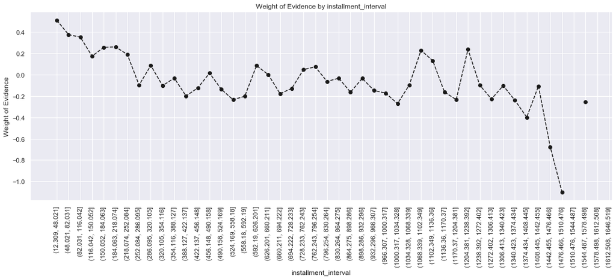

```python
lets_plot(df_installment, 90)
```

> Remember to use **&** in the middle of condition.

> Also use **individual ()** in the condition for each statement.

```python
# considering the graph and the chart, dividing it into 5 categories is well sufficient.

loan_data_inputs_prep['installments:<253.478']       = np.where((loan_data_inputs_prep['installment'] <= 253.478), 1, 0)
loan_data_inputs_prep['installments:253.478-594.49'] = np.where((loan_data_inputs_prep['installment'] > 253.478) & (loan_data_inputs_prep['installment'] <= 594.49), 1, 0)
loan_data_inputs_prep['installments:594.49-867.3']   = np.where((loan_data_inputs_prep['installment'] > 594.49) & (loan_data_inputs_prep['installment'] <= 867.3), 1, 0)
loan_data_inputs_prep['installments:867.3-1208.312'] = np.where((loan_data_inputs_prep['installment'] > 867.3) & (loan_data_inputs_prep['installment'] <= 1208.312), 1, 0)
loan_data_inputs_prep['installments:>1208.312']      = np.where((loan_data_inputs_prep['installment'] > 1208.312), 1, 0)
```

### Data Preprocessing / Continuous / Too_many_categories / delinq_2yrs

> As observed the graph doesn't follow any trend and is also random, hence discarding it as a predictor

```python
df_delinq = calculate_woe_continuous(loan_data_inputs_prep, 'delinq_2yrs', loan_data_target_prep)
df_delinq
```

|  | delinq_2yrs | n_obs | %good_per_category | %bad_per_category | prop_obs | n_good | n_bad | %good | %bad | woe | diff_prop_good | diff_woe | IV |
| --- | --- | --- | --- | --- | --- | --- | --- | --- | --- | --- | --- | --- | --- |
| 0 | 0.0 | 169181 | 0.869607 | 0.130393 | 0.806719 | 147121.0 | 22060.0 | 0.810115 | 0.784774 | 0.031781 | NaN | NaN | inf |
| 1 | 1.0 | 26786 | 0.853692 | 0.146308 | 0.127726 | 22867.0 | 3919.0 | 0.125916 | 0.139417 | -0.101850 | 0.684199 | 0.133631 | inf |
| 2 | 2.0 | 7954 | 0.847372 | 0.152628 | 0.037928 | 6740.0 | 1214.0 | 0.037114 | 0.043187 | -0.151569 | 0.088803 | 0.049719 | inf |
| 3 | 3.0 | 2837 | 0.839267 | 0.160733 | 0.013528 | 2381.0 | 456.0 | 0.013111 | 0.016222 | -0.212926 | 0.024003 | 0.061356 | inf |
| 4 | 4.0 | 1285 | 0.843580 | 0.156420 | 0.006127 | 1084.0 | 201.0 | 0.005969 | 0.007150 | -0.180600 | 0.007142 | 0.032325 | inf |
| 5 | 5.0 | 655 | 0.850382 | 0.149618 | 0.003123 | 557.0 | 98.0 | 0.003067 | 0.003486 | -0.128111 | 0.002902 | 0.052489 | inf |
| 6 | 6.0 | 383 | 0.838120 | 0.161880 | 0.001826 | 321.0 | 62.0 | 0.001768 | 0.002206 | -0.221402 | 0.001300 | 0.093291 | inf |
| 7 | 7.0 | 205 | 0.843902 | 0.156098 | 0.000978 | 173.0 | 32.0 | 0.000953 | 0.001138 | -0.178153 | 0.000815 | 0.043249 | inf |
| 8 | 8.0 | 154 | 0.850649 | 0.149351 | 0.000734 | 131.0 | 23.0 | 0.000721 | 0.000818 | -0.126006 | 0.000231 | 0.052147 | inf |
| 9 | 9.0 | 82 | 0.804878 | 0.195122 | 0.000391 | 66.0 | 16.0 | 0.000363 | 0.000569 | -0.448643 | 0.000358 | 0.322637 | inf |
| 10 | 10.0 | 58 | 0.862069 | 0.137931 | 0.000277 | 50.0 | 8.0 | 0.000275 | 0.000285 | -0.033127 | 0.000088 | 0.415515 | inf |
| 11 | 11.0 | 41 | 0.878049 | 0.121951 | 0.000196 | 36.0 | 5.0 | 0.000198 | 0.000178 | 0.108372 | 0.000077 | 0.141500 | inf |
| 12 | 12.0 | 30 | 0.766667 | 0.233333 | 0.000143 | 23.0 | 7.0 | 0.000127 | 0.000249 | -0.676125 | 0.000072 | 0.784497 | inf |
| 13 | 13.0 | 15 | 0.933333 | 0.066667 | 0.000072 | 14.0 | 1.0 | 0.000077 | 0.000036 | 0.773349 | 0.000050 | 1.449473 | inf |
| 14 | 14.0 | 19 | 0.736842 | 0.263158 | 0.000091 | 14.0 | 5.0 | 0.000077 | 0.000178 | -0.836089 | 0.000000 | 1.609438 | inf |
| 15 | 15.0 | 8 | 0.875000 | 0.125000 | 0.000038 | 7.0 | 1.0 | 0.000039 | 0.000036 | 0.080202 | 0.000039 | 0.916291 | inf |
| 16 | 16.0 | 11 | 1.000000 | 0.000000 | 0.000052 | 11.0 | 0.0 | 0.000061 | 0.000000 | inf | 0.000022 | inf | inf |
| 17 | 17.0 | 2 | 1.000000 | 0.000000 | 0.000010 | 2.0 | 0.0 | 0.000011 | 0.000000 | inf | 0.000050 | NaN | inf |
| 18 | 18.0 | 2 | 0.500000 | 0.500000 | 0.000010 | 1.0 | 1.0 | 0.000006 | 0.000036 | -1.865709 | 0.000006 | inf | inf |
| 19 | 19.0 | 3 | 0.666667 | 0.333333 | 0.000014 | 2.0 | 1.0 | 0.000011 | 0.000036 | -1.172561 | 0.000006 | 0.693147 | inf |
| 20 | 21.0 | 1 | 1.000000 | 0.000000 | 0.000005 | 1.0 | 0.0 | 0.000006 | 0.000000 | inf | 0.000006 | inf | inf |
| 21 | 22.0 | 1 | 1.000000 | 0.000000 | 0.000005 | 1.0 | 0.0 | 0.000006 | 0.000000 | inf | 0.000000 | NaN | inf |
| 22 | 24.0 | 1 | 1.000000 | 0.000000 | 0.000005 | 1.0 | 0.0 | 0.000006 | 0.000000 | inf | 0.000000 | NaN | inf |
| 23 | 26.0 | 1 | 1.000000 | 0.000000 | 0.000005 | 1.0 | 0.0 | 0.000006 | 0.000000 | inf | 0.000000 | NaN | inf |

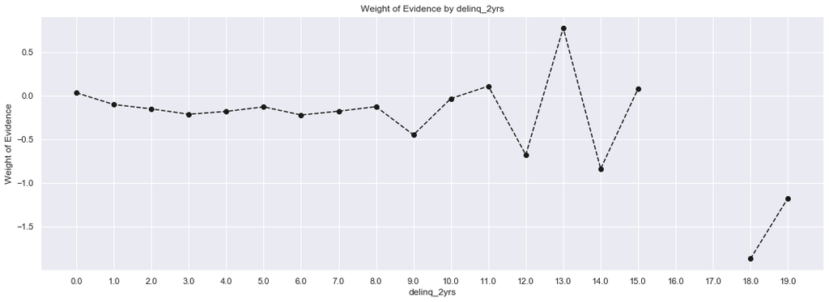

```python
lets_plot(df_delinq)
```

### Data Preprocessing / Continuous / Too_many_categories / inq_last_6mnths

> We can see that more than 60% of observation is concentrated towards teh first category, hence we'll divide it into three cats.

```python
df_inquiry = calculate_woe_continuous(loan_data_inputs_prep, 'inq_last_6mths', loan_data_target_prep)
df_inquiry
```

|  | inq_last_6mths | n_obs | %good_per_category | %bad_per_category | prop_obs | n_good | n_bad | %good | %bad | woe | diff_prop_good | diff_woe | IV |
| --- | --- | --- | --- | --- | --- | --- | --- | --- | --- | --- | --- | --- | --- |
| 0 | 0.0 | 132823 | 0.886586 | 0.113414 | 0.633350 | 117759.0 | 15064.0 | 0.648435 | 0.535895 | 0.190624 | NaN | NaN | 0.067291 |
| 1 | 1.0 | 53279 | 0.846150 | 0.153850 | 0.254054 | 45082.0 | 8197.0 | 0.248242 | 0.291604 | -0.160994 | 0.400193 | 0.351618 | 0.067291 |
| 2 | 2.0 | 16551 | 0.809619 | 0.190381 | 0.078921 | 13400.0 | 3151.0 | 0.073787 | 0.112095 | -0.418174 | 0.174456 | 0.257180 | 0.067291 |
| 3 | 3.0 | 5295 | 0.772427 | 0.227573 | 0.025249 | 4090.0 | 1205.0 | 0.022521 | 0.042867 | -0.643643 | 0.051265 | 0.225469 | 0.067291 |
| 4 | 4.0 | 1281 | 0.725995 | 0.274005 | 0.006108 | 930.0 | 351.0 | 0.005121 | 0.012487 | -0.891310 | 0.017400 | 0.247667 | 0.067291 |
| 5 | 5.0 | 476 | 0.703782 | 0.296218 | 0.002270 | 335.0 | 141.0 | 0.001845 | 0.005016 | -1.000338 | 0.003276 | 0.109028 | 0.067291 |
| 6 | 6.0 | 10 | 0.900000 | 0.100000 | 0.000048 | 9.0 | 1.0 | 0.000050 | 0.000036 | 0.331516 | 0.001795 | 1.331854 | 0.067291 |

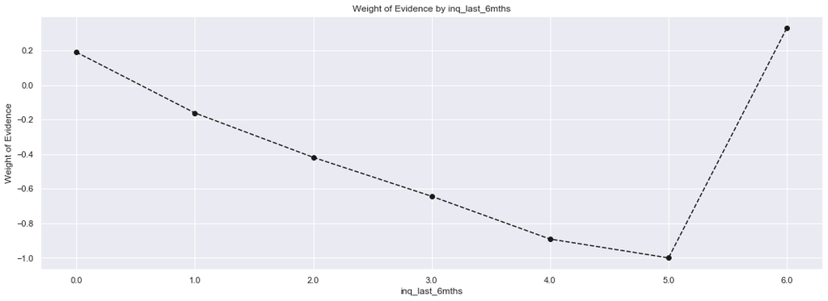

```python
lets_plot(df_inquiry)
```

```python
loan_data_inputs_prep['inquiry:0']  = np.where((loan_data_inputs_prep['inq_last_6mths'] == 0.0), 1, 0)
loan_data_inputs_prep['inquiry:1']  = np.where((loan_data_inputs_prep['inq_last_6mths'] == 1.0), 1, 0)
loan_data_inputs_prep['inquiry:>1'] = np.where((loan_data_inputs_prep['inq_last_6mths'] > 1.0), 1, 0)
```

### Data Preprocessing / Continuous / Too_many_categories / open_acc

```python
loan_data_inputs_prep['open_acc_interval'] = pd.cut(loan_data_inputs_prep['open_acc'], 50)
loan_data_inputs_prep['open_acc_interval']
```

```
781974      (8.04, 9.38]
937737      (8.04, 9.38]
907828      (8.04, 9.38]
784628     (12.06, 13.4]
662460     (13.4, 14.74]
               ...
673443    (21.44, 22.78]
656736      (8.04, 9.38]
858501    (10.72, 12.06]
617079     (9.38, 10.72]
487559    (14.74, 16.08]
Name: open_acc_interval, Length: 209715, dtype: category
Categories (50, interval[float64]): [(-0.067, 1.34] < (1.34, 2.68] < (2.68, 4.02] < (4.02, 5.36] ... (61.64, 62.98] < (62.98, 64.32] < (64.32, 65.66] < (65.66, 67.0]]
```

```python
df_openacc = calculate_woe_continuous(loan_data_inputs_prep, 'open_acc_interval', loan_data_target_prep)
df_openacc
```

|  | open_acc_interval | n_obs | %good_per_category | %bad_per_category | prop_obs | n_good | n_bad | %good | %bad | woe | diff_prop_good | diff_woe | IV |
| --- | --- | --- | --- | --- | --- | --- | --- | --- | --- | --- | --- | --- | --- |
| 0 | (-0.067, 1.34] | 157 | 0.866242 | 0.133758 | 0.000749 | 136.0 | 21.0 | 0.000749 | 0.000747 | 0.002424 | NaN | NaN | inf |
| 1 | (1.34, 2.68] | 894 | 0.862416 | 0.137584 | 0.004263 | 771.0 | 123.0 | 0.004245 | 0.004376 | -0.030205 | 0.003497 | 0.032628 | inf |
| 2 | (2.68, 4.02] | 9022 | 0.891266 | 0.108734 | 0.043020 | 8041.0 | 981.0 | 0.044277 | 0.034899 | 0.238028 | 0.040032 | 0.268232 | inf |
| 3 | (4.02, 5.36] | 9932 | 0.881998 | 0.118002 | 0.047360 | 8760.0 | 1172.0 | 0.048237 | 0.041693 | 0.145776 | 0.003959 | 0.092252 | inf |
| 4 | (5.36, 6.7] | 13268 | 0.871872 | 0.128128 | 0.063267 | 11568.0 | 1700.0 | 0.063699 | 0.060477 | 0.051906 | 0.015462 | 0.093870 | inf |
| 5 | (6.7, 8.04] | 32699 | 0.874797 | 0.125203 | 0.155921 | 28605.0 | 4094.0 | 0.157512 | 0.145642 | 0.078350 | 0.093813 | 0.026445 | inf |
| 6 | (8.04, 9.38] | 17654 | 0.870228 | 0.129772 | 0.084181 | 15363.0 | 2291.0 | 0.084596 | 0.081501 | 0.037265 | 0.072916 | 0.041085 | inf |
| 7 | (9.38, 10.72] | 17340 | 0.866724 | 0.133276 | 0.082684 | 15029.0 | 2311.0 | 0.082757 | 0.082213 | 0.006593 | 0.001839 | 0.030672 | inf |
| 8 | (10.72, 12.06] | 30694 | 0.861439 | 0.138561 | 0.146361 | 26441.0 | 4253.0 | 0.145596 | 0.151298 | -0.038417 | 0.062840 | 0.045010 | inf |
| 9 | (12.06, 13.4] | 12751 | 0.857658 | 0.142342 | 0.060802 | 10936.0 | 1815.0 | 0.060219 | 0.064568 | -0.069734 | 0.085378 | 0.031317 | inf |
| 10 | (13.4, 14.74] | 11083 | 0.861319 | 0.138681 | 0.052848 | 9546.0 | 1537.0 | 0.052565 | 0.054678 | -0.039419 | 0.007654 | 0.030315 | inf |
| 11 | (14.74, 16.08] | 17311 | 0.860147 | 0.139853 | 0.082545 | 14890.0 | 2421.0 | 0.081991 | 0.086126 | -0.049199 | 0.029427 | 0.009781 | inf |
| 12 | (16.08, 17.42] | 6599 | 0.863464 | 0.136536 | 0.031467 | 5698.0 | 901.0 | 0.031376 | 0.032053 | -0.021343 | 0.050615 | 0.027856 | inf |
| 13 | (17.42, 18.76] | 5468 | 0.855523 | 0.144477 | 0.026073 | 4678.0 | 790.0 | 0.025759 | 0.028104 | -0.087116 | 0.005617 | 0.065772 | inf |
| 14 | (18.76, 20.1] | 8397 | 0.860545 | 0.139455 | 0.040040 | 7226.0 | 1171.0 | 0.039790 | 0.041658 | -0.045881 | 0.014030 | 0.041235 | inf |
| 15 | (20.1, 21.44] | 3115 | 0.852327 | 0.147673 | 0.014853 | 2655.0 | 460.0 | 0.014620 | 0.016364 | -0.112735 | 0.025170 | 0.066854 | inf |
| 16 | (21.44, 22.78] | 2556 | 0.850548 | 0.149452 | 0.012188 | 2174.0 | 382.0 | 0.011971 | 0.013589 | -0.126805 | 0.002649 | 0.014070 | inf |
| 17 | (22.78, 24.12] | 3739 | 0.840599 | 0.159401 | 0.017829 | 3143.0 | 596.0 | 0.017307 | 0.021202 | -0.203016 | 0.005336 | 0.076211 | inf |
| 18 | (24.12, 25.46] | 1330 | 0.859398 | 0.140602 | 0.006342 | 1143.0 | 187.0 | 0.006294 | 0.006652 | -0.055406 | 0.011013 | 0.147611 | inf |
| 19 | (25.46, 26.8] | 1101 | 0.846503 | 0.153497 | 0.005250 | 932.0 | 169.0 | 0.005132 | 0.006012 | -0.158275 | 0.001162 | 0.102869 | inf |
| 20 | (26.8, 28.14] | 1659 | 0.839060 | 0.160940 | 0.007911 | 1392.0 | 267.0 | 0.007665 | 0.009498 | -0.214460 | 0.002533 | 0.056186 | inf |
| 21 | (28.14, 29.48] | 573 | 0.853403 | 0.146597 | 0.002732 | 489.0 | 84.0 | 0.002693 | 0.002988 | -0.104163 | 0.004972 | 0.110298 | inf |
| 22 | (29.48, 30.82] | 447 | 0.816555 | 0.183445 | 0.002131 | 365.0 | 82.0 | 0.002010 | 0.002917 | -0.372531 | 0.000683 | 0.268368 | inf |
| 23 | (30.82, 32.16] | 670 | 0.840299 | 0.159701 | 0.003195 | 563.0 | 107.0 | 0.003100 | 0.003806 | -0.205258 | 0.001090 | 0.167273 | inf |
| 24 | (32.16, 33.5] | 251 | 0.856574 | 0.143426 | 0.001197 | 215.0 | 36.0 | 0.001184 | 0.001281 | -0.078590 | 0.001916 | 0.126668 | inf |
| 25 | (33.5, 34.84] | 191 | 0.858639 | 0.141361 | 0.000911 | 164.0 | 27.0 | 0.000903 | 0.000961 | -0.061679 | 0.000281 | 0.016910 | inf |
| 26 | (34.84, 36.18] | 284 | 0.880282 | 0.119718 | 0.001354 | 250.0 | 34.0 | 0.001377 | 0.001210 | 0.129392 | 0.000474 | 0.191071 | inf |
| 27 | (36.18, 37.52] | 75 | 0.813333 | 0.186667 | 0.000358 | 61.0 | 14.0 | 0.000336 | 0.000498 | -0.393892 | 0.001041 | 0.523284 | inf |
| 28 | (37.52, 38.86] | 71 | 0.859155 | 0.140845 | 0.000339 | 61.0 | 10.0 | 0.000336 | 0.000356 | -0.057420 | 0.000000 | 0.336472 | inf |
| 29 | (38.86, 40.2] | 114 | 0.780702 | 0.219298 | 0.000544 | 89.0 | 25.0 | 0.000490 | 0.000889 | -0.595948 | 0.000154 | 0.538528 | inf |
| 30 | (40.2, 41.54] | 56 | 0.910714 | 0.089286 | 0.000267 | 51.0 | 5.0 | 0.000281 | 0.000178 | 0.456679 | 0.000209 | 1.052627 | inf |
| 31 | (41.54, 42.88] | 41 | 0.780488 | 0.219512 | 0.000196 | 32.0 | 9.0 | 0.000176 | 0.000320 | -0.597197 | 0.000105 | 1.053876 | inf |
| 32 | (42.88, 44.22] | 56 | 0.732143 | 0.267857 | 0.000267 | 41.0 | 15.0 | 0.000226 | 0.000534 | -0.860187 | 0.000050 | 0.262989 | inf |
| 33 | (44.22, 45.56] | 15 | 0.866667 | 0.133333 | 0.000072 | 13.0 | 2.0 | 0.000072 | 0.000071 | 0.006094 | 0.000154 | 0.866280 | inf |
| 34 | (45.56, 46.9] | 14 | 0.642857 | 0.357143 | 0.000067 | 9.0 | 5.0 | 0.000050 | 0.000178 | -1.277922 | 0.000022 | 1.284016 | inf |
| 35 | (46.9, 48.24] | 25 | 0.840000 | 0.160000 | 0.000119 | 21.0 | 4.0 | 0.000116 | 0.000142 | -0.207481 | 0.000066 | 1.070441 | inf |
| 36 | (48.24, 49.58] | 6 | 0.666667 | 0.333333 | 0.000029 | 4.0 | 2.0 | 0.000022 | 0.000071 | -1.172561 | 0.000094 | 0.965081 | inf |
| 37 | (49.58, 50.92] | 6 | 0.833333 | 0.166667 | 0.000029 | 5.0 | 1.0 | 0.000028 | 0.000036 | -0.256271 | 0.000006 | 0.916291 | inf |
| 38 | (50.92, 52.26] | 21 | 0.904762 | 0.095238 | 0.000100 | 19.0 | 2.0 | 0.000105 | 0.000071 | 0.385583 | 0.000077 | 0.641854 | inf |
| 39 | (52.26, 53.6] | 8 | 0.625000 | 0.375000 | 0.000038 | 5.0 | 3.0 | 0.000028 | 0.000107 | -1.354883 | 0.000077 | 1.740466 | inf |
| 40 | (53.6, 54.94] | 3 | 1.000000 | 0.000000 | 0.000014 | 3.0 | 0.0 | 0.000017 | 0.000000 | inf | 0.000011 | inf | inf |
| 41 | (54.94, 56.28] | 8 | 1.000000 | 0.000000 | 0.000038 | 8.0 | 0.0 | 0.000044 | 0.000000 | inf | 0.000028 | NaN | inf |
| 42 | (56.28, 57.62] | 0 | NaN | NaN | 0.000000 | NaN | NaN | NaN | NaN | NaN | NaN | NaN | inf |
| 43 | (57.62, 58.96] | 0 | NaN | NaN | 0.000000 | NaN | NaN | NaN | NaN | NaN | NaN | NaN | inf |
| 44 | (58.96, 60.3] | 2 | 1.000000 | 0.000000 | 0.000010 | 2.0 | 0.0 | 0.000011 | 0.000000 | inf | NaN | NaN | inf |
| 45 | (60.3, 61.64] | 3 | 1.000000 | 0.000000 | 0.000014 | 3.0 | 0.0 | 0.000017 | 0.000000 | inf | 0.000006 | NaN | inf |
| 46 | (61.64, 62.98] | 0 | NaN | NaN | 0.000000 | NaN | NaN | NaN | NaN | NaN | NaN | NaN | inf |
| 47 | (62.98, 64.32] | 3 | 1.000000 | 0.000000 | 0.000014 | 3.0 | 0.0 | 0.000017 | 0.000000 | inf | NaN | NaN | inf |
| 48 | (64.32, 65.66] | 0 | NaN | NaN | 0.000000 | NaN | NaN | NaN | NaN | NaN | NaN | NaN | inf |
| 49 | (65.66, 67.0] | 3 | 0.666667 | 0.333333 | 0.000014 | 2.0 | 1.0 | 0.000011 | 0.000036 | -1.172561 | NaN | NaN | inf |

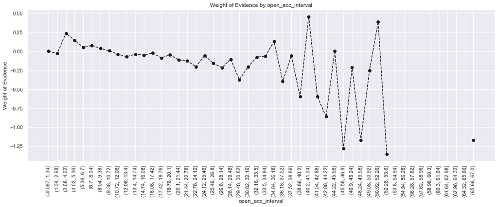

```python
lets_plot(df_openacc, 90)
```

```python
loan_data_inputs_prep['openacc:<5']      = np.where((loan_data_inputs_prep['open_acc'] <= 5), 1, 0)
loan_data_inputs_prep['openacc:5-7.5']   = np.where((loan_data_inputs_prep['open_acc'] > 5) & (loan_data_inputs_prep['open_acc'] <= 7.5), 1, 0)
loan_data_inputs_prep['openacc:7.5-10']  = np.where((loan_data_inputs_prep['open_acc'] > 7.5) & (loan_data_inputs_prep['open_acc'] <= 10), 1, 0)
loan_data_inputs_prep['openacc:10-12.5'] = np.where((loan_data_inputs_prep['open_acc'] > 10) & (loan_data_inputs_prep['open_acc'] <= 12.5), 1, 0)
loan_data_inputs_prep['openacc:12.5-15'] = np.where((loan_data_inputs_prep['open_acc'] > 12.5) & (loan_data_inputs_prep['open_acc'] <= 15), 1, 0)
loan_data_inputs_prep['openacc:15-25']   = np.where((loan_data_inputs_prep['open_acc'] > 15) & (loan_data_inputs_prep['open_acc'] <= 25), 1, 0)
loan_data_inputs_prep['openacc:25-35']   = np.where((loan_data_inputs_prep['open_acc'] > 25) & (loan_data_inputs_prep['open_acc'] <= 35), 1, 0)
loan_data_inputs_prep['openacc:>35']     = np.where((loan_data_inputs_prep['open_acc'] > 35), 1, 0)
```

### Data Preprocessing / Continuous / Too_many_categories / pub_rec

> Not including it, since the pattern is **random and broken.**

> Fixed my mistake thinking that **random and broken** cannot make a good predictor, but I can't see any good about it.

```python
loan_data_inputs_prep['pub_rec'].nunique()
```

```
22
```

```python
df_pubrec = calculate_woe_continuous(loan_data_inputs_prep, 'pub_rec', loan_data_target_prep)
df_pubrec
```

|  | pub_rec | n_obs | %good_per_category | %bad_per_category | prop_obs | n_good | n_bad | %good | %bad | woe | diff_prop_good | diff_woe | IV |
| --- | --- | --- | --- | --- | --- | --- | --- | --- | --- | --- | --- | --- | --- |
| 0 | 0.0 | 174962 | 0.872710 | 0.127290 | 0.834285 | 152691.0 | 22271.0 | 0.840786 | 0.792280 | 0.059422 | NaN | NaN | inf |
| 1 | 1.0 | 29163 | 0.834448 | 0.165552 | 0.139060 | 24335.0 | 4828.0 | 0.134000 | 0.171754 | -0.248225 | 0.706787 | 0.307648 | inf |
| 2 | 2.0 | 3590 | 0.818663 | 0.181337 | 0.017118 | 2939.0 | 651.0 | 0.016183 | 0.023159 | -0.358394 | 0.117816 | 0.110168 | inf |
| 3 | 3.0 | 1175 | 0.817872 | 0.182128 | 0.005603 | 961.0 | 214.0 | 0.005292 | 0.007613 | -0.363710 | 0.010892 | 0.005317 | inf |
| 4 | 4.0 | 425 | 0.809412 | 0.190588 | 0.002027 | 344.0 | 81.0 | 0.001894 | 0.002882 | -0.419516 | 0.003397 | 0.055806 | inf |
| 5 | 5.0 | 189 | 0.846561 | 0.153439 | 0.000901 | 160.0 | 29.0 | 0.000881 | 0.001032 | -0.157831 | 0.001013 | 0.261685 | inf |
| 6 | 6.0 | 97 | 0.835052 | 0.164948 | 0.000463 | 81.0 | 16.0 | 0.000446 | 0.000569 | -0.243848 | 0.000435 | 0.086018 | inf |
| 7 | 7.0 | 34 | 0.852941 | 0.147059 | 0.000162 | 29.0 | 5.0 | 0.000160 | 0.000178 | -0.107851 | 0.000286 | 0.135997 | inf |
| 8 | 8.0 | 26 | 0.769231 | 0.230769 | 0.000124 | 20.0 | 6.0 | 0.000110 | 0.000213 | -0.661736 | 0.000050 | 0.553885 | inf |
| 9 | 9.0 | 16 | 0.937500 | 0.062500 | 0.000076 | 15.0 | 1.0 | 0.000083 | 0.000036 | 0.842342 | 0.000028 | 1.504077 | inf |
| 10 | 10.0 | 8 | 1.000000 | 0.000000 | 0.000038 | 8.0 | 0.0 | 0.000044 | 0.000000 | inf | 0.000039 | inf | inf |
| 11 | 11.0 | 10 | 0.800000 | 0.200000 | 0.000048 | 8.0 | 2.0 | 0.000044 | 0.000071 | -0.479414 | 0.000000 | inf | inf |
| 12 | 12.0 | 7 | 0.571429 | 0.428571 | 0.000033 | 4.0 | 3.0 | 0.000022 | 0.000107 | -1.578027 | 0.000022 | 1.098612 | inf |
| 13 | 13.0 | 2 | 1.000000 | 0.000000 | 0.000010 | 2.0 | 0.0 | 0.000011 | 0.000000 | inf | 0.000011 | inf | inf |
| 14 | 14.0 | 2 | 0.500000 | 0.500000 | 0.000010 | 1.0 | 1.0 | 0.000006 | 0.000036 | -1.865709 | 0.000006 | inf | inf |
| 15 | 15.0 | 1 | 1.000000 | 0.000000 | 0.000005 | 1.0 | 0.0 | 0.000006 | 0.000000 | inf | 0.000000 | inf | inf |
| 16 | 16.0 | 2 | 0.500000 | 0.500000 | 0.000010 | 1.0 | 1.0 | 0.000006 | 0.000036 | -1.865709 | 0.000000 | inf | inf |
| 17 | 18.0 | 1 | 1.000000 | 0.000000 | 0.000005 | 1.0 | 0.0 | 0.000006 | 0.000000 | inf | 0.000000 | inf | inf |
| 18 | 21.0 | 2 | 1.000000 | 0.000000 | 0.000010 | 2.0 | 0.0 | 0.000011 | 0.000000 | inf | 0.000006 | NaN | inf |
| 19 | 28.0 | 1 | 1.000000 | 0.000000 | 0.000005 | 1.0 | 0.0 | 0.000006 | 0.000000 | inf | 0.000006 | NaN | inf |
| 20 | 44.0 | 1 | 0.000000 | 1.000000 | 0.000005 | 0.0 | 1.0 | 0.000000 | 0.000036 | -inf | 0.000006 | inf | inf |
| 21 | 49.0 | 1 | 1.000000 | 0.000000 | 0.000005 | 1.0 | 0.0 | 0.000006 | 0.000000 | inf | 0.000006 | inf | inf |

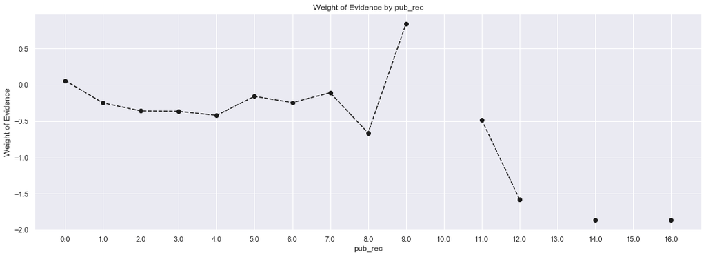

```python
lets_plot(df_pubrec)
```

```python
loan_data_inputs_prep['public_rec:0']  = np.where((loan_data_inputs_prep['pub_rec'] == 0), 1, 0)
loan_data_inputs_prep['public_rec:1']  = np.where((loan_data_inputs_prep['pub_rec'] == 1), 1, 0)
loan_data_inputs_prep['public_rec:>1'] = np.where((loan_data_inputs_prep['pub_rec'] > 1), 1, 0)
```

### Data Preprocessing / Continuous / Too_many_categories / total_acc

> I don't know whether to include that, because the thing though has a **linear trend initially** it gets **random and distorted.** Hence I'm omitting it for the **greater good.**

> The point where I was mistaken was that the distorted graph is because of the low number of observations. Hence including this column too.

```python
loan_data_inputs_prep['total_acc_interval'] = pd.cut(loan_data_inputs_prep['total_acc'], 50)
loan_data_inputs_prep['total_acc_interval']
```

```
781974    (16.0, 19.2]
937737    (25.6, 28.8]
907828    (16.0, 19.2]
784628    (16.0, 19.2]
662460    (28.8, 32.0]
              ...
673443    (28.8, 32.0]
656736    (25.6, 28.8]
858501    (22.4, 25.6]
617079    (12.8, 16.0]
487559    (51.2, 54.4]
Name: total_acc_interval, Length: 209715, dtype: category
Categories (50, interval[float64]): [(-0.16, 3.2] < (3.2, 6.4] < (6.4, 9.6] < (9.6, 12.8] ... (147.2, 150.4] < (150.4, 153.6] < (153.6, 156.8] < (156.8, 160.0]]
```

```python
df_totalacc = calculate_woe_continuous(loan_data_inputs_prep,'total_acc_interval', loan_data_target_prep)
df_totalacc
```

|  | total_acc_interval | n_obs | %good_per_category | %bad_per_category | prop_obs | n_good | n_bad | %good | %bad | woe | diff_prop_good | diff_woe | IV |
| --- | --- | --- | --- | --- | --- | --- | --- | --- | --- | --- | --- | --- | --- |
| 0 | (-0.16, 3.2] | 478 | 0.907950 | 0.092050 | 0.002279 | 434.0 | 44.0 | 0.002390 | 0.001565 | 0.423146 | NaN | NaN | inf |
| 1 | (3.2, 6.4] | 4641 | 0.882568 | 0.117432 | 0.022130 | 4096.0 | 545.0 | 0.022554 | 0.019388 | 0.151272 | 0.020165 | 0.271875 | inf |
| 2 | (6.4, 9.6] | 10718 | 0.873764 | 0.126236 | 0.051107 | 9365.0 | 1353.0 | 0.051568 | 0.048132 | 0.068946 | 0.029014 | 0.082325 | inf |
| 3 | (9.6, 12.8] | 16560 | 0.871196 | 0.128804 | 0.078964 | 14427.0 | 2133.0 | 0.079442 | 0.075880 | 0.045863 | 0.027874 | 0.023083 | inf |
| 4 | (12.8, 16.0] | 27743 | 0.869120 | 0.130880 | 0.132289 | 24112.0 | 3631.0 | 0.132772 | 0.129171 | 0.027493 | 0.053330 | 0.018370 | inf |
| 5 | (16.0, 19.2] | 22472 | 0.867925 | 0.132075 | 0.107155 | 19504.0 | 2968.0 | 0.107398 | 0.105585 | 0.017023 | 0.025374 | 0.010470 | inf |
| 6 | (19.2, 22.4] | 22299 | 0.868694 | 0.131306 | 0.106330 | 19371.0 | 2928.0 | 0.106666 | 0.104162 | 0.023749 | 0.000732 | 0.006726 | inf |
| 7 | (22.4, 25.6] | 20847 | 0.865017 | 0.134983 | 0.099406 | 18033.0 | 2814.0 | 0.099298 | 0.100107 | -0.008112 | 0.007368 | 0.031861 | inf |
| 8 | (25.6, 28.8] | 18527 | 0.866735 | 0.133265 | 0.088344 | 16058.0 | 2469.0 | 0.088423 | 0.087834 | 0.006685 | 0.010875 | 0.014798 | inf |
| 9 | (28.8, 32.0] | 19738 | 0.863917 | 0.136083 | 0.094118 | 17052.0 | 2686.0 | 0.093896 | 0.095553 | -0.017494 | 0.005473 | 0.024180 | inf |
| 10 | (32.0, 35.2] | 11538 | 0.861761 | 0.138239 | 0.055018 | 9943.0 | 1595.0 | 0.054751 | 0.056741 | -0.035714 | 0.039145 | 0.018219 | inf |
| 11 | (35.2, 38.4] | 8904 | 0.863544 | 0.136456 | 0.042458 | 7689.0 | 1215.0 | 0.042339 | 0.043223 | -0.020662 | 0.012412 | 0.015052 | inf |
| 12 | (38.4, 41.6] | 6720 | 0.859375 | 0.140625 | 0.032043 | 5775.0 | 945.0 | 0.031800 | 0.033618 | -0.055600 | 0.010539 | 0.034938 | inf |
| 13 | (41.6, 44.8] | 5221 | 0.854817 | 0.145183 | 0.024896 | 4463.0 | 758.0 | 0.024575 | 0.026965 | -0.092816 | 0.007224 | 0.037216 | inf |
| 14 | (44.8, 48.0] | 4844 | 0.845995 | 0.154005 | 0.023098 | 4098.0 | 746.0 | 0.022565 | 0.026539 | -0.162180 | 0.002010 | 0.069364 | inf |
| 15 | (48.0, 51.2] | 2525 | 0.851485 | 0.148515 | 0.012040 | 2150.0 | 375.0 | 0.011839 | 0.013340 | -0.119412 | 0.010727 | 0.042768 | inf |
| 16 | (51.2, 54.4] | 1741 | 0.856979 | 0.143021 | 0.008302 | 1492.0 | 249.0 | 0.008216 | 0.008858 | -0.075289 | 0.003623 | 0.044123 | inf |
| 17 | (54.4, 57.6] | 1240 | 0.855645 | 0.144355 | 0.005913 | 1061.0 | 179.0 | 0.005842 | 0.006368 | -0.086127 | 0.002373 | 0.010839 | inf |
| 18 | (57.6, 60.8] | 880 | 0.861364 | 0.138636 | 0.004196 | 758.0 | 122.0 | 0.004174 | 0.004340 | -0.039046 | 0.001668 | 0.047081 | inf |
| 19 | (60.8, 64.0] | 790 | 0.853165 | 0.146835 | 0.003767 | 674.0 | 116.0 | 0.003711 | 0.004127 | -0.106069 | 0.000463 | 0.067022 | inf |
| 20 | (64.0, 67.2] | 352 | 0.818182 | 0.181818 | 0.001678 | 288.0 | 64.0 | 0.001586 | 0.002277 | -0.361631 | 0.002125 | 0.255563 | inf |
| 21 | (67.2, 70.4] | 235 | 0.829787 | 0.170213 | 0.001121 | 195.0 | 40.0 | 0.001074 | 0.001423 | -0.281589 | 0.000512 | 0.080043 | inf |
| 22 | (70.4, 73.6] | 169 | 0.804734 | 0.195266 | 0.000806 | 136.0 | 33.0 | 0.000749 | 0.001174 | -0.449561 | 0.000325 | 0.167973 | inf |
| 23 | (73.6, 76.8] | 149 | 0.738255 | 0.261745 | 0.000710 | 110.0 | 39.0 | 0.000606 | 0.001387 | -0.828790 | 0.000143 | 0.379229 | inf |
| 24 | (76.8, 80.0] | 133 | 0.819549 | 0.180451 | 0.000634 | 109.0 | 24.0 | 0.000600 | 0.000854 | -0.352415 | 0.000006 | 0.476375 | inf |
| 25 | (80.0, 83.2] | 58 | 0.810345 | 0.189655 | 0.000277 | 47.0 | 11.0 | 0.000259 | 0.000391 | -0.413456 | 0.000341 | 0.061042 | inf |
| 26 | (83.2, 86.4] | 49 | 0.836735 | 0.163265 | 0.000234 | 41.0 | 8.0 | 0.000226 | 0.000285 | -0.231578 | 0.000033 | 0.181878 | inf |
| 27 | (86.4, 89.6] | 35 | 0.885714 | 0.114286 | 0.000167 | 31.0 | 4.0 | 0.000171 | 0.000142 | 0.181984 | 0.000055 | 0.413562 | inf |
| 28 | (89.6, 92.8] | 38 | 0.921053 | 0.078947 | 0.000181 | 35.0 | 3.0 | 0.000193 | 0.000107 | 0.591027 | 0.000022 | 0.409043 | inf |
| 29 | (92.8, 96.0] | 26 | 0.807692 | 0.192308 | 0.000124 | 21.0 | 5.0 | 0.000116 | 0.000178 | -0.430624 | 0.000077 | 1.021651 | inf |
| 30 | (96.0, 99.2] | 8 | 0.625000 | 0.375000 | 0.000038 | 5.0 | 3.0 | 0.000028 | 0.000107 | -1.354883 | 0.000088 | 0.924259 | inf |
| 31 | (99.2, 102.4] | 5 | 0.800000 | 0.200000 | 0.000024 | 4.0 | 1.0 | 0.000022 | 0.000036 | -0.479414 | 0.000006 | 0.875469 | inf |
| 32 | (102.4, 105.6] | 12 | 0.833333 | 0.166667 | 0.000057 | 10.0 | 2.0 | 0.000055 | 0.000071 | -0.256271 | 0.000033 | 0.223144 | inf |
| 33 | (105.6, 108.8] | 5 | 1.000000 | 0.000000 | 0.000024 | 5.0 | 0.0 | 0.000028 | 0.000000 | inf | 0.000028 | inf | inf |
| 34 | (108.8, 112.0] | 5 | 1.000000 | 0.000000 | 0.000024 | 5.0 | 0.0 | 0.000028 | 0.000000 | inf | 0.000000 | NaN | inf |
| 35 | (112.0, 115.2] | 2 | 0.500000 | 0.500000 | 0.000010 | 1.0 | 1.0 | 0.000006 | 0.000036 | -1.865709 | 0.000022 | inf | inf |
| 36 | (115.2, 118.4] | 2 | 1.000000 | 0.000000 | 0.000010 | 2.0 | 0.0 | 0.000011 | 0.000000 | inf | 0.000006 | inf | inf |
| 37 | (118.4, 121.6] | 0 | NaN | NaN | 0.000000 | NaN | NaN | NaN | NaN | NaN | NaN | NaN | inf |
| 38 | (121.6, 124.8] | 1 | 0.000000 | 1.000000 | 0.000005 | 0.0 | 1.0 | 0.000000 | 0.000036 | -inf | NaN | NaN | inf |
| 39 | (124.8, 128.0] | 2 | 1.000000 | 0.000000 | 0.000010 | 2.0 | 0.0 | 0.000011 | 0.000000 | inf | 0.000011 | inf | inf |
| 40 | (128.0, 131.2] | 0 | NaN | NaN | 0.000000 | NaN | NaN | NaN | NaN | NaN | NaN | NaN | inf |
| 41 | (131.2, 134.4] | 0 | NaN | NaN | 0.000000 | NaN | NaN | NaN | NaN | NaN | NaN | NaN | inf |
| 42 | (134.4, 137.6] | 0 | NaN | NaN | 0.000000 | NaN | NaN | NaN | NaN | NaN | NaN | NaN | inf |
| 43 | (137.6, 140.8] | 0 | NaN | NaN | 0.000000 | NaN | NaN | NaN | NaN | NaN | NaN | NaN | inf |
| 44 | (140.8, 144.0] | 0 | NaN | NaN | 0.000000 | NaN | NaN | NaN | NaN | NaN | NaN | NaN | inf |
| 45 | (144.0, 147.2] | 1 | 1.000000 | 0.000000 | 0.000005 | 1.0 | 0.0 | 0.000006 | 0.000000 | inf | NaN | NaN | inf |
| 46 | (147.2, 150.4] | 0 | NaN | NaN | 0.000000 | NaN | NaN | NaN | NaN | NaN | NaN | NaN | inf |
| 47 | (150.4, 153.6] | 0 | NaN | NaN | 0.000000 | NaN | NaN | NaN | NaN | NaN | NaN | NaN | inf |
| 48 | (153.6, 156.8] | 0 | NaN | NaN | 0.000000 | NaN | NaN | NaN | NaN | NaN | NaN | NaN | inf |
| 49 | (156.8, 160.0] | 2 | 1.000000 | 0.000000 | 0.000010 | 2.0 | 0.0 | 0.000011 | 0.000000 | inf | NaN | NaN | inf |

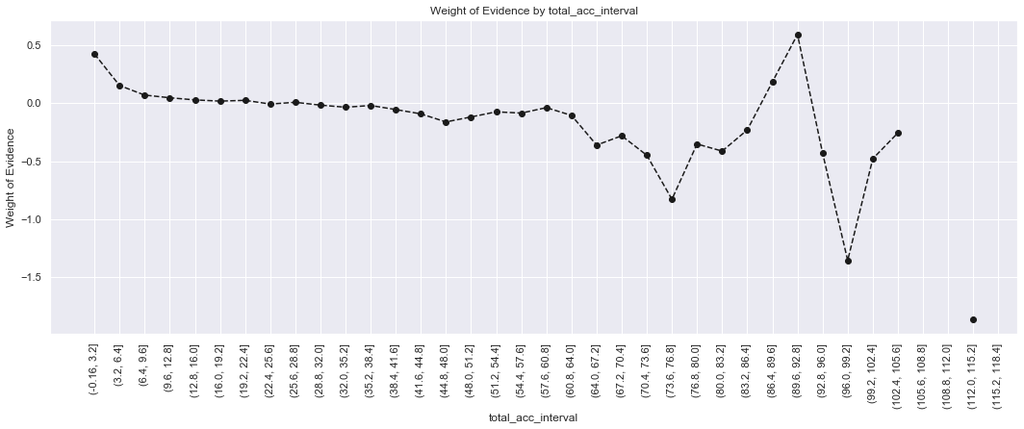

```python
lets_plot(df_totalacc, 90)
```

```python
loan_data_inputs_prep['total_acc:<15'] = np.where((loan_data_inputs_prep['total_acc'] <= 15), 1, 0)
loan_data_inputs_prep['total_acc:15-20'] = np.where((loan_data_inputs_prep['total_acc'] > 15) & (loan_data_inputs_prep['total_acc'] <= 20), 1, 0)
loan_data_inputs_prep['total_acc:20-30'] = np.where((loan_data_inputs_prep['total_acc'] > 20) & (loan_data_inputs_prep['total_acc'] <= 30), 1, 0)
loan_data_inputs_prep['total_acc:30-40'] = np.where((loan_data_inputs_prep['total_acc'] > 30) & (loan_data_inputs_prep['total_acc'] <= 40), 1, 0)
loan_data_inputs_prep['total_acc:>40'] = np.where((loan_data_inputs_prep['total_acc'] >= 40), 1, 0)
```

### Data Preprocessing / Continuous / Too_many_categories / acc_delinq

```python
df_accdelinq = calculate_woe_continuous(loan_data_inputs_prep, 'acc_now_delinq', loan_data_target_prep)
df_accdelinq
```

|  | acc_now_delinq | n_obs | %good_per_category | %bad_per_category | prop_obs | n_good | n_bad | %good | %bad | woe | diff_prop_good | diff_woe | IV |
| --- | --- | --- | --- | --- | --- | --- | --- | --- | --- | --- | --- | --- | --- |
| 0 | 0.0 | 208763 | 0.866150 | 0.133850 | 0.995461 | 180820.0 | 27943.0 | 0.995677 | 0.994059 | 0.001627 | NaN | NaN | inf |
| 1 | 1.0 | 903 | 0.825028 | 0.174972 | 0.004306 | 745.0 | 158.0 | 0.004102 | 0.005621 | -0.314919 | 0.991575 | 0.316546 | inf |
| 2 | 2.0 | 42 | 0.809524 | 0.190476 | 0.000200 | 34.0 | 8.0 | 0.000187 | 0.000285 | -0.418790 | 0.003915 | 0.103870 | inf |
| 3 | 3.0 | 5 | 1.000000 | 0.000000 | 0.000024 | 5.0 | 0.0 | 0.000028 | 0.000000 | inf | 0.000160 | inf | inf |
| 4 | 4.0 | 2 | 0.500000 | 0.500000 | 0.000010 | 1.0 | 1.0 | 0.000006 | 0.000036 | -1.865709 | 0.000022 | inf | inf |

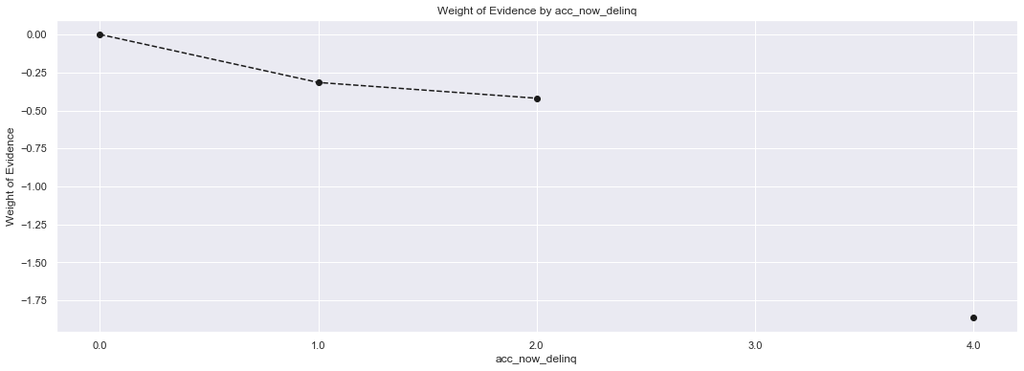

```python
# forming two category as 99% is concentrated at the first category.
lets_plot(df_accdelinq)
```

```python
loan_data_inputs_prep['acc_now_delinq:0.0'] = np.where((loan_data_inputs_prep['acc_now_delinq'] == 0.0), 1, 0)
loan_data_inputs_prep['acc_now_delinq:>0'] = np.where((loan_data_inputs_prep['acc_now_delinq'] > 0.0), 1, 0)
```

### Data Preprocessing / Continuous / Too_many_categories / annual_inc

```python
df_annual = loan_data_inputs_prep.loc[loan_data_inputs_prep['annual_inc'] <= 500000, :]
```

```python
loan_data_inputs_prep['annual_inc_interval'] = pd.cut(df_annual['annual_inc'], 50)
```

```python
df_annualinc = calculate_woe_continuous(loan_data_inputs_prep, 'annual_inc_interval', loan_data_target_prep)
df_annualinc
```

|  | annual_inc_interval | n_obs | %good_per_category | %bad_per_category | prop_obs | n_good | n_bad | %good | %bad | woe | diff_prop_good | diff_woe | IV |
| --- | --- | --- | --- | --- | --- | --- | --- | --- | --- | --- | --- | --- | --- |
| 0 | (-500.0, 10000.0] | 585 | 0.876923 | 0.123077 | 0.002794 | 513.0 | 72.0 | 0.002829 | 0.002564 | 0.098632 | NaN | NaN | inf |
| 1 | (10000.0, 20000.0] | 3471 | 0.845866 | 0.154134 | 0.016576 | 2936.0 | 535.0 | 0.016193 | 0.019049 | -0.162442 | 0.013364 | 0.261073 | inf |
| 2 | (20000.0, 30000.0] | 11954 | 0.837879 | 0.162121 | 0.057088 | 10016.0 | 1938.0 | 0.055242 | 0.069005 | -0.222451 | 0.039049 | 0.060009 | inf |
| 3 | (30000.0, 40000.0] | 22053 | 0.843241 | 0.156759 | 0.105317 | 18596.0 | 3457.0 | 0.102564 | 0.123091 | -0.182433 | 0.047322 | 0.040018 | inf |
| 4 | (40000.0, 50000.0] | 27964 | 0.848627 | 0.151373 | 0.133546 | 23731.0 | 4233.0 | 0.130886 | 0.150721 | -0.141107 | 0.028322 | 0.041326 | inf |
| 5 | (50000.0, 60000.0] | 27869 | 0.857620 | 0.142380 | 0.133092 | 23901.0 | 3968.0 | 0.131823 | 0.141285 | -0.069320 | 0.000938 | 0.071787 | inf |
| 6 | (60000.0, 70000.0] | 23422 | 0.861284 | 0.138716 | 0.111855 | 20173.0 | 3249.0 | 0.111262 | 0.115685 | -0.038980 | 0.020561 | 0.030340 | inf |
| 7 | (70000.0, 80000.0] | 21199 | 0.864522 | 0.135478 | 0.101239 | 18327.0 | 2872.0 | 0.101080 | 0.102261 | -0.011611 | 0.010181 | 0.027369 | inf |
| 8 | (80000.0, 90000.0] | 15678 | 0.875622 | 0.124378 | 0.074872 | 13728.0 | 1950.0 | 0.075715 | 0.069432 | 0.086630 | 0.025365 | 0.098241 | inf |
| 9 | (90000.0, 100000.0] | 13388 | 0.881386 | 0.118614 | 0.063936 | 11800.0 | 1588.0 | 0.065082 | 0.056543 | 0.140646 | 0.010634 | 0.054016 | inf |
| 10 | (100000.0, 110000.0] | 8746 | 0.885205 | 0.114795 | 0.041768 | 7742.0 | 1004.0 | 0.042700 | 0.035749 | 0.177690 | 0.022381 | 0.037044 | inf |
| 11 | (110000.0, 120000.0] | 7443 | 0.891710 | 0.108290 | 0.035545 | 6637.0 | 806.0 | 0.036606 | 0.028699 | 0.243353 | 0.006095 | 0.065664 | inf |
| 12 | (120000.0, 130000.0] | 5440 | 0.896507 | 0.103493 | 0.025979 | 4877.0 | 563.0 | 0.026899 | 0.020046 | 0.294028 | 0.009707 | 0.050674 | inf |
| 13 | (130000.0, 140000.0] | 3693 | 0.909829 | 0.090171 | 0.017636 | 3360.0 | 333.0 | 0.018532 | 0.011857 | 0.446576 | 0.008367 | 0.152548 | inf |
| 14 | (140000.0, 150000.0] | 3965 | 0.896847 | 0.103153 | 0.018935 | 3556.0 | 409.0 | 0.019613 | 0.014563 | 0.297698 | 0.001081 | 0.148877 | inf |
| 15 | (150000.0, 160000.0] | 2093 | 0.915910 | 0.084090 | 0.009995 | 1917.0 | 176.0 | 0.010573 | 0.006267 | 0.523055 | 0.009040 | 0.225356 | inf |
| 16 | (160000.0, 170000.0] | 1567 | 0.902999 | 0.097001 | 0.007483 | 1415.0 | 152.0 | 0.007804 | 0.005412 | 0.366026 | 0.002769 | 0.157028 | inf |
| 17 | (170000.0, 180000.0] | 1724 | 0.903132 | 0.096868 | 0.008233 | 1557.0 | 167.0 | 0.008587 | 0.005946 | 0.367544 | 0.000783 | 0.001518 | inf |
| 18 | (180000.0, 190000.0] | 996 | 0.904618 | 0.095382 | 0.004757 | 901.0 | 95.0 | 0.004969 | 0.003383 | 0.384650 | 0.003618 | 0.017106 | inf |
| 19 | (190000.0, 200000.0] | 1384 | 0.904624 | 0.095376 | 0.006609 | 1252.0 | 132.0 | 0.006905 | 0.004700 | 0.384717 | 0.001936 | 0.000067 | inf |
| 20 | (200000.0, 210000.0] | 545 | 0.915596 | 0.084404 | 0.002603 | 499.0 | 46.0 | 0.002752 | 0.001638 | 0.518987 | 0.004153 | 0.134269 | inf |
| 21 | (210000.0, 220000.0] | 497 | 0.905433 | 0.094567 | 0.002373 | 450.0 | 47.0 | 0.002482 | 0.001673 | 0.394122 | 0.000270 | 0.124865 | inf |
| 22 | (220000.0, 230000.0] | 515 | 0.906796 | 0.093204 | 0.002459 | 467.0 | 48.0 | 0.002576 | 0.001709 | 0.410150 | 0.000094 | 0.016028 | inf |
| 23 | (230000.0, 240000.0] | 337 | 0.896142 | 0.103858 | 0.001609 | 302.0 | 35.0 | 0.001666 | 0.001246 | 0.290101 | 0.000910 | 0.120049 | inf |
| 24 | (240000.0, 250000.0] | 703 | 0.911807 | 0.088193 | 0.003357 | 641.0 | 62.0 | 0.003535 | 0.002208 | 0.470917 | 0.001870 | 0.180816 | inf |
| 25 | (250000.0, 260000.0] | 204 | 0.926471 | 0.073529 | 0.000974 | 189.0 | 15.0 | 0.001042 | 0.000534 | 0.668719 | 0.002493 | 0.197802 | inf |
| 26 | (260000.0, 270000.0] | 142 | 0.936620 | 0.063380 | 0.000678 | 133.0 | 9.0 | 0.000734 | 0.000320 | 0.828146 | 0.000309 | 0.159428 | inf |
| 27 | (270000.0, 280000.0] | 244 | 0.922131 | 0.077869 | 0.001165 | 225.0 | 19.0 | 0.001241 | 0.000677 | 0.606683 | 0.000507 | 0.221463 | inf |
| 28 | (280000.0, 290000.0] | 105 | 0.942857 | 0.057143 | 0.000501 | 99.0 | 6.0 | 0.000546 | 0.000214 | 0.938382 | 0.000695 | 0.331699 | inf |
| 29 | (290000.0, 300000.0] | 383 | 0.924282 | 0.075718 | 0.001829 | 354.0 | 29.0 | 0.001952 | 0.001033 | 0.637023 | 0.001406 | 0.301359 | inf |
| 30 | (300000.0, 310000.0] | 68 | 0.911765 | 0.088235 | 0.000325 | 62.0 | 6.0 | 0.000342 | 0.000214 | 0.470397 | 0.001610 | 0.166626 | inf |
| 31 | (310000.0, 320000.0] | 89 | 0.955056 | 0.044944 | 0.000425 | 85.0 | 4.0 | 0.000469 | 0.000142 | 1.191379 | 0.000127 | 0.720982 | inf |
| 32 | (320000.0, 330000.0] | 119 | 0.941176 | 0.058824 | 0.000568 | 112.0 | 7.0 | 0.000618 | 0.000249 | 0.907611 | 0.000149 | 0.283768 | inf |
| 33 | (330000.0, 340000.0] | 38 | 0.973684 | 0.026316 | 0.000181 | 37.0 | 1.0 | 0.000204 | 0.000036 | 1.745940 | 0.000414 | 0.838329 | inf |
| 34 | (340000.0, 350000.0] | 190 | 0.936842 | 0.063158 | 0.000907 | 178.0 | 12.0 | 0.000982 | 0.000427 | 0.831899 | 0.000778 | 0.914041 | inf |
| 35 | (350000.0, 360000.0] | 41 | 0.926829 | 0.073171 | 0.000196 | 38.0 | 3.0 | 0.000210 | 0.000107 | 0.673996 | 0.000772 | 0.157903 | inf |
| 36 | (360000.0, 370000.0] | 21 | 0.904762 | 0.095238 | 0.000100 | 19.0 | 2.0 | 0.000105 | 0.000071 | 0.386314 | 0.000105 | 0.287682 | inf |
| 37 | (370000.0, 380000.0] | 52 | 0.923077 | 0.076923 | 0.000248 | 48.0 | 4.0 | 0.000265 | 0.000142 | 0.619928 | 0.000160 | 0.233615 | inf |
| 38 | (380000.0, 390000.0] | 20 | 0.950000 | 0.050000 | 0.000096 | 19.0 | 1.0 | 0.000105 | 0.000036 | 1.079461 | 0.000160 | 0.459532 | inf |
| 39 | (390000.0, 400000.0] | 132 | 0.939394 | 0.060606 | 0.000630 | 124.0 | 8.0 | 0.000684 | 0.000285 | 0.875862 | 0.000579 | 0.203599 | inf |
| 40 | (400000.0, 410000.0] | 17 | 0.882353 | 0.117647 | 0.000081 | 15.0 | 2.0 | 0.000083 | 0.000071 | 0.149925 | 0.000601 | 0.725937 | inf |
| 41 | (410000.0, 420000.0] | 33 | 0.939394 | 0.060606 | 0.000158 | 31.0 | 2.0 | 0.000171 | 0.000071 | 0.875862 | 0.000088 | 0.725937 | inf |
| 42 | (420000.0, 430000.0] | 35 | 0.914286 | 0.085714 | 0.000167 | 32.0 | 3.0 | 0.000176 | 0.000107 | 0.502145 | 0.000006 | 0.373716 | inf |
| 43 | (430000.0, 440000.0] | 20 | 0.800000 | 0.200000 | 0.000096 | 16.0 | 4.0 | 0.000088 | 0.000142 | -0.478684 | 0.000088 | 0.980829 | inf |
| 44 | (440000.0, 450000.0] | 77 | 0.948052 | 0.051948 | 0.000368 | 73.0 | 4.0 | 0.000403 | 0.000142 | 1.039187 | 0.000314 | 1.517871 | inf |
| 45 | (450000.0, 460000.0] | 15 | 0.933333 | 0.066667 | 0.000072 | 14.0 | 1.0 | 0.000077 | 0.000036 | 0.774079 | 0.000325 | 0.265108 | inf |
| 46 | (460000.0, 470000.0] | 9 | 1.000000 | 0.000000 | 0.000043 | 9.0 | 0.0 | 0.000050 | 0.000000 | inf | 0.000028 | inf | inf |
| 47 | (470000.0, 480000.0] | 29 | 0.931034 | 0.068966 | 0.000138 | 27.0 | 2.0 | 0.000149 | 0.000071 | 0.737712 | 0.000099 | inf | inf |
| 48 | (480000.0, 490000.0] | 11 | 1.000000 | 0.000000 | 0.000053 | 11.0 | 0.0 | 0.000061 | 0.000000 | inf | 0.000088 | inf | inf |
| 49 | (490000.0, 500000.0] | 71 | 0.943662 | 0.056338 | 0.000339 | 67.0 | 4.0 | 0.000370 | 0.000142 | 0.953420 | 0.000309 | inf | inf |

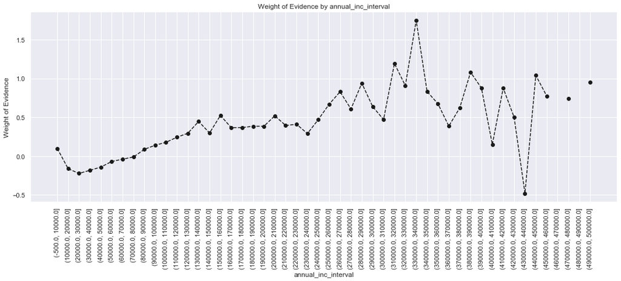

```python
lets_plot(df_annualinc, 90)
```

```python
loan_data_inputs_prep['annualincome:0-20000']       = np.where((loan_data_inputs_prep['annual_inc'] <= 20000), 1, 0)
loan_data_inputs_prep['annualincome:20000-30000']   = np.where((loan_data_inputs_prep['annual_inc'] > 20000) & (loan_data_inputs_prep['annual_inc'] <= 40000), 1, 0)
loan_data_inputs_prep['annualincome:40000-50000']   = np.where((loan_data_inputs_prep['annual_inc'] > 40000) & (loan_data_inputs_prep['annual_inc'] <= 50000), 1, 0)
loan_data_inputs_prep['annualincome:50000-60000']   = np.where((loan_data_inputs_prep['annual_inc'] > 50000) & (loan_data_inputs_prep['annual_inc'] <= 60000), 1, 0)
loan_data_inputs_prep['annualincome:60000-80000']   = np.where((loan_data_inputs_prep['annual_inc'] > 60000) & (loan_data_inputs_prep['annual_inc'] <= 80000), 1, 0)
loan_data_inputs_prep['annualincome:80000-100000']  = np.where((loan_data_inputs_prep['annual_inc'] > 80000) & (loan_data_inputs_prep['annual_inc'] <= 100000), 1, 0)
loan_data_inputs_prep['annualincome:100000-150000'] = np.where((loan_data_inputs_prep['annual_inc'] > 100000) & (loan_data_inputs_prep['annual_inc'] <= 150000), 1, 0)
loan_data_inputs_prep['annualincome:150000-500000'] = np.where((loan_data_inputs_prep['annual_inc'] > 150000) & (loan_data_inputs_prep['annual_inc'] <= 500000), 1, 0)
loan_data_inputs_prep['annualincome:>500000']       = np.where((loan_data_inputs_prep['annual_inc'] > 500000), 1, 0)
```

### Data Preprocessing / Continuous / Too_many_categories / mths_since_last_delinq

```python
# creating df_delinq temporarily just to escape the missing values.
df_delinq = loan_data_inputs_prep[pd.notnull(loan_data_inputs_prep['mths_since_last_delinq'])]
df_delinq['months_last_delinq_interval'] = pd.cut(df_delinq['mths_since_last_delinq'], 50)
df_delinq_woe = calculate_woe_continuous(df_delinq, 'months_last_delinq_interval', loan_data_target_prep[df_delinq.index])
df_delinq_woe
```

|  | months_last_delinq_interval | n_obs | %good_per_category | %bad_per_category | prop_obs | n_good | n_bad | %good | %bad | woe | diff_prop_good | diff_woe | IV |
| --- | --- | --- | --- | --- | --- | --- | --- | --- | --- | --- | --- | --- | --- |
| 0 | (-0.226, 4.52] | 4738 | 0.843183 | 0.156817 | 0.045553 | 3995.0 | 743.0 | 0.044791 | 0.050138 | -0.112778 | NaN | NaN | inf |
| 1 | (4.52, 9.04] | 9650 | 0.846943 | 0.153057 | 0.092779 | 8173.0 | 1477.0 | 0.091634 | 0.099669 | -0.084058 | 0.046843 | 0.028720 | inf |
| 2 | (9.04, 13.56] | 7488 | 0.856571 | 0.143429 | 0.071992 | 6414.0 | 1074.0 | 0.071912 | 0.072475 | -0.007788 | 0.019721 | 0.076270 | inf |
| 3 | (13.56, 18.08] | 9185 | 0.848993 | 0.151007 | 0.088308 | 7798.0 | 1387.0 | 0.087429 | 0.093596 | -0.068157 | 0.015517 | 0.060369 | inf |
| 4 | (18.08, 22.6] | 6816 | 0.862823 | 0.137177 | 0.065532 | 5881.0 | 935.0 | 0.065936 | 0.063095 | 0.044054 | 0.021493 | 0.112211 | inf |
| 5 | (22.6, 27.12] | 8293 | 0.859399 | 0.140601 | 0.079732 | 7127.0 | 1166.0 | 0.079906 | 0.078683 | 0.015430 | 0.013970 | 0.028624 | inf |
| 6 | (27.12, 31.64] | 6540 | 0.860856 | 0.139144 | 0.062878 | 5630.0 | 910.0 | 0.063122 | 0.061408 | 0.027539 | 0.016784 | 0.012109 | inf |
| 7 | (31.64, 36.16] | 7337 | 0.857980 | 0.142020 | 0.070541 | 6295.0 | 1042.0 | 0.070578 | 0.070315 | 0.003733 | 0.007456 | 0.023806 | inf |
| 8 | (36.16, 40.68] | 5719 | 0.857318 | 0.142682 | 0.054985 | 4903.0 | 816.0 | 0.054971 | 0.055064 | -0.001693 | 0.015607 | 0.005426 | inf |
| 9 | (40.68, 45.2] | 6839 | 0.867086 | 0.132914 | 0.065753 | 5930.0 | 909.0 | 0.066486 | 0.061340 | 0.080553 | 0.011514 | 0.082246 | inf |
| 10 | (45.2, 49.72] | 4789 | 0.868449 | 0.131551 | 0.046043 | 4159.0 | 630.0 | 0.046630 | 0.042513 | 0.092429 | 0.019856 | 0.011876 | inf |
| 11 | (49.72, 54.24] | 4502 | 0.852288 | 0.147712 | 0.043284 | 3837.0 | 665.0 | 0.043020 | 0.044875 | -0.042222 | 0.003610 | 0.134651 | inf |
| 12 | (54.24, 58.76] | 3484 | 0.859070 | 0.140930 | 0.033496 | 2993.0 | 491.0 | 0.033557 | 0.033133 | 0.012706 | 0.009463 | 0.054928 | inf |
| 13 | (58.76, 63.28] | 4492 | 0.857079 | 0.142921 | 0.043188 | 3850.0 | 642.0 | 0.043165 | 0.043323 | -0.003641 | 0.009608 | 0.016347 | inf |
| 14 | (63.28, 67.8] | 3554 | 0.861564 | 0.138436 | 0.034169 | 3062.0 | 492.0 | 0.034330 | 0.033201 | 0.033464 | 0.008835 | 0.037105 | inf |
| 15 | (67.8, 72.32] | 4008 | 0.863273 | 0.136727 | 0.038534 | 3460.0 | 548.0 | 0.038793 | 0.036980 | 0.047867 | 0.004462 | 0.014404 | inf |
| 16 | (72.32, 76.84] | 3016 | 0.864390 | 0.135610 | 0.028997 | 2607.0 | 409.0 | 0.029229 | 0.027600 | 0.057359 | 0.009564 | 0.009492 | inf |
| 17 | (76.84, 81.36] | 3016 | 0.862401 | 0.137599 | 0.028997 | 2601.0 | 415.0 | 0.029162 | 0.028005 | 0.040492 | 0.000067 | 0.016868 | inf |
| 18 | (81.36, 85.88] | 290 | 0.862069 | 0.137931 | 0.002788 | 250.0 | 40.0 | 0.002803 | 0.002699 | 0.037700 | 0.026359 | 0.002791 | inf |
| 19 | (85.88, 90.4] | 58 | 0.810345 | 0.189655 | 0.000558 | 47.0 | 11.0 | 0.000527 | 0.000742 | -0.342629 | 0.002276 | 0.380329 | inf |
| 20 | (90.4, 94.92] | 47 | 0.978723 | 0.021277 | 0.000452 | 46.0 | 1.0 | 0.000516 | 0.000067 | 2.033760 | 0.000011 | 2.376389 | inf |
| 21 | (94.92, 99.44] | 35 | 0.971429 | 0.028571 | 0.000337 | 34.0 | 1.0 | 0.000381 | 0.000067 | 1.731479 | 0.000135 | 0.302281 | inf |
| 22 | (99.44, 103.96] | 35 | 0.857143 | 0.142857 | 0.000337 | 30.0 | 5.0 | 0.000336 | 0.000337 | -0.003122 | 0.000045 | 1.734601 | inf |
| 23 | (103.96, 108.48] | 22 | 0.909091 | 0.090909 | 0.000212 | 20.0 | 2.0 | 0.000224 | 0.000135 | 0.507704 | 0.000112 | 0.510826 | inf |
| 24 | (108.48, 113.0] | 14 | 0.785714 | 0.214286 | 0.000135 | 11.0 | 3.0 | 0.000123 | 0.000202 | -0.495598 | 0.000101 | 1.003302 | inf |
| 25 | (113.0, 117.52] | 12 | 1.000000 | 0.000000 | 0.000115 | 12.0 | 0.0 | 0.000135 | 0.000000 | inf | 0.000011 | inf | inf |
| 26 | (117.52, 122.04] | 7 | 0.857143 | 0.142857 | 0.000067 | 6.0 | 1.0 | 0.000067 | 0.000067 | -0.003122 | 0.000067 | inf | inf |
| 27 | (122.04, 126.56] | 6 | 0.833333 | 0.166667 | 0.000058 | 5.0 | 1.0 | 0.000056 | 0.000067 | -0.185443 | 0.000011 | 0.182322 | inf |
| 28 | (126.56, 131.08] | 6 | 1.000000 | 0.000000 | 0.000058 | 6.0 | 0.0 | 0.000067 | 0.000000 | inf | 0.000011 | inf | inf |
| 29 | (131.08, 135.6] | 3 | 0.666667 | 0.333333 | 0.000029 | 2.0 | 1.0 | 0.000022 | 0.000067 | -1.101734 | 0.000045 | inf | inf |
| 30 | (135.6, 140.12] | 0 | NaN | NaN | 0.000000 | NaN | NaN | NaN | NaN | NaN | NaN | NaN | inf |
| 31 | (140.12, 144.64] | 0 | NaN | NaN | 0.000000 | NaN | NaN | NaN | NaN | NaN | NaN | NaN | inf |
| 32 | (144.64, 149.16] | 4 | 1.000000 | 0.000000 | 0.000038 | 4.0 | 0.0 | 0.000045 | 0.000000 | inf | NaN | NaN | inf |
| 33 | (149.16, 153.68] | 1 | 1.000000 | 0.000000 | 0.000010 | 1.0 | 0.0 | 0.000011 | 0.000000 | inf | 0.000034 | NaN | inf |
| 34 | (153.68, 158.2] | 1 | 1.000000 | 0.000000 | 0.000010 | 1.0 | 0.0 | 0.000011 | 0.000000 | inf | 0.000000 | NaN | inf |
| 35 | (158.2, 162.72] | 1 | 1.000000 | 0.000000 | 0.000010 | 1.0 | 0.0 | 0.000011 | 0.000000 | inf | 0.000000 | NaN | inf |
| 36 | (162.72, 167.24] | 0 | NaN | NaN | 0.000000 | NaN | NaN | NaN | NaN | NaN | NaN | NaN | inf |
| 37 | (167.24, 171.76] | 1 | 0.000000 | 1.000000 | 0.000010 | 0.0 | 1.0 | 0.000000 | 0.000067 | -inf | NaN | NaN | inf |
| 38 | (171.76, 176.28] | 0 | NaN | NaN | 0.000000 | NaN | NaN | NaN | NaN | NaN | NaN | NaN | inf |
| 39 | (176.28, 180.8] | 1 | 1.000000 | 0.000000 | 0.000010 | 1.0 | 0.0 | 0.000011 | 0.000000 | inf | NaN | NaN | inf |
| 40 | (180.8, 185.32] | 0 | NaN | NaN | 0.000000 | NaN | NaN | NaN | NaN | NaN | NaN | NaN | inf |
| 41 | (185.32, 189.84] | 0 | NaN | NaN | 0.000000 | NaN | NaN | NaN | NaN | NaN | NaN | NaN | inf |
| 42 | (189.84, 194.36] | 0 | NaN | NaN | 0.000000 | NaN | NaN | NaN | NaN | NaN | NaN | NaN | inf |
| 43 | (194.36, 198.88] | 0 | NaN | NaN | 0.000000 | NaN | NaN | NaN | NaN | NaN | NaN | NaN | inf |
| 44 | (198.88, 203.4] | 0 | NaN | NaN | 0.000000 | NaN | NaN | NaN | NaN | NaN | NaN | NaN | inf |
| 45 | (203.4, 207.92] | 0 | NaN | NaN | 0.000000 | NaN | NaN | NaN | NaN | NaN | NaN | NaN | inf |
| 46 | (207.92, 212.44] | 0 | NaN | NaN | 0.000000 | NaN | NaN | NaN | NaN | NaN | NaN | NaN | inf |
| 47 | (212.44, 216.96] | 0 | NaN | NaN | 0.000000 | NaN | NaN | NaN | NaN | NaN | NaN | NaN | inf |
| 48 | (216.96, 221.48] | 0 | NaN | NaN | 0.000000 | NaN | NaN | NaN | NaN | NaN | NaN | NaN | inf |
| 49 | (221.48, 226.0] | 1 | 0.000000 | 1.000000 | 0.000010 | 0.0 | 1.0 | 0.000000 | 0.000067 | -inf | NaN | NaN | inf |

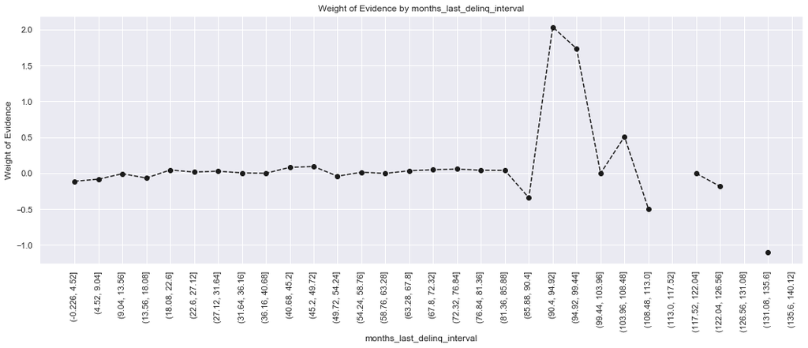

```python
lets_plot(df_delinq_woe, 90)
```

```python
loan_data_inputs_prep['months_since_delinq:<20']   = np.where((loan_data_inputs_prep['mths_since_last_delinq'] <= 20), 1, 0)
loan_data_inputs_prep['months_since_delinq:20-32'] = np.where((loan_data_inputs_prep['mths_since_last_delinq'] > 20) & (loan_data_inputs_prep['mths_since_last_delinq'] < 32), 1, 0)
loan_data_inputs_prep['months_since_delinq:32-70'] = np.where((loan_data_inputs_prep['mths_since_last_delinq'] > 32) & (loan_data_inputs_prep['mths_since_last_delinq'] < 70), 1, 0)
loan_data_inputs_prep['months_since_delinq:>70']   = np.where((loan_data_inputs_prep['mths_since_last_delinq'] > 70), 1, 0)
```

### Data Preprocessing / Continuous / Too_many_categories / dti

```python
loan_data_inputs_prep['dti_interval'] = pd.cut(loan_data_inputs_prep['dti'], 100)
df_dti = calculate_woe_continuous(loan_data_inputs_prep, 'dti_interval', loan_data_target_prep)
df_dti
```

|  | dti_interval | n_obs | %good_per_category | %bad_per_category | prop_obs | n_good | n_bad | %good | %bad | woe | diff_prop_good | diff_woe | IV |
| --- | --- | --- | --- | --- | --- | --- | --- | --- | --- | --- | --- | --- | --- |
| 0 | (-0.999, 9.99] | 35763 | 0.897967 | 0.102033 | 0.170687 | 32114.0 | 3649.0 | 0.177008 | 0.129872 | 0.309648 | NaN | NaN | inf |
| 1 | (9.99, 19.98] | 83622 | 0.880869 | 0.119131 | 0.399105 | 73660.0 | 9962.0 | 0.406004 | 0.354557 | 0.135491 | 0.228996 | 0.174157 | inf |
| 2 | (19.98, 29.97] | 63830 | 0.849663 | 0.150337 | 0.304643 | 54234.0 | 9596.0 | 0.298930 | 0.341531 | -0.133229 | 0.107073 | 0.268720 | inf |
| 3 | (29.97, 39.96] | 23512 | 0.804738 | 0.195262 | 0.112216 | 18921.0 | 4591.0 | 0.104290 | 0.163398 | -0.449016 | 0.194640 | 0.315787 | inf |
| 4 | (39.96, 49.95] | 1467 | 0.873892 | 0.126108 | 0.007002 | 1282.0 | 185.0 | 0.007066 | 0.006584 | 0.070630 | 0.097224 | 0.519646 | inf |
| ... | ... | ... | ... | ... | ... | ... | ... | ... | ... | ... | ... | ... | ... |
| 95 | (949.05, 959.04] | 0 | NaN | NaN | 0.000000 | NaN | NaN | NaN | NaN | NaN | NaN | NaN | inf |
| 96 | (959.04, 969.03] | 0 | NaN | NaN | 0.000000 | NaN | NaN | NaN | NaN | NaN | NaN | NaN | inf |
| 97 | (969.03, 979.02] | 0 | NaN | NaN | 0.000000 | NaN | NaN | NaN | NaN | NaN | NaN | NaN | inf |
| 98 | (979.02, 989.01] | 0 | NaN | NaN | 0.000000 | NaN | NaN | NaN | NaN | NaN | NaN | NaN | inf |
| 99 | (989.01, 999.0] | 15 | 1.000000 | 0.000000 | 0.000072 | 15.0 | 0.0 | 0.000083 | 0.000000 | inf | NaN | NaN | inf |

100 rows × 13 columns

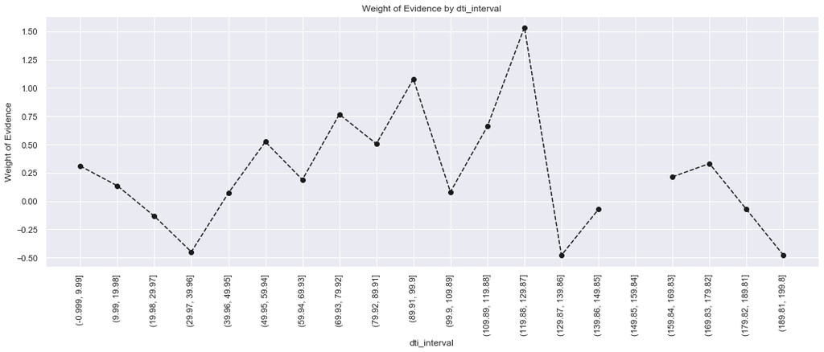

```python
lets_plot(df_dti.iloc[:50, :], 90)
```

```python
loan_data_inputs_prep['dti:0-5']   = np.where((loan_data_inputs_prep['dti'] < 5), 1, 0)
loan_data_inputs_prep['dti:5-10']  = np.where((loan_data_inputs_prep['dti'] > 5) & (loan_data_inputs_prep['dti'] <= 10), 1, 0)
loan_data_inputs_prep['dti:10-15'] = np.where((loan_data_inputs_prep['dti'] > 10) & (loan_data_inputs_prep['dti'] <= 15), 1, 0)
loan_data_inputs_prep['dti:15-20'] = np.where((loan_data_inputs_prep['dti'] > 15) & (loan_data_inputs_prep['dti'] <= 20), 1, 0)
loan_data_inputs_prep['dti:20-25'] = np.where((loan_data_inputs_prep['dti'] > 20) & (loan_data_inputs_prep['dti'] <= 25), 1, 0)
loan_data_inputs_prep['dti:25-30'] = np.where((loan_data_inputs_prep['dti'] > 25) & (loan_data_inputs_prep['dti'] <= 30), 1, 0)
loan_data_inputs_prep['dti:30-40'] = np.where((loan_data_inputs_prep['dti'] > 30) & (loan_data_inputs_prep['dti'] <= 40), 1, 0)
loan_data_inputs_prep['dti:>40']   = np.where((loan_data_inputs_prep['dti'] > 40), 1, 0)
```

### Data Preprocessing / Continuous / Too_many_categories / mths_since_last_record

> One thing we can notice here is that we have huge number of missing values, so how to deal with them??

> Use `pd.notnull()` method to filter the non missing values and then do the rest.

> By looking at the chart, we can see that there is a randomness in the woe and hence we will discard it.

```python
df_record_temp = loan_data_inputs_prep[pd.notnull(loan_data_inputs_prep['mths_since_last_record'])]
df_record = calculate_woe_continuous(df_record_temp, 'mths_since_last_record', loan_data_target_prep)
```

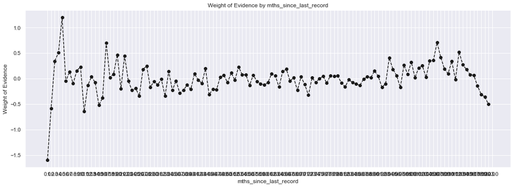

```python
lets_plot(df_record)
```

```python
loan_data_inputs_train = loan_data_inputs_prep
# loan_data_inputs_test = loan_data_inputs_prep
```

```python
# loan_data_inputs_train.to_csv('loan_data_inputs_train.csv')
# loan_data_target_train.to_csv('loan_data_target_train.csv')

loan_data_inputs_test.to_csv('loan_data_inputs_test.csv')
loan_data_target_test.to_csv('loan_data_target_test.csv')
```